# Technical Report: Full House Model in R

Shen Yan, Adrian Burgos Jr., Christopher Kinson, Brandon Niedert, and Daniel J. Eck

01/31/2022

# Introduction

We will go through an example of how our Full House Model era-adjusts batting averages (BA) using the parametric method, and bWAR(Baseball-Reference Win Above Replacement), fWAR(Fangraphs Win Above Replacement), HR(Home Run), BB(Walks) for batters, bWAR, fWAR, ERA(Earned Run Average), SO(Strikeout) for pitchers using the nonparametric method. We first load in relevant software packages and the data. Each row of data consists of a player ID.

The necessary data are collected from [Baseball-Reference](https://www.baseball-reference.com/), [Fangraphs](https://www.fangraphs.com/) and Github [Chadwick](https://github.com/chadwickbureau). The details of data collection are in the Supplement Materials.

[Baseball-Reference](https://www.baseball-reference.com/), a year ID, a park-factored BA, a era-adjusted at bats(adj_AB), a recorded number of at bats (AB), game(G), plate appearances (PA), and baseball-reference WAR(bWAR) and a value pops (the size of the MLB-eligible population in year i). The era-adjusted at bats(adj_AB) is computed based on the formula in the paper and the other variables are irrelevant for this analysis.

```r
rm(list=ls())
library(tidyverse)
library(orderstats)
library(Pareto)
library(parallel)
library(doParallel)
library(xtable)
years <- 1871:2021
ncores <- detectCores() - 1

## batters_AB.csv is part of the batters_all.csv and
## contains the adjusted-AB that from
## adjusted-AB = mapped-PA - adjusted-BB - HBP - SH - SF

batters <- read_csv("batters_AB.csv")[,-1]
```

In this analysis we will assume that batting averages (BA) $\stackrel{i i d}{\sim} N\left(\mu_{i}, \sigma_{i}\right)$ and that aptitude $\sim \operatorname{Pareto}(\alpha)$ where $\alpha=1.16$. We do not have any assumptions on the distribution of bWAR. This choice of alpha corresponds to the Pareto principle which is casually referred to as the $80 / 20$ rule.

# Parametric distribution measuring components

## BA

In this section, our Full House Model era-adjusts batting averages (BA) using the parametric distribution measuring the BA. We first declare a threshold for a batter to be considered a full-time batter. We choose the median PAs after screening out individuals who batted fewer than 75 PAs as our cutoff for full-time batters.

```r
cutoff <- do.call(rbind, mclapply(years, mc.cores = ncores, FUN = function(xx){
  m <- batters %>% filter(yearID == xx) %>% filter(PA >= 75)
  data.frame(thres = median(m$PA), yearID = xx)
}))
batters <- merge(batters, cutoff, by = 'yearID')
batters <- batters %>% mutate(comp = AVG)
```

The code below introduces the function that transport normally distributed statistics to their talent scores.

```r
talent_computing_para <- function(dataset, year, alpha = 1.16){
  # dataset should include the component name and corresponding npop
  Aptitude_para <- function(y, mean = 0, sd = 1, alpha = 1.16, npop){

    # converts normal order stats to their percentiles
    order_pnorm <- function(q = 0, mean = 0, sd = 1, k = 1, n = 1e4){
      p <- pnorm(q, mean = mean, sd = sd)
      pbinom(k - 1, prob = p, size = n, lower.tail = FALSE)
    }

    # converts a vector of normal order stats
    # to their percentiles. This vector should be the entire
    # sample sorted in increasing order
    q <- sort(y) # just in case
    n <- length(y)
    u = unlist(lapply(1:n, function(j){
      order_pnorm(y[j], k = j, n = n, mean = mean, sd = sd)
    }))

    # transforms percentiles from order stats (in increasing order)
    # to Pareto values corresponding to the general population
    # of a greater than or equal to size
    # default alpha is that of the Pareto principle 80-20
    n <- length(u)
    if(length(npop) == 1) npop <- rep(npop, n)
    unlist(lapply(1:n, function(j){
      qPareto(qbeta(u[j], j + npop[j]-n, n + 1 - j), t = 1, alpha = alpha)
    }))
  }

  # consider the full time batters
  foo <- dataset %>% filter(yearID == year) %>% arrange(comp)
  ## average talent
  bar <- foo %>% filter(PA >= thres)
  nsys <- nrow(bar)
  mu_comp <- mean(bar$comp)
  sd_comp <- sd(bar$comp)
  # components to build the CDF using parametric distribution
  bar <- bar %>% mutate(talent =
                          Aptitude_para(comp, mean = mu_comp, sd = sd_comp, npop = pops))
  max_talent <- max(bar$talent) - 1
  # consider the non-full time batters
  non_full <- foo %>% filter(PA < thres)
  bar <- rbind(bar, do.call(rbind, lapply(1:nrow(non_full), function(j){
    m <- rbind(bar %>% dplyr::select(-talent), non_full[j, ]) %>% arrange(comp)
      m %>% mutate(talent = Aptitude_para(comp, mean = mu_comp, sd = sd_comp, npop = pops)) %>%
      filter(PA < thres) %>%
      mutate(talent = ifelse(talent > max_talent+1, max_talent, talent))
  })))
  bar
}
```

The following script computes the talent scores for BA from all batters and all years(1871 to 2021).

```r
batters_talent_AVG <- do.call(rbind, mclapply(years, mc.cores = ncores, function(yy){
  talent_computing_para(dataset = batters, year = yy)
})) %>% arrange(-talent)
```

From here we obtain the top seasons ever according to era-adjusted batting average. The last column displays the talent scores corresponding to these seasons. These talent scores do not have any tangible meaning beyond this (the first score is not roughly 3 times better than the second score).

```r
## top 25 average talent-scores
top25seasons_AVG <- (batters_talent_AVG %>% filter(PA >= thres) %>% arrange(-talent))[1:25, ]
## top 25 all-time batting seasons by talent-scores
m <- top25seasons_AVG %>% select(name, talent)
rownames(m) <- c()
```

We now take the above talent scores and reverse engineer the process to extract what these players who achieve if these seasons were to take place in 2021. To do this we first introduces the function that transport their talent scores to the context of the 2021 season and estimate the era-adjusted BA in 2021.

```r
Rev_Aptitude_para <- function(x, mean = 0, sd = 1, alpha = 1.16, npop){

  # transforms ordered Pareto values corresponding to
  # the general population to percentiles from order stats
  # (in increasing order)
  n <- length(x)
  if(length(npop) == 1) npop <- rep(npop, n)
  u = unlist(lapply(1:n, function(j){
    pbeta(pPareto(x[j], t = 1, alpha = alpha), j + npop[j]-n, n + 1 - j)
  }))

  # take the ordered percentiles and convert them to order statistics
  # from a normal distribution
  n <- length(u)
  qnorm(qbeta(u, shape1 = 1:n, shape2 = n:1), mean = mean, sd = sd)

}
```

The code below finishes the task and places the above talent scores within the context of the 2021 season and outputs their corresponding 2021 batting averages.

```r
# first estimate normal distribution parameters for the 2021 season
ref_2021 <- batters_talent_AVG %>% filter(yearID == 2021) %>% filter(PA >= thres)
mean_AVG_2021 <- mean(ref_2021$AVG)
sd_AVG_2021 <- sd(ref_2021$AVG)
w_pops_2021 <- unique(ref_2021$pops)

# compute the era-adjusted BA in 2021 for top 25 BA leaders
top25seasons_2021_AVG <- do.call(rbind, mclapply(1:25, mc.cores = ncores, function(j){
  xx <- top25seasons_AVG[j, ]
xx$pops <- w_pops_2021
xx$playerID <- paste(xx$playerID, "_proj", sep = "")
int <- rbind(ref_2021, xx) %>% arrange(talent) %>%
  mutate(adj_AVG = Rev_Aptitude_para(talent, mean = mean_AVG_2021,
                                     sd = sd_AVG_2021, npop = w_pops_2021))
int[grepl("_proj", int$playerID), ]
}))
n <- top25seasons_2021_AVG %>% select(name, talent, adj_AVG)
rownames(n) <- c()
```

We now extend the method to compute hypothetical careers in which we suppose that every player starts their career all at 1977. The reason we select 1977 season is the top 25 ranking list is stable when players start their career at this season.

```r
foo <- batters_talent_AVG
foo$playerID <- droplevels(as.factor(foo$playerID))

# function that computes adjusted career averages over the hypothetical year
career_talent <- function(dataset, snippet, start_year){

  Rev_Aptitude_para <- function(x, mean = 0, sd = 1, alpha = 1.16, npop){

    # transforms ordered Pareto values corresponding to
    # the general population to percentiles from order stats
    # (in increasing order)
    n <- length(x)
    if(length(npop) == 1) npop <- rep(npop, n)
    u = unlist(lapply(1:n, function(j){
      pbeta(pPareto(x[j], t = 1, alpha = alpha), j + npop[j]-n, n + 1 - j)
    }))

    # take the ordered percentiles and convert them to order statistics
    # from a normal distribution
    n <- length(u)
    qnorm(qbeta(u, shape1 = 1:n, shape2 = n:1), mean = mean, sd = sd)

  }

  min_year <- min(snippet$yearID)
  max_year <- max(snippet$yearID)
  end_year <- max_year - min_year + start_year
  end_year <- ifelse(end_year <= 2021, end_year, 2021)

  snippet <- snippet %>% mutate(playerID = paste(playerID, "_proj", sep = ""))
  do.call(rbind, lapply(start_year : end_year, function(xx){
    batters_int <- dataset %>% filter(yearID == xx, PA >= thres)

    min_int <- min(batters_int$comp)
    mean_int <- mean(batters_int$comp)
    sd_int <- sd(batters_int$comp)

    target_snippet <- snippet %>% filter(yearID == (xx - start_year + min_year))

    batters_int <- rbind(batters_int, target_snippet)
    batters_int$pops[nrow(batters_int)] <- batters_int$pops[1]
    batters_int <- batters_int %>% arrange(talent) %>%
      mutate(adj_AVG = Rev_Aptitude_para(talent, mean = mean_int, sd = sd_int, npop = pops)) %>%
      filter(playerID == unique(snippet$playerID))
    batters_int$adj_AVG <- ifelse(batters_int$adj_AVG < min_int, min_int, batters_int$adj_AVG)
    batters_int %>% mutate(ref_year = xx)
  }))

}

## career start at 1977
ss = 1977

career_kAB <- do.call(rbind, mclapply(unique(foo$playerID), function(zz){
  int <- career_talent(dataset = foo,
                       snippet = foo %>% filter(playerID == zz),
                       start_year = ss)
  int
}, mc.cores = ncores))
```

After getting the era-adjusted BA, we find some players’ BAs dramatically change in tails of their career, which is unrealistic in the real life. To solve it, we apply some smoothing methods to alleviate these dramatic variations, such as local polynomial regression fitting and natural cubic spline. Then natural cubic spline method has the minimal bias and is considered as the best option compared with other methods.

Also, we notice that the smoothing method could weaken player’s prime or extreme seasons. Therefore, we take the average of the smoothed BA and era-adjusted BA, which can keep player’s prime season and alleviate the dramatic changes in the tail of their career. The code below finishes the smoothing task and compute the career total BA for the players with at least 3000 ABs.

```r
library(splines)
smoothed_AVG <- do.call(rbind, mclapply(split(career_kAB, f = droplevels(as.factor(career_kAB$playerID))), mc.cores = ncores, FUN = function(xx){
  ## smoothing spline
  ns_AVG = lm(adj_AVG ~ ns(yearID, df=6), data=xx)
  nn_AVG <- predict(ns_AVG, data.frame("yearID"= xx$yearID))
  xx %>% mutate(ss_adj_AVG = nn_AVG) %>%
    mutate(avg_AVG = (ss_adj_AVG + adj_AVG)/2)
  }))

career_totals_AVG <- do.call(rbind, mclapply(
  split(smoothed_AVG, f = droplevels(as.factor(smoothed_AVG$playerID))),
  mc.cores = ncores, FUN = function(xx){
    xx <- xx %>%
      mutate(adj_AVG = ifelse(adj_AVG < 0 , 0, adj_AVG))
    xx <- xx %>% mutate(adj_H = adj_AVG * adj_AB)
    data.frame(playerID = unique(xx$playerID), name = unique(xx$name), rookie_year = min(xx$yearID),
               AVG = sum(xx$AVG * xx$AB) / sum(xx$AB),
               avg_AVG = sum(xx$avg_AVG * xx$adj_AB) / sum(xx$adj_AB), AB = sum(xx$AB), adj_AB = sum(xx$adj_AB), adj_hit = sum(xx$adj_H), avg_hit = sum(xx$avg_AVG * xx$adj_AB))
  })) %>% arrange(-avg_AVG)

rownames(career_totals_AVG) <- c()
p <- (career_totals_AVG %>% filter(adj_AB >= 3000) %>%
        select(name, rookie_year, avg_AVG))[1:25,]
```

### Figure 1: 4 moments of BA in Supplementary Materials

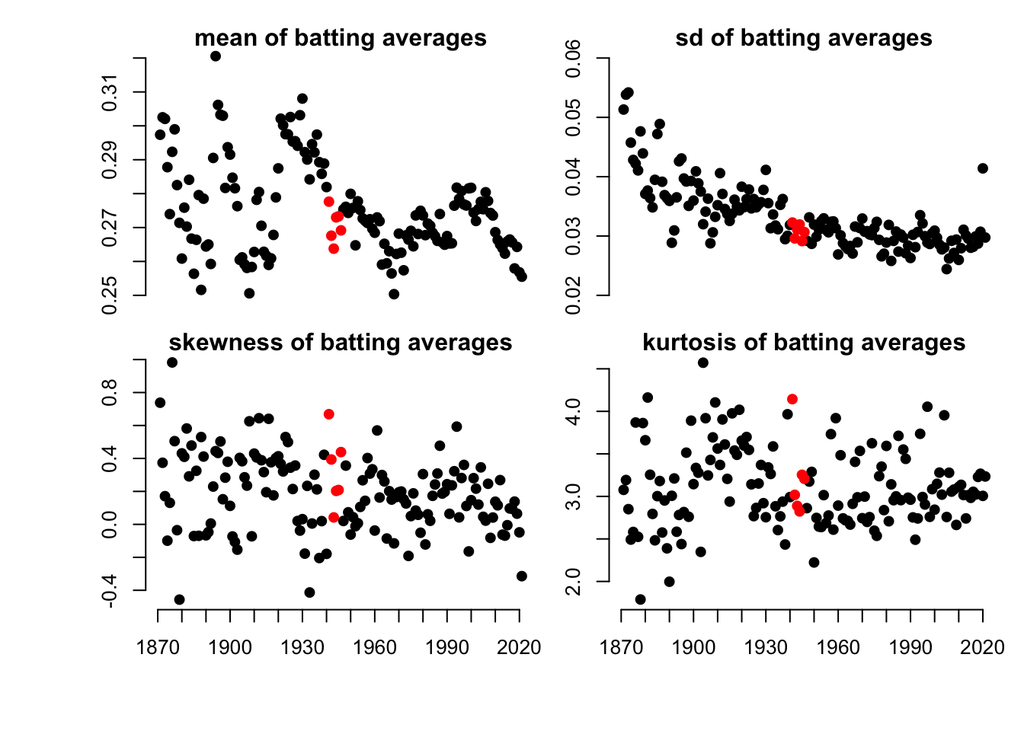

```r
batters_AB <- smoothed_AVG  %>%
  mutate(playerID = gsub('.{5}$', '', playerID)) %>%
  select(yearID, chadID, playerID, fID, name, AB, PA, AVG, mapped_PA, adj_AB)

batters <- merge(batters_AB, cutoff, by = 'yearID') %>% filter(PA >= thres)

library(moments)
years = c(1871:2021)
mom1st <- sapply(years, function(x) mean(batters %>%
                                           filter(yearID == x) %>%
                                           pull(AVG)))
mom2nd <- sapply(years, function(x) sd(batters %>%
                                           filter(yearID == x) %>%
                                           pull(AVG)))
mom3rd <- sapply(years, function(x) skewness(batters %>%
                                         filter(yearID == x) %>%
                                         pull(AVG)))
mom4th <- sapply(years, function(x) kurtosis(batters %>%
                                               filter(yearID == x) %>%
                                               pull(AVG)))

par(mfrow = c(2,2), oma = c(4,4,1,0), mar = c(1,2,1,1))
plot.new()
title('mean of batting averages')
plot.window(xlim = c(1871,2021), ylim = c(0.25,0.32))
points(years[-c(71:76)], mom1st[-c(71:76)], pch = 19)
points(years[c(71:76)], mom1st[c(71:76)], pch = 19, col = 'red')
axis(2)
plot.new()
title('sd of batting averages')
plot.window(xlim = c(1871,2021), ylim = c(0.02, 0.06))
points(years[-c(71:76)], mom2nd[-c(71:76)], pch = 19)
points(years[c(71:76)], mom2nd[c(71:76)], pch = 19, col = 'red')
axis(2)
plot.new()
title('skewness of batting averages')
plot.window(xlim = c(1871,2021), ylim = c(-0.46,0.98))
points(years[-c(71:76)], mom3rd[-c(71:76)], pch = 19)
points(years[c(71:76)], mom3rd[c(71:76)], pch = 19, col = 'red')
axis(1, xaxp=c(1870, 2020, 15), las=1)
axis(2)
plot.new()
title('kurtosis of batting averages')
plot.window(xlim = c(1871,2021), ylim = c(1.78,4.57))
points(years[-c(71:76)], mom4th[-c(71:76)], pch = 19)
points(years[c(71:76)], mom4th[c(71:76)], pch = 19, col = 'red')
axis(1, xaxp=c(1870, 2020, 15), las=1)
axis(2)
```

# Nonarametric distribution measuring components

## batters

### bWAR

In this section, our Full House Model era-adjusts bWAR using the nonparametric distribution measuring the bWAR. The code below introduces the two functions: the first one establishes the interpolated empirical CDF $\widetilde{F}_{Y_i}$ mentioned in the paper; the second one transport statistics with unknown distribution to their talent scores

```r
Ftilde <- function(y, t, ystar, component_name){
  y <- sort(y)
  n <- length(y)
  ytilde <- rep(0, n + 1)

  if (component_name == 'bWAR' | component_name == 'fWAR' | component_name == 'ERA') {
    ytilde[1] <- y[1] - (y[2] - y[1])
  }
  if (component_name == 'HR'| component_name == 'BB') {
    # since the minimal HR is greater or equal to 0.
    ytilde[1] <- 0
  }
  if (component_name == 'bWAR_p' | component_name == 'fWAR_p') {
    # since the minimal HR is greater or equal to 0.
    ytilde[1] <- y[1] - (y[2] - y[1])/10
  }
  if (component_name == 'SO') {
    # since the minimal HR is greater or equal to 0.
    ytilde[1] <- ifelse(y[1] - (y[2] - y[1]) < 0, 0, y[1] - (y[2] - y[1]) )
  }

  ytilde[n+1] <- y[n] + ystar
  ytilde[2:n] <- unlist(lapply(2:n, function(j){
    (y[j]+y[j-1])/2
  }))

  if (t >= ytilde[n+1]) {
    1 - 0.1^7
  } else if (t <= ytilde[1]) {
    0
  } else {
    j <- length(which(ytilde < t))
    (j - 1) / n + (t - ytilde[j]) / (n*(ytilde[j+1] - ytilde[j]))
  }

}
```

```r
talent_computing_nonpara <- function(dataset, component_name, year, ystar, alpha = 1.16){
  # dataset should include the component name and corresponding npop
  Ftilde <- function(y, t, ystar, component_name){
    y <- sort(y)
    n <- length(y)
    ytilde <- rep(0, n + 1)

    if (component_name == 'bWAR' | component_name == 'fWAR') {
      ytilde[1] <- y[1] - (y[2] - y[1])
    }
    if (component_name == 'HR' | component_name == 'BB') {
      # since the minimal HR is greater or equal to 0.
      ytilde[1] <- 0
    }

    ytilde[n+1] <- y[n] + ystar
    ytilde[2:n] <- unlist(lapply(2:n, function(j){
      (y[j]+y[j-1])/2
    }))

    if (t >= ytilde[n+1]) {
      1 - 0.1^7
    } else if (t <= ytilde[1]) {
      0
    } else {
      j <- length(which(ytilde < t))
      (j - 1) / n + (t - ytilde[j]) / (n*(ytilde[j+1] - ytilde[j]))
    }

  }

  Aptitude_nonpara <- function(p, alpha = 1.16, npop){

    # converts order stats to their percentiles
    order_pbino <- function(p = 0, k = 1, n = 1e4){
      pbinom(k - 1, prob = p, size = n, lower.tail = FALSE)
    }

    # converts a vector of order stats
    # to their percentiles. This vector should be the entire
    # sample sorted in increasing order
    p <- sort(p) # just in case
    n <- length(p)
    u = unlist(lapply(1:n, function(j){
      order_pbino(p[j], k = j, n = n)
    }))

    # transforms percentiles from order stats (in increasing order)
    # to Pareto values corresponding to the general population
    # of a greater than or equal to size
    # default alpha is that of the Pareto principle 80-20
    n <- length(u)
    if(length(npop) == 1) npop <- rep(npop, n)
    unlist(lapply(1:n, function(j){
      qPareto(qbeta(u[j], j + npop[j] -n , n + 1 - j), t = 1, alpha = alpha)
    }))
  }

  foo <- dataset %>% filter(yearID == year) %>%
    arrange(comp)
  bar <- foo %>% filter(PA >= thres)
  full_comp <- bar$comp
  ## batter WAR talent
  bar <- bar %>%
    mutate(WAR_talent =
             Aptitude_nonpara(p = unlist(lapply(comp, function(xx)
               Ftilde(y = comp, t = xx, ystar = ystar, component_name = component_name))), npop = pops))

  max_WAR_talent <- max(bar$WAR_talent) - 1
  range <- which(!(foo$playerID %in% bar$playerID))

  ## using the distribution from full time players
  bar <- rbind(bar, do.call(rbind, lapply(range, function(j){
    rbind(bar %>% dplyr::select(-WAR_talent), foo[j, ]) %>% arrange(comp) %>%
      mutate(WAR_talent = Aptitude_nonpara(p = unlist(lapply(comp, function(xx)
        Ftilde(y = full_comp, t = xx, ystar = ystar, component_name = component_name))), npop = pops)) %>%
      filter(PA < thres) %>%
      mutate(WAR_talent = ifelse(WAR_talent > max_WAR_talent+1, max_WAR_talent, WAR_talent))
  })))
  bar %>% mutate(ystar = ystar)
}
```

We now try out the bWAR for batters and first we select the full-time batteres. Same as what we do in parametric part, We declare the median PAs after screening out individuals who batted fewer than 75 PAs as our cutoff for full-time batters.

```r
batters <- read_csv("batters_all.csv") %>% select(yearID, bbID, name, age, PA, G, bWAR,pops)
colnames(batters)[2] <- 'playerID'

cutoff <- do.call(rbind, mclapply(years, mc.cores = ncores, FUN = function(xx){
  m <- batters %>% filter(yearID == xx) %>% filter(PA >= 75)
  data.frame(thres = median(m$PA), yearID = xx)
}))

batters <- merge(batters, cutoff, by = 'yearID')
```

We use bWAR per game as the components in the system to compute the talent score corresponding to bWAR.

```r
batters <- batters %>% mutate(comp =  bWAR / G)
```

The following function is to calculate the $Y_i^{**}$ based on the optimization problem from the paper.

```r
bat_thres <- function(component, component_name){
  ## stab means we add a small number to the largest value to avoid numerical stability problems.
  ## stab depends on the scale of input values. In most cases, the default is 0.01.
  ## cutoff means we select a certain percentage of systems that include maximal possible components in the tail
  ## rather than include k possible components in the tail based on the adjusted R adjusted square.
  ## If the distance between the largest value and second largest value in the right tail is relatively large,
  ## adjusted R square may not be a good quantity to represent how well the fit is.
  ## Then we usually choose the one sixth of all systems that their distances between the largest value and
  ## second largest value are in the top one sixth.

  if (component_name == 'bWAR') {
    cutoff <- 1.6e-2
    stab <- 0.01
  }
  if (component_name == 'fWAR') {
    cutoff <- 1.75e-2
    stab <- 0.01
  }
  if (component_name == 'HR') {
    cutoff <- 2.06e-2
    stab <- 0.01
  }
  if (component_name == 'BB') {
    cutoff <- 4.05e-2
    stab <- 0.027
  }
  # obtain initial quantities for linear approximation
  Y <- sort(as.matrix(component))
  n <- length(Y)
  Y[n] <- Y[n] + stab # for stability
  pi <- 1 - (n:1 - 1/3)/(n + 1/3)
  W <- log(pi/(1-pi))
  K1 = max(6, floor(1.3*sqrt(n))); K2 = 2*floor(log10(n)*sqrt(n))
  k <- 6

  # use arguments from Scholz section 3 for estimating k
  #
  # this argument is based on model fit and not longest stretch of
  # contiguous I0
  ind <- NULL
  try({
    k_selector <- do.call(rbind, lapply(6:K2, function(k){

      Ytil <- Y - median(Y)
      Ztil <- tail(Ytil, k)
      M1k <- 1/(k-1) * sum( log(Ztil[2:k]/Ztil[1]) )
      M2k <- 1/(k-1) * sum( log(Ztil[2:k]/Ztil[1])^2 )
      ck <- M1k + 1 - 0.5*(1 - M1k^2/M2k)^{-1}
      fck <- ((-n*log(pi))^{-ck} - 1)/ck

      Sigma <- matrix(0, k, k)
      for(i in 1:k){
        for(j in 1:i){
          Sigma[i,j] <- i^{-ck-1} * j^{-ck}
        }
      }
      for(j in 1:k){
        for(i in 1:(j-1)){
          Sigma[i,j] <- j^{-ck-1} * i^{-ck}
        }
      }

      rotate <- function(x) t(apply(x, 2, rev))
      Sigma <- rotate(rotate(Sigma))
      Sigma.inv <-  solve(Sigma)
      eig <- eigen(Sigma.inv)
      C <- eig$vec %*% diag(sqrt(eig$val)) %*% t(eig$vec)
      Zk <- C %*% tail(Y, k)
      Xk <- cbind(1, tail(fck, k))
      Wk <-  C %*% Xk
      # try linear and quadratic model
      m1 <- lm(tail(Y, k) ~ tail(fck, k))
      m2 <- lm(tail(Y, k) ~ tail(fck, k) + I(tail(fck, k)^2))
      m3 <- lm(Zk ~ -1 + Wk)
      delta.sq <- summary(m3)$sigma^2
      Tk <- coef(m3)[2] / summary(m3)$sigma

      kappa.sq <- solve(crossprod(Wk))[2,2]
      kappa <- sqrt(kappa.sq)
      I0 <- c(kappa * qt(0.25, df = k - 2, ncp = 1/kappa),
              kappa * qt(0.75, df = k - 2, ncp = 1/kappa))
      I1 <- c(kappa * qt(0.05, df = k - 2, ncp = 1/kappa),
              kappa * qt(0.95, df = k - 2, ncp = 1/kappa))
      I0int <- ifelse(I0[1] <= Tk && Tk <= I0[2], 1, 0)
      I1int <- ifelse(I1[1] <= Tk && Tk <= I1[2], 1, 0)
      c(k, Tk, I0int, I1int, summary(m1)$adj.r.squared,
        summary(m2)$adj.r.squared)

    }))

    #k <- k_selector[max(which(k_selector[, 3] == 1)), 1]
    #k <- k_selector[which.max(k_selector[, 5]), 1]
    k_selector <- as.data.frame(k_selector)
    colnames(k_selector) <- c("k", "Tk", "I0", "I1", "R.sq", "Rquad.sq")
    k_selector_I0 <- k_selector %>% filter(I0 == 1)
    a <- which.max(k_selector_I0$R.sq)
    b <- which.max(k_selector_I0$Rquad.sq)
    ind <- which.max(c(k_selector_I0[a, ]$R.sq,
                       k_selector_I0[b, ]$Rquad.sq))
    k <- k_selector_I0[c(a,b)[ind] , 1]
    if(diff(Y)[n-1] > cutoff){
      k <- max(k_selector_I0$k)
      if(k < 0) k <- K2
    }

  }, silent = TRUE)

  if(length(k) == 0) k <- round(mean(K1,K2))
  if(is.na(k)) k <- round(mean(K1,K2))
  if(k == 0) k <- round(mean(K1,K2))
  if(k >= n) k <- K2


  # find probability value using linear tail behavior
  Z <- tail(Y, k)
  m1 <- lm(tail(Y, k) ~ tail(pi, k))
  beta <- m1$coefficients
  ystar <- ub <- 0
  f <- function(x) beta[1] + beta[2] * x - max(Y)
  #delta <- beta[2]
  try({
    foo <- uniroot(f, c(0.0001, 5), tol = 1e-10)
    ub <- foo$root
  })

  # find probability value using logistic tail behavior
  if(ub >= 1){
    m1 <- lm(tail(Y,k) ~ tail(W, k))
    beta <- m1$coefficients
    f <- function(x) beta[1] + beta[2] * log(x/(1-x)) - max(Y)
    try({
      foo <- uniroot(f, c(0.000001, 0.999999), tol = 1e-10)
      ub <- foo$root
    })
  }

  # if possible, find ystar by tying logistic behavior argument to
  # our Ftilde function
  if(ub >= Ftilde(y = Y, t = max(Y), ystar = 10, component_name = component_name)){
    try({
      g <- function(ystar) ub - Ftilde(y = Y, t = max(Y), ystar = ystar, component_name = component_name)
      bar <- uniroot(g, c(0, 10), tol = 1e-10)
      ystar <- bar$root
    })
  }

  # if the above is not possible, try a similar approach for different
  # suitable values of k.
  #
  # The above fails because ub < Ftilde(y = Y, t = max(Y), ystar = 10, component_name = component_name)
  # suggesting that the largest achiever is performaing much worse than
  # expected. Thus ystar should be "large". A default large value will
  # be ystar = 6 (altered to be log(1 + 6) for stability). This will
  # be used when all else fails.
  flag <- NULL
  if(ub < Ftilde(y = Y, t = max(Y), ystar = 10, component_name = component_name)){

    # first try for largest suitable k as dictated by Scholz Section 3
    k <- max(k_selector_I0$k)
    m1 <- lm(tail(Y,k) ~ tail(W, k) + I(tail(W, k)^2))
    beta <- m1$coefficients
    f <- function(x) beta[1] + beta[2] * log(x/(1-x)) +
      beta[3] * log(x/(1-x))^2 - max(Y)
    flag <- try({
      foo <- uniroot(f, c(0.0001, 0.9999), tol = 1e-10)
      ub <- foo$root
    }, silent = TRUE)
    while(class(flag) == "try-error"){
      k <- k - 1
      # method fails; use ystar = 4
      if(k < 6){
        ystar <- 6
        break
      }
      m1 <- lm(tail(Y,k) ~ tail(W, k) + I(tail(W, k)^2))
      beta <- m1$coefficients
      f <- function(x) beta[1] + beta[2] * log(x/(1-x)) +
        beta[3] * log(x/(1-x))^2 - max(Y)
      flag <- try({
        foo <- uniroot(f, c(0.0001, 0.9999), tol = 1e-10)
        ub <- foo$root
      }, silent = TRUE)
    }

    ystar_1 <- NULL
    try({
      g <- function(ystar) ub - Ftilde(y = Y, t = max(Y), ystar = ystar, component_name = component_name)
      bar <- uniroot(g, c(0, 10), tol = 1e-10)
      ystar_1 <- bar$root
    }, silent = TRUE)
    if(length(ystar_1) == 0) ystar_1 <- 6


    # now try for smallest suitable k as dictated by Scholz Section 3
    k <- min(k_selector_I0$k)
    if(length(k) == 0) k <- 6
    m1 <- lm(tail(Y,k) ~ tail(W, k) + I(tail(W, k)^2))
    beta <- m1$coefficients
    f <- function(x) beta[1] + beta[2] * log(x/(1-x)) +
      beta[3] * log(x/(1-x))^2 - max(Y)
    flag <- try({
      foo <- uniroot(f, c(0.0001, 0.9999), tol = 1e-10)
      ub <- foo$root
    }, silent = TRUE)
    while(class(flag) == "try-error"){
      k <- k + 1
      # method fails; use ystar = 4
      if(k > max(k_selector_I0$k)){
        ystar <- 6
        break
      }
      m1 <- lm(tail(Y,k) ~ tail(W, k) + I(tail(W, k)^2))
      beta <- m1$coefficients
      f <- function(x) beta[1] + beta[2] * log(x/(1-x)) +
        beta[3] * log(x/(1-x))^2 - max(Y)
      flag <- try({
        foo <- uniroot(f, c(0.0001, 0.9999), tol = 1e-10)
        ub <- foo$root
      }, silent = TRUE)
    }

    ystar_2 <- NULL
    try({
      g <- function(ystar) ub - Ftilde(y = Y, t = max(Y), ystar = ystar, component_name = component_name)
      bar <- uniroot(g, c(0, 10), tol = 1e-10)
      ystar_2 <- bar$root
    }, silent = TRUE)
    if(length(ystar_2) == 0) ystar_2 <- 6

    # take ystar as the average of the lowest working k and
    # largest working k
    ystar <- mean(c(ystar_1, ystar_2))

  }

  # if changing k does not work, then try throwing out extreme
  # observations and computing ystar for the reduced sample (Ytil)
  #
  # then compute ystar = max(Y) - max(Ytil) + ystar*
  #
  # where ystar* is computed with respect to Ytil
  if(ystar == 6){
    k <- k_selector_I0[c(a,b)[ind] , 1]
    if(diff(Y)[n-1] > cutoff){
      k <- max(k_selector_I0$k)
      if(k < 0) k <- K2
    }
    if(length(k) == 0) k <- round(mean(K1,K2))
    if(is.na(k)) k <- round(mean(K1,K2))
    if(k == 0) k <- round(mean(K1,K2))
    if(k >= n) k <- K2

    m1 <- lm(tail(Y, k) ~ tail(W, k) + I(tail(W, k)^2))
    beta <- m1$coefficients
    f <- function(x) beta[1] + beta[2] * log(x/(1-x)) +
      beta[3] * log(x/(1-x))^2 - max(Y)
    flag <- flag2 <- try({
      foo <- uniroot(f, c(0.0001, 0.9999), tol = 1e-10)
      ub <- foo$root
    }, silent = TRUE)

    n_lwr <- n
    Ytil <- Y
    Xtil <- 1 - (n_lwr:1 - 1/3)/(n_lwr + 1/3)
    Wtil <- log(Xtil/(1-Xtil))
    while(class(flag) == "try-error" | class(flag2) == "try-error"){
      Ytil <- Ytil[-n_lwr]
      if(any(tail(Ytil, k) < 0)){
        ystar <- 6
        break
      }
      n_lwr <- n_lwr - 1
      Xtil <- 1 - (n_lwr:1 - 1/3)/(n_lwr + 1/3)
      Wtil <- log(Xtil/(1-Xtil))
      m2 <- lm(tail(Ytil, k) ~ tail(Wtil, k) + I(tail(Wtil, k)^2))
      beta <- m2$coefficients
      f <- function(x) beta[1] + beta[2] * log(x/(1-x)) +
        beta[3] * log(x/(1-x))^2 - max(Ytil)
      flag <- try({
        foo <- uniroot(f, c(0.0001, 0.9999), tol = 1e-10)
        ub <- foo$root
      }, silent = TRUE)
      flag2 <- try({
        g <- function(ystar) ub - Ftilde(y = Ytil, t = max(Ytil), ystar = ystar, component_name = component_name)
        bar <- uniroot(g, c(0, 10), tol = 1e-10)
        ystar <- bar$root
      }, silent = TRUE)
    }
    ystar <- max(Y) - Y[n_lwr] + ystar

  }

  # for stability
  ystar <- log(1 + ystar)
  ystar

}
```

The following script computes the talent scores for bWAR per game from all batters and all years(1871 to 2021).

```r
batters_talent_bWAR <- do.call(rbind, mclapply(years, mc.cores = ncores, function(yy){
  talent_computing_nonpara(dataset = batters, component_name = "bWAR", year = yy, ystar = bat_thres(component = batters %>% filter(PA >= thres, yearID == yy) %>% select(comp), component_name = 'bWAR')) })) %>% arrange(-WAR_talent)
```

We now take the above talent scores and reverse engineer the process to extract what these players who achieve if the players start their career at 1977. To do this we first introduces the function that transport their talent scores to the context of the seasons start at 1977 and estimate the era-adjusted bWAR per game.

```r
career_talent <- function(dataset, component_name, snippet, start_year){
  Rev_Aptitude_nonpara <- function(x, ytilde, alpha = 1.16, npop){

    # transforms ordered Pareto values corresponding to
    # the general population to percentiles from order stats
    # (in increasing order)
    n <- length(x)
    if(length(npop) == 1) npop <- rep(npop, n)
    u = unlist(lapply(1:n, function(j){
      pbeta(pPareto(x[j], t = 1, alpha = alpha), j + npop[j]-n, n + 1 - j)
    }))


    ## map the quantile to the a predicated sample value
    map_Y <- function(u, ytilde){
      n <- length(ytilde)-1
      seqence <- seq(0, 1, 1/n)
      pos <- findInterval(u, seqence)
      out <- (n*u -pos + 1) * (ytilde[(pos+1)] - ytilde[pos]) + ytilde[pos]
      return(out)
    }

    ## map the vector of quantiles to the predicated sample values
    n <- length(u)
    a <- qbeta(u, shape1 = 1:n, shape2 = n:1)
    out <- sapply(1:n, function(x) map_Y(a[x], ytilde = ytilde))
    out

  }

  min_year <- min(snippet$yearID)
  max_year <- max(snippet$yearID)
  end_year <- max_year - min_year + start_year
  end_year <- ifelse(end_year <= 2021, end_year, 2021)

  snippet <- snippet %>% mutate(playerID = paste(playerID, "_proj", sep = ""))
  do.call(rbind, lapply(start_year : end_year, function(xx){
    batters_int <- dataset %>% filter(yearID == xx, PA >= thres)

    target_snippet <- snippet %>% filter(yearID == (xx - start_year + min_year))
    yy <- sort(batters_int$comp)
    n <- length(yy)
    ytilde <- rep(0, n + 1)
    if (component_name == 'bWAR' | component_name == 'fWAR') {
      ytilde[1] <- yy[1] - (yy[2] - yy[1])
    }
    if (component_name == 'HR' | component_name == 'BB') {
      # since the minimal HR is greater or equal to 0.
      ytilde[1] <- 0
    }
    ytilde[n+1] <- yy[n] + unique(batters_int$ystar)
    ytilde[2:n] <- unlist(lapply(2:n, function(j){
      (yy[j]+yy[j-1])/2
    }))

    batters_int <- rbind(batters_int, target_snippet)
    batters_int$pops[nrow(batters_int)] <- batters_int$pops[1]
    batters_int <- batters_int %>% arrange(WAR_talent) %>%
      mutate(adj_comp = Rev_Aptitude_nonpara(WAR_talent, ytilde = ytilde, npop = pops)) %>%
      filter(playerID == unique(snippet$playerID))
    batters_int %>% mutate(ref_year = xx)
  }))

}
```

The codes below compute hypothetical careers in which we suppose that every player all start their career at 1977.

```r
foo <- batters_talent_bWAR
foo$playerID <- droplevels(as.factor(foo$playerID))

# get career adjustment on season by season basis
ss = 1977

career_kAB <- do.call(rbind, mclapply(unique(foo$playerID), function(zz){
  int <- career_talent(dataset = foo, component_name = 'bWAR',
                       snippet = foo %>% filter(playerID == zz),
                       start_year = ss)
  int
}, mc.cores = ncores))
```

Instead of using the raw games in the data set, we calculate the mapped games by applying quantile mapping for the full-time hitters and non-full-time hitters separately. Quantile mapping is based on that a pth percentile player’s games in one year is equal to a pth percentile player’s games in another year.

We will assume that worst performance in the full time players in each season are considered as the worst performance for all players in that season.

```r
mapped_quan_b <- read.csv('mapped_quan_b.csv')[,-1]

mapped_cutoff <- cutoff
colnames(mapped_cutoff) <- c('PA_thres', 'ref_year')

career_kAB <- career_kAB %>% mutate(playerID = gsub('.{5}$', '', playerID))

mapped_batters_1 <- merge(career_kAB, mapped_quan_b,
                          by = c('playerID', 'yearID', 'ref_year'))

mapped_batters_2 <- merge(mapped_batters_1, mapped_cutoff,
                          by = c('ref_year'))

mapped_batters_3 <- mapped_batters_2 %>% mutate(adj_bWAR = adj_comp * mapped_G)

min_refbWAR <- do.call(rbind, mclapply(years, function(zz){
  m <- mapped_batters_3 %>% filter(yearID == zz, PA >= thres)
  data.frame(ref_year = zz, min_bWAR = min(m$bWAR))
}, mc.cores = ncores))

mapped_batters <- merge(mapped_batters_3, min_refbWAR,
                        by = c('ref_year'))
```

We trim careers when era-adjusted bWAR falls below replacement level for an extended period of time. The players will be removed from the league if their bad-performances last for a long time. The code below shows that how we trim the players when they display below replacement level.

```r
career_kAB_trim <- do.call(rbind, mclapply(
  split(mapped_batters, f = droplevels(as.factor(mapped_batters$playerID))),
  mc.cores = ncores, FUN = function(xx){
    zz <- xx %>% filter(PA < thres) %>%
      mutate(adj_bWAR = (1 - mapped_PA/PA_thres) * bWAR + mapped_PA/PA_thres * (adj_bWAR))
    tt <- xx %>% filter(PA >= thres)
    xx <- rbind(zz, tt) %>% arrange(yearID)

    m1 <- xx %>% filter(adj_bWAR < min_bWAR) %>%
      mutate(adj_bWAR = min_bWAR) %>%
      mutate(mapped_G = adj_bWAR / adj_comp)
    m2 <- xx %>% filter(adj_bWAR >= min_bWAR)
    rbind(m1, m2) %>% arrange(yearID)

  }))

career_kAB_trim_select <- career_kAB_trim
```

We apply the smoothing method from the parametric part to the era-adjusted bWAR.

```r
library(splines)
smoothed_bWAR <- do.call(rbind, mclapply(
  split(career_kAB_trim_select,
        f = droplevels(as.factor(career_kAB_trim_select$playerID))),
  mc.cores = ncores, FUN = function(xx){
    ## natural cubic spline
    ns_bWAR = lm(adj_bWAR ~ ns(yearID, df=6), data=xx)
    nn_bWAR <- predict(ns_bWAR, data.frame("yearID"= xx$yearID))
    xx %>% mutate(ss_adj_bWAR = nn_bWAR) %>%
      mutate(avg_bWAR = (ss_adj_bWAR + adj_bWAR)/2)
  }))

career_bWAR <- smoothed_bWAR %>% group_by(playerID) %>%
  summarise(name = unique(name), playerID = unique(playerID), rookie_year = min(yearID),
            avg_bWAR = sum(avg_bWAR), bWAR = sum(bWAR), span = n()) %>%
  arrange(desc(avg_bWAR)) %>% ungroup()
rownames(career_bWAR) <- c()
```

We will repeat the same processes to the remaining baseball statistics: such as fWAR for batters, Home Run, bWAR and fWAR for pitchers, ERA and SO.

### fWAR

```r
batters <- read_csv("batters_all.csv") %>% select(yearID, bbID, name, PA, G, fWAR,pops)
colnames(batters)[2] <- 'playerID'

cutoff <- do.call(rbind, mclapply(years, mc.cores = ncores, FUN = function(xx){
  m <- batters %>% filter(yearID == xx) %>% filter(PA >= 75)
  data.frame(thres = median(m$PA), yearID = xx)
}))

batters <- merge(batters, cutoff, by = 'yearID')
batters <- batters %>% mutate(comp =  fWAR / G)
```

```r
batters_talent_fWAR <- do.call(rbind, mclapply(years, mc.cores = ncores, function(yy){
  talent_computing_nonpara(dataset = batters, component_name = "fWAR",
                           year = yy, ystar = bat_thres(component = batters %>%
                                                          filter(PA >= thres, yearID == yy) %>%
                                                          select(comp), component_name = 'fWAR'))
})) %>% arrange(-WAR_talent)
```

```r
foo <- batters_talent_fWAR
foo$playerID <- droplevels(as.factor(foo$playerID))

# get career adjustment on season by season basis
ss = 1977

career_kAB <- do.call(rbind, mclapply(unique(foo$playerID), function(zz){
  int <- career_talent(dataset = foo, component_name = 'fWAR',
                       snippet = foo %>% filter(playerID == zz),
                       start_year = ss)
  int
}, mc.cores = ncores))
```

```r
mapped_quan_b <- read.csv('mapped_quan_b.csv')[,-1]

mapped_cutoff <- cutoff
colnames(mapped_cutoff) <- c('PA_thres', 'ref_year')

career_kAB <- career_kAB %>% mutate(playerID = gsub('.{5}$', '', playerID))

mapped_batters_1 <- merge(career_kAB, mapped_quan_b,
                          by = c('playerID', 'yearID', 'ref_year'))

mapped_batters_2 <- merge(mapped_batters_1, mapped_cutoff,
                          by = c('ref_year'))

mapped_batters_3 <- mapped_batters_2 %>% mutate(adj_fWAR = adj_comp * mapped_G)

min_reffWAR <- do.call(rbind, mclapply(years, function(zz){
  m <- mapped_batters_3 %>% filter(yearID == zz, PA >= thres)
  data.frame(ref_year = zz, min_fWAR = min(m$fWAR))
}, mc.cores = ncores))

mapped_batters <- merge(mapped_batters_3, min_reffWAR,
                        by = c('ref_year'))
```

```r
career_kAB_trim <- do.call(rbind, mclapply(
  split(mapped_batters, f = droplevels(as.factor(mapped_batters$playerID))),
  mc.cores = ncores, FUN = function(xx){
    zz <- xx %>% filter(PA < thres) %>%
      mutate(adj_fWAR = (1 - mapped_PA/PA_thres) * fWAR + mapped_PA/PA_thres * (adj_fWAR))
    tt <- xx %>% filter(PA >= thres)
    xx <- rbind(zz, tt) %>% arrange(yearID)

    m1 <- xx %>% filter(adj_fWAR < min_fWAR) %>%
      mutate(adj_fWAR = min_fWAR) %>%
      mutate(mapped_G = adj_fWAR / adj_comp)
    m2 <- xx %>% filter(adj_fWAR >= min_fWAR)
    rbind(m1, m2) %>% arrange(yearID)

  }))

career_kAB_trim_select <- career_kAB_trim %>%
  select(name, playerID, yearID, adj_fWAR, fWAR, ref_year)

library(splines)
smoothed_fWAR <- do.call(rbind, mclapply(
  split(career_kAB_trim_select,
        f = droplevels(as.factor(career_kAB_trim_select$playerID))),
  mc.cores = ncores, FUN = function(xx){
    ## natural cubic spline
    ns_fWAR = lm(adj_fWAR ~ ns(yearID, df=6), data=xx)
    nn_fWAR <- predict(ns_fWAR, data.frame("yearID"= xx$yearID))
    xx %>% mutate(ss_adj_fWAR = nn_fWAR) %>%
      mutate(avg_fWAR = (ss_adj_fWAR + adj_fWAR)/2)
  }))

career_fWAR <- smoothed_fWAR %>% group_by(playerID) %>%
  summarise(name = unique(name), playerID = unique(playerID), rookie_year = min(yearID),
            avg_fWAR = sum(avg_fWAR), fWAR = sum(fWAR), span = n()) %>%
  arrange(desc(avg_fWAR)) %>% ungroup()

rownames(career_fWAR) <- c()
```

### Figure 2: year effect of bWAR and fWAR in the paper

```r
# bWAR

ref_2021 <- batters_talent_bWAR %>% filter(yearID == 2021) %>% filter(PA >= thres) %>%
  select(yearID, playerID, PA, comp, pops, thres)
fake_player <- data.frame(yearID = 2021, playerID = "fake01", PA = 315, comp = 0,
                          pops = unique(ref_2021$pops), thres = 315 )
ref_2021 <- rbind(ref_2021, fake_player)
bar <- ref_2021 %>% arrange(comp)

## batter WAR talent

talent_2021 <- talent_computing_nonpara(dataset = bar, component_name = "bWAR", year = 2021, ystar = bat_thres(component = bar %>% select(comp), component_name = 'bWAR'))

foo <- batters_talent_bWAR %>%
  select(yearID, playerID, PA, comp, pops, thres, WAR_talent, ystar)

career_talent_0 <- function(snippet, target_year){
  Rev_Aptitude_nonpara <- function(x, ytilde, alpha = 1.16, npop){

    # transforms ordered Pareto values corresponding to
    # the general population to percentiles from order stats
    # (in increasing order)
    n <- length(x)
    if(length(npop) == 1) npop <- rep(npop, n)
    u = unlist(lapply(1:n, function(j){
      pbeta(pPareto(x[j], t = 1, alpha = alpha), j + npop[j]-n, n + 1 - j)
    }))


    ## map the quantile to the a predicated sample value
    map_Y <- function(u, ytilde){
      n <- length(ytilde)-1
      seqence <- seq(0, 1, 1/n)
      pos <- findInterval(u, seqence)
      out <- (n*u -pos + 1) * (ytilde[(pos+1)] - ytilde[pos]) + ytilde[pos]
      return(out)
    }

    ## map the vector of quantiles to the predicated sample values
    n <- length(u)
    a <- qbeta(u, shape1 = 1:n, shape2 = n:1)
    out <- sapply(1:n, function(x) map_Y(a[x], ytilde = ytilde))
    out

  }

  snippet <- snippet %>% mutate(playerID = paste(playerID, "_proj", sep = ""))
  do.call(rbind, lapply(snippet$yearID, function(xx){
    batters_int <- foo %>% filter(yearID == target_year) %>% filter(PA >= thres)

    if (target_year == 2021) {
      yy = sort(ref_2021$comp)
    } else {
      yy <- sort(batters_int$comp)
    }
    n <- length(yy)
    ytilde <- rep(0, n + 1)
    ytilde[1] <- yy[1] - (yy[2] - yy[1])
    ytilde[n+1] <- yy[n] + unique(batters_int$ystar)
    ytilde[2:n] <- unlist(lapply(2:n, function(j){
      (yy[j]+yy[j-1])/2
    }))

    batters_int <- rbind(batters_int, snippet %>% filter(yearID == xx))
    batters_int$pops[nrow(batters_int)] <- batters_int$pops[1]
    batters_int <- batters_int %>% arrange(WAR_talent) %>%
      mutate(adj_comp = Rev_Aptitude_nonpara(WAR_talent, ytilde = ytilde, npop = pops)) %>%
      filter(playerID == unique(snippet$playerID))

    batters_int
  })) %>% mutate(ref_year = target_year)
}

adj_0_bWAR <- do.call(rbind, mclapply(1871:2021, function(xx){
  int <- career_talent_0(snippet = talent_2021 %>% filter(playerID == 'fake01'), target_year = xx)
  int
}, mc.cores = ncores))

## quantile mapping
m <- mapped_batters_1 %>% filter(PA >= thres) %>% select(yearID, G, mapped_G)

adj_season_G <- do.call(rbind, mclapply(1871:2021, function(xx){
  s <- m %>% filter(yearID == xx)
  c(ref_year = xx, mapped_G = approx(s$mapped_G, s$G, xout = 120)$y)
}, mc.cores = ncores))

adj_0_bWAR_G <- merge(adj_0_bWAR, adj_season_G, by = c('ref_year'))

adj_0_bWAR_G <- adj_0_bWAR_G %>% mutate(adj_bWAR = adj_comp * mapped_G)
```

```r
# fWAR

ref_2021 <- batters_talent_fWAR %>% filter(yearID == 2021) %>% filter(PA >= thres) %>%
  select(yearID, playerID, PA, comp, pops, thres)
fake_player <- data.frame(yearID = 2021, playerID = "fake01", PA = 315, comp = 1e-10,
                          pops = unique(ref_2021$pops), thres = 315 )
ref_2021 <- rbind(ref_2021, fake_player)
bar <- ref_2021 %>% arrange(comp)

## batter WAR talent

talent_2021 <- talent_computing_nonpara(dataset = bar, component_name = "fWAR", year = 2021, ystar = bat_thres(component = bar %>% select(comp), component_name = 'fWAR'))

foo <- batters_talent_fWAR %>%
  select(yearID, playerID, PA, comp, pops, thres, WAR_talent, ystar)

career_talent_0 <- function(snippet, target_year){
  Rev_Aptitude_nonpara <- function(x, ytilde, alpha = 1.16, npop){

    # transforms ordered Pareto values corresponding to
    # the general population to percentiles from order stats
    # (in increasing order)
    n <- length(x)
    if(length(npop) == 1) npop <- rep(npop, n)
    u = unlist(lapply(1:n, function(j){
      pbeta(pPareto(x[j], t = 1, alpha = alpha), j + npop[j]-n, n + 1 - j)
    }))


    ## map the quantile to the a predicated sample value
    map_Y <- function(u, ytilde){
      n <- length(ytilde)-1
      seqence <- seq(0, 1, 1/n)
      pos <- findInterval(u, seqence)
      out <- (n*u -pos + 1) * (ytilde[(pos+1)] - ytilde[pos]) + ytilde[pos]
      return(out)
    }

    ## map the vector of quantiles to the predicated sample values
    n <- length(u)
    a <- qbeta(u, shape1 = 1:n, shape2 = n:1)
    out <- sapply(1:n, function(x) map_Y(a[x], ytilde = ytilde))
    out

  }

  snippet <- snippet %>% mutate(playerID = paste(playerID, "_proj", sep = ""))
  do.call(rbind, lapply(snippet$yearID, function(xx){
    batters_int <- foo %>% filter(yearID == target_year) %>% filter(PA >= thres)

    if (target_year == 2021) {
      yy = sort(ref_2021$comp)
    } else {
      yy <- sort(batters_int$comp)
    }
    n <- length(yy)
    ytilde <- rep(0, n + 1)
    ytilde[1] <- yy[1] - (yy[2] - yy[1])
    ytilde[n+1] <- yy[n] + unique(batters_int$ystar)
    ytilde[2:n] <- unlist(lapply(2:n, function(j){
      (yy[j]+yy[j-1])/2
    }))

    batters_int <- rbind(batters_int, snippet %>% filter(yearID == xx))
    batters_int$pops[nrow(batters_int)] <- batters_int$pops[1]
    batters_int <- batters_int %>% arrange(WAR_talent) %>%
      mutate(adj_comp = Rev_Aptitude_nonpara(WAR_talent, ytilde = ytilde, npop = pops)) %>%
      filter(playerID == unique(snippet$playerID))

    batters_int
  })) %>% mutate(ref_year = target_year)
}

adj_0_fWAR <- do.call(rbind, mclapply(1871:2021, function(xx){
  int <- career_talent_0(snippet = talent_2021 %>% filter(playerID == 'fake01'), target_year = xx)
  int
}, mc.cores = ncores))

## quantile mapping
m <- mapped_batters_1 %>% filter(PA >= thres) %>% select(yearID, G, mapped_G)

adj_season_G <- do.call(rbind, mclapply(1871:2021, function(xx){
  s <- m %>% filter(yearID == xx)
  c(ref_year = xx, mapped_G = approx(s$mapped_G, s$G, xout = 113)$y)
}, mc.cores = ncores))

adj_0_fWAR_G <- merge(adj_0_fWAR, adj_season_G, by = c('ref_year'))

adj_0_fWAR_G <- adj_0_fWAR_G %>% mutate(adj_fWAR = adj_comp * mapped_G)
```

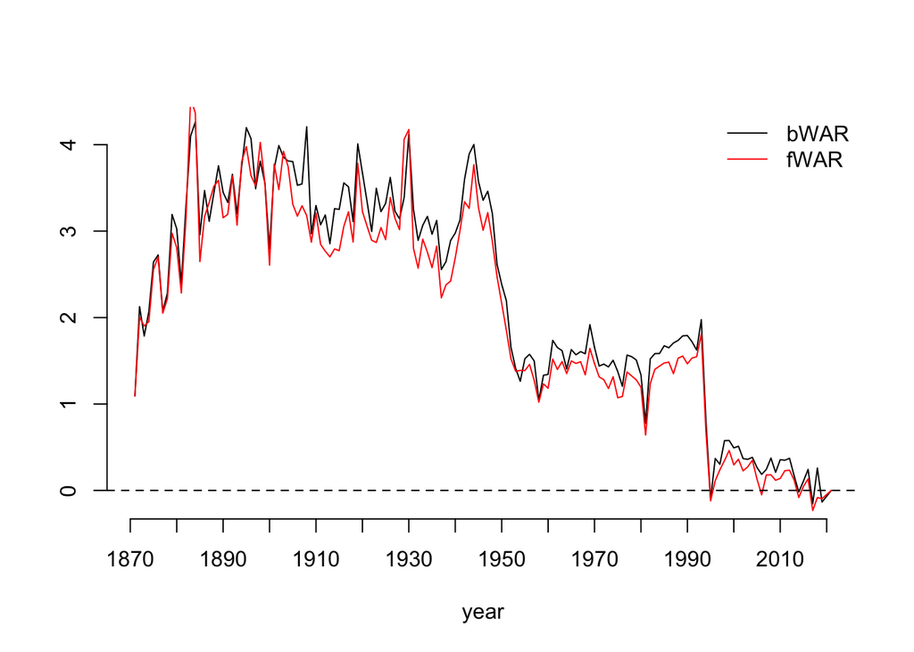

```r
year = c(1871:2021)[-150]
plot(year, (adj_0_bWAR_G$adj_comp * adj_0_bWAR_G$mapped_G)[-150],
     type = 'l', col="black", ylab="", bty = 'n', xaxt="n")
axis(1, xaxp=c(1870, 2020, 15), las=1)
lines(year, (adj_0_fWAR_G$adj_comp * adj_0_fWAR_G$mapped_G)[-150],
      col="red")
abline(h = 0, lty = 2)
legend('topright', legend = c('bWAR', 'fWAR'),
       col = c('black','red'), lty = 1, bty = 'n')
```

### HR

```r
batters_HR <- read_csv("batters_all.csv") %>% select(yearID, bbID, name, PA, HR, HR_AB, BB, HBP, SH, SF, pops)
colnames(batters_HR)[2] <- 'playerID'

cutoff <- do.call(rbind, mclapply(years, mc.cores = ncores, FUN = function(xx){
  m <- batters_HR %>% filter(yearID == xx) %>% filter(PA >= 75)
  data.frame(thres = median(m$PA), yearID = xx)
}))

batters <- merge(batters_HR, cutoff, by = 'yearID')

batters <- batters %>% mutate(comp =  HR_AB)
```

```r
batters_talent_HR <- do.call(rbind, mclapply(years, mc.cores = ncores, function(yy){
  talent_computing_nonpara(dataset = batters, component_name = "HR",
                           year = yy, ystar = bat_thres(component = batters %>%
                                                          filter(PA >= thres, yearID == yy) %>%
                                                          select(comp), component_name = 'HR'))
})) %>% arrange(-WAR_talent)
```

```r
foo <- batters_talent_HR
foo$playerID <- droplevels(as.factor(foo$playerID))

# get career adjustment on season by season basis
## career start at 1977
ss = 1977

career_kAB <- do.call(rbind, mclapply(unique(foo$playerID), function(zz){
  int <- career_talent(dataset = foo, component_name = 'HR',
                       snippet = foo %>% filter(playerID == zz),
                       start_year = ss)
  int
}, mc.cores = ncores))
```

### BB

```r
batters_BB <- read_csv("batters_all.csv") %>% select(yearID, bbID, name, PA, BB, pops)
colnames(batters_BB)[2] <- 'playerID'

cutoff <- do.call(rbind, mclapply(years, mc.cores = ncores, FUN = function(xx){
  m <- batters_BB %>% filter(yearID == xx) %>% filter(PA >= 75)
  data.frame(thres = median(m$PA), yearID = xx)
}))

batters <- merge(batters_BB, cutoff, by = 'yearID')
batters$PA[batters$PA == 0] <- 1
batters <- batters %>% mutate(comp = BB / PA)
```

```r
batters_talent_BB <- do.call(rbind, mclapply(years, mc.cores = ncores, function(yy){
  talent_computing_nonpara(dataset = batters, component_name = "BB",
                           year = yy, ystar =
                             bat_thres(component = batters %>%
                                         filter(PA >= thres, yearID == yy) %>%
                                         select(comp), component_name = 'BB'))
})) %>% arrange(-WAR_talent)
```

```r
foo <- batters_talent_BB
foo$playerID <- droplevels(as.factor(foo$playerID))

# get career adjustment on season by season basis
ss = 1977

career_kAB_BB <- do.call(rbind, mclapply(unique(foo$playerID), function(zz){
  int <- career_talent(dataset = foo, component_name = 'BB',
                       snippet = foo %>% filter(playerID == zz),
                       start_year = ss)
  int
}, mc.cores = ncores))
```

```r
mapped_quan_b <- read.csv('mapped_quan_b.csv')[,-1]

mapped_cutoff <- cutoff
colnames(mapped_cutoff) <- c('PA_thres', 'ref_year')

colnames(career_kAB)[16] <- 'adj_HR_AB'

career_combined <- merge(career_kAB %>% select(-comp), career_kAB_BB %>%
                           select(yearID, playerID, comp, adj_comp), by = c('yearID', 'playerID'))

career_combined <- career_combined %>% mutate(playerID = gsub('.{5}$', '', playerID))

mapped_batters_1 <- merge(career_combined, mapped_quan_b,
                          by = c('playerID', 'yearID', 'ref_year'))

mapped_batters_2 <- merge(mapped_batters_1, mapped_cutoff,
                          by = c('ref_year'))

min_refBB <- do.call(rbind, mclapply(years, function(zz){
  m <- mapped_batters_2 %>% filter(yearID == zz, PA >= thres)
  data.frame(ref_year = zz, min_BB = min(m$BB))
}, mc.cores = ncores))

mapped_batters_3 <- merge(mapped_batters_2, min_refBB,
                          by = c('ref_year'))

min_refHR <- do.call(rbind, mclapply(years, function(zz){
  m <- mapped_batters_3 %>% filter(yearID == zz, PA >= thres)
  data.frame(ref_year = zz, min_HR = min(m$HR))
}, mc.cores = ncores))

mapped_batters_4 <- merge(mapped_batters_3, min_refHR,
                          by = c('ref_year'))


mapped_batters <- mapped_batters_4 %>%
  mutate(adj_BB = ceiling(adj_comp * ceiling(mapped_PA))) %>%
  mutate(adj_BB = ifelse(adj_BB < min_BB, min_BB, adj_BB)) %>%
  mutate(adj_AB = ceiling(mapped_PA) - adj_BB - HBP - SH - SF) %>%
  mutate(adj_AB = ifelse(adj_AB <0, 0, adj_AB)) %>%
  mutate(adj_HR = ceiling(adj_HR_AB * adj_AB)) %>%
  mutate(adj_HR = ifelse(adj_HR < min_HR, min_HR, adj_HR))
```

```r
career_kAB_trim <- do.call(rbind, mclapply(
  split(mapped_batters, f = droplevels(as.factor(mapped_batters$playerID))),
  mc.cores = ncores, FUN = function(xx){
    ## weighted average for HR
    xx <- xx %>% arrange(yearID)
    zz <- xx %>% filter(mapped_PA < PA_thres) %>%
      mutate(adj_HR = ceiling((1 - mapped_PA/PA_thres) * HR +
                                mapped_PA/PA_thres * (adj_HR))) %>%
      mutate(adj_BB = ceiling((1 - mapped_PA/PA_thres) * BB +
                                mapped_PA/PA_thres * (adj_BB)))
    mm <- rbind(zz, xx %>% filter(mapped_PA >= PA_thres)) %>% arrange(yearID)
    mm
  }))

library(splines)
smoothed_BB <- do.call(rbind, mclapply(
  split(career_kAB_trim, f = droplevels(as.factor(career_kAB_trim$playerID))),
  mc.cores = ncores, FUN = function(xx){
    ## natural cubic spline
    ns_BB = lm(adj_BB ~ ns(yearID, df=6), data=xx)
    nn_BB <- predict(ns_BB, data.frame("yearID"= xx$yearID))
    xx %>% mutate(ss_adj_BB = round(nn_BB)) %>%
      mutate(avg_BB = round((ss_adj_BB + adj_BB)/2))
  }))

smoothed_HR <- do.call(rbind, mclapply(
  split(career_kAB_trim, f = droplevels(as.factor(career_kAB_trim$playerID))),
  mc.cores = ncores, FUN = function(xx){
    ## natural cubic spline
    ns_HR = lm(adj_HR_AB ~ ns(yearID, df=6), data=xx)
    nn_HR_AB <- predict(ns_HR, data.frame("yearID"= xx$yearID))
    nn_HR_AB <- ifelse(nn_HR_AB < 0, 0, nn_HR_AB)
    xx %>% mutate(ss_adj_HR_AB = nn_HR_AB) %>%
      mutate(avg_HR_AB = (adj_HR_AB + ss_adj_HR_AB)/2)
  }))

smoothed_HR <- smoothed_HR %>% mutate(ss_adj_HR = ceiling(ss_adj_HR_AB * adj_AB)) %>%
  mutate(avg_HR = ceiling(avg_HR_AB * adj_AB))

career_BB <- smoothed_BB %>% group_by(playerID) %>%
  summarise(name = unique(name), playerID = unique(playerID), rookie_year = min(yearID),
            avg_BB = sum(avg_BB), BB = sum(BB), span = n()) %>%
  arrange(desc(avg_BB)) %>% ungroup()

career_HR <- smoothed_HR %>% group_by(playerID) %>%
  summarise(name = unique(name), playerID = unique(playerID), rookie_year = min(yearID),
            avg_HR = sum(avg_HR), HR = sum(HR), span = n()) %>%
  arrange(desc(avg_HR)) %>% ungroup()

rownames(career_BB) <- c()
rownames(career_HR) <- c()
```

### combined batting statistics

We combine all the era-adjusted batting statistics together.

```r
smoothed_AVG <- smoothed_AVG %>% mutate(playerID = gsub('.{5}$', '', playerID))

AVG_part <- smoothed_AVG %>% mutate(AVG = round(AVG, 3)) %>%
  mutate(adj_AVG = round(adj_AVG, 3)) %>%
  mutate(avg_AVG = round(avg_AVG, 3)) %>%
  mutate(obs_AVG = round(obs_AVG, 3)) %>%
  mutate(obs_hits = round(obs_hits)) %>%
  mutate(obs_HR = round(obs_HR)) %>%
  mutate(AB = round(AB)) %>%
  mutate(adj_AB = round(adj_AB)) %>%
  mutate(avg_hits = round(adj_AB * avg_AVG)) %>%
  select(yearID, playerID, name, AB, adj_AB, obs_AVG, AVG, avg_AVG, obs_hits, avg_hits, obs_HR)
```

```r
HR_part <- smoothed_HR %>% mutate(mapped_PA = round(mapped_PA)) %>%
  select(yearID, playerID, HR, avg_HR, HBP, SF, PA,mapped_PA)
```

```r
bWAR_part <- smoothed_bWAR %>% mutate(bWAR = round(bWAR, 2)) %>%
  mutate(avg_bWAR = round(avg_bWAR, 2)) %>%
  select(yearID, playerID, age, G, mapped_G, bWAR, avg_bWAR, pops)
```

```r
fWAR_part <- smoothed_fWAR %>% mutate(fWAR = round(fWAR, 2)) %>%
  mutate(avg_fWAR = round(avg_fWAR, 2)) %>%
  select(yearID, playerID, fWAR, avg_fWAR)
```

```r
BB_part <- smoothed_BB %>% select(yearID, playerID, BB, adj_BB, avg_BB)
```

```r
master_batters <- merge(BB_part, merge(AVG_part,
                                       merge(HR_part, merge(bWAR_part, fWAR_part,
                                                            by = c('yearID', 'playerID')),
                                             by = c('yearID', 'playerID')),
                                       by = c('yearID', 'playerID')),
                        by = c('yearID', 'playerID'))

master_batters <- master_batters %>% mutate(obs_OBP = (obs_hits + BB + HBP) / (AB + BB + HBP + SF)) %>%
  mutate(avg_OBP = (avg_AVG * adj_AB + avg_BB + HBP) / (adj_AB + avg_BB + HBP + SF))
master_batters$obs_OBP[is.na(master_batters$obs_OBP)] <- 0
master_batters$avg_OBP[is.na(master_batters$avg_OBP)] <- 0

master_batters <- master_batters %>% mutate(avg_BB = ifelse(avg_BB < 0, 0, avg_BB)) %>%
  mutate(adj_AB = ifelse(mapped_PA < adj_AB, mapped_PA, adj_AB))
```

### final adjustment on batters

We extract and remove bad performance season in their career

```r
batters <- master_batters %>%
  mutate(adj_AB_HR = round(adj_AB/avg_HR, 1))
batters <- batters[batters$avg_bWAR != 0, ]

foo <- batters %>%
  arrange(desc(avg_AVG)) %>%
  filter(adj_AB >= 300) %>%
  dplyr::select(name, playerID, yearID, adj_AB, avg_AVG, avg_OBP, avg_HR, avg_fWAR, avg_bWAR) %>%
  mutate(adj_HR_AB = round(avg_HR/adj_AB,4))

bar <- split(foo, as.factor(foo$playerID))
baz <- do.call(rbind, lapply(bar, function(m){
  m[which.max(m$avg_fWAR), ]
}))
baz <- baz %>% arrange(avg_fWAR)
bad_players_fWAR <- baz %>% filter(avg_fWAR < 0) %>% pull(playerID)

baz <- do.call(rbind, lapply(bar, function(m){
  m[which.max(m$avg_bWAR), ]
}))
baz <- baz %>% arrange(avg_bWAR)
bad_players_bWAR <- baz %>% filter(avg_bWAR < 0) %>% pull(playerID)
bad_players <- union(bad_players_bWAR, bad_players_fWAR)
batters <- batters[!batters$playerID %in% bad_players, ]

###### investigate anomalies ######

## more on base events than PAs
# problem with the smoothing, revert to adjustment
batters[which(batters$avg_BB > batters$mapped_PA), ]$avg_BB <-
  batters[which(batters$avg_BB > batters$mapped_PA), ]$adj_BB
batters[which(batters$avg_BB > batters$mapped_PA), ]$mapped_PA <-
  batters[which(batters$avg_BB > batters$mapped_PA), ]$avg_BB

# taper down average WAR for players with small PAs
batters[batters$mapped_PA <= 20, ]$avg_fWAR <-
  round(batters[batters$mapped_PA <= 20, ]$avg_fWAR/9,2)
batters[batters$mapped_PA <= 20, ]$avg_bWAR <-
  round(batters[batters$mapped_PA <= 20, ]$avg_bWAR/9,2)

# check average for minimal at bats and correct issues
batters[batters$avg_AVG > 0 & batters$adj_AB == 0, ]$avg_AVG <- 0
batters <- batters %>% mutate(avg_hits = round(avg_AVG * adj_AB))
batters[batters$adj_AB > 0, ]$avg_AVG <-
  round(batters[batters$adj_AB > 0, ]$avg_hits / batters[batters$adj_AB > 0, ]$adj_AB, 3)

# recalculate adjusted OBP
index <- batters$adj_AB + batters$avg_BB + batters$HBP + batters$SF > 0
batters[!index, ]$avg_OBP <- 0
batters[index, ]$avg_OBP <-
  round((batters[index, ]$avg_hits + batters[index, ]$avg_BB + batters[index, ]$HBP)/
          (batters[index, ]$adj_AB + batters[index, ]$avg_BB + batters[index, ]$HBP + batters[index, ]$SF),3 )

# recalculate home runs
batters[batters$avg_HR > batters$adj_AB, ]$batters$avg_HR <-
  batters[batters$avg_HR > batters$adj_AB, ]$batters$adj_AB
batters <- batters %>%
  mutate(adj_AB_HR = round(adj_AB/avg_HR, 1))


## build adjusted data set
batters_adjusted <- batters %>%
  dplyr::select(name, playerID, age, yearID, mapped_PA, adj_AB, avg_hits, avg_HR, avg_BB,
                avg_AVG, avg_OBP, HBP, SF, avg_bWAR, avg_fWAR)
colnames(batters_adjusted) <- c("name", "playerID", "age", "year", "PA", "AB", "H",
                                "HR", "BB", "AVG", "OBP", "HBP", "SF", "ebWAR", "efWAR")
batters_adjusted$playerID <- droplevels(as.factor(batters_adjusted$playerID))
batters_adjusted <- batters_adjusted[!is.na(batters_adjusted$age), ]


## trim out bad players
# first round
foo <- split(batters_adjusted, f = batters_adjusted$playerID)
bar <- lapply(foo, function(m){
  ifelse(m$ebWAR <= 0, 1, 0) + ifelse(m$efWAR <= 0, 1, 0)
})
checker <- data.frame(pid = levels(batters_adjusted$playerID),
                      m_bad = unlist(lapply(bar, mean)),
                      len = unlist(lapply(bar, length)))
batters_adjusted <- batters_adjusted %>%
  filter(!batters_adjusted$playerID %in% rownames(checker)[checker$m_bad == 2])
batters_adjusted$playerID <- droplevels(batters_adjusted$playerID)

# second round
foo <- split(batters_adjusted, f = batters_adjusted$playerID)
bar <- lapply(foo, function(m){
  ifelse(m$ebWAR <= 0, 1, 0) + ifelse(m$efWAR <= 0, 1, 0)
})
checker <- data.frame(pid = levels(batters_adjusted$playerID),
                      m_bad = unlist(lapply(bar, mean)),
                      len = unlist(lapply(bar, length)))
batters_adjusted <- batters_adjusted %>%
  filter(!batters_adjusted$playerID %in% rownames(checker)[checker$m_bad >= 1 & checker$len <= 2])
batters_adjusted$playerID <- droplevels(batters_adjusted$playerID)

# third round
foo <- split(batters_adjusted, f = batters_adjusted$playerID)
bar <- lapply(foo, function(m){
  min(ifelse(m$ebWAR <= 0, 1, 0) + ifelse(m$efWAR <= 0, 1, 0))
})
checker <- data.frame(pid = levels(batters_adjusted$playerID),
                      m_bad = unlist(lapply(bar, mean)),
                      len = unlist(lapply(bar, length)))
batters_adjusted <- batters_adjusted %>%
  filter(!batters_adjusted$playerID %in% rownames(checker)[checker$m_bad >= 1])
batters_adjusted$playerID <- droplevels(batters_adjusted$playerID)

## remove tails
foo <- split(batters_adjusted, f = batters_adjusted$playerID)
bar <- lapply(foo, function(m){
  bad <- ifelse(m$ebWAR <= 0, 1, 0) + ifelse(m$efWAR <= 0, 1, 0)
  bad_tail <- sum(c(ifelse(sum(tail(bad, 2)) >= 3,1,0),
                    ifelse(sum(tail(bad, 3)) >= 5,1,0),
                    ifelse(sum(tail(bad, 4)) >= 7,1,0),
                    ifelse(sum(tail(bad, 5)) >= 9,1,0),
                    ifelse(sum(tail(bad, 6)) >= 11,1,0)))
  c(length(bad), 1:(length(bad)-bad_tail))
  1:(length(bad)-bad_tail)
})
batters_adjusted <- do.call(rbind, lapply(1:length(bar), function(j){
  foo[[j]][bar[[j]], ]
})) %>% arrange(year)
batters_adjusted$playerID <- droplevels(batters_adjusted$playerID)

foo <- split(batters_adjusted, f = batters_adjusted$playerID)
bar <- lapply(foo, function(m){
  bad <- ifelse(m$ebWAR <= 0, 1, 0) + ifelse(m$efWAR <= 0, 1, 0)
  bad_tail <- c(ifelse(sum(tail(bad, 3)) >= 4,1,0),
                ifelse(sum(tail(bad, 4)) >= 5,1,0),
                ifelse(sum(tail(bad, 5)) >= 7,1,0),
                ifelse(sum(tail(bad, 6)) >= 8,1,0),
                ifelse(sum(tail(bad, 7)) >= 9,1,0),
                ifelse(sum(tail(bad, 8)) >= 10,1,0),
                ifelse(sum(tail(bad, 9)) >= 11,1,0))
  int <- 1:length(bad)
  if(any(bad_tail == 1)) int <- 1:(length(bad) - max(which(bad_tail == 1)))
  int
})
batters_adjusted <- do.call(rbind, lapply(1:length(bar), function(j){
  foo[[j]][bar[[j]], ]
})) %>% arrange(year)
batters_adjusted$playerID <- droplevels(batters_adjusted$playerID)

## remove starts
foo <- split(batters_adjusted, f = batters_adjusted$playerID)
bar <- lapply(foo, function(m){
  bad <- ifelse(m$ebWAR <= 0, 1, 0) + ifelse(m$efWAR <= 0, 1, 0)
  bad_head <- sum(c(ifelse(sum(head(bad, 2)) >= 3,1,0),
                    ifelse(sum(head(bad, 3)) >= 5,1,0),
                    ifelse(sum(head(bad, 4)) >= 7,1,0),
                    ifelse(sum(head(bad, 5)) >= 9,1,0),
                    ifelse(sum(head(bad, 6)) >= 11,1,0)))
  (bad_head + 1):length(bad)
})
batters_adjusted <- do.call(rbind, lapply(1:length(bar), function(j){
  foo[[j]][bar[[j]], ]
})) %>% arrange(year)
batters_adjusted$playerID <- droplevels(batters_adjusted$playerID)

## remove tails (take 2)
foo <- split(batters_adjusted, f = batters_adjusted$playerID)
bar <- lapply(foo, function(m){
  bad <- ifelse(m$ebWAR <= 0, 1, 0) + ifelse(m$efWAR <= 0, 1, 0)
  bad_tail <- sum(c(ifelse(sum(tail(bad, 2)) >= 3,1,0),
                    ifelse(sum(tail(bad, 3)) >= 5,1,0),
                    ifelse(sum(tail(bad, 4)) >= 7,1,0),
                    ifelse(sum(tail(bad, 5)) >= 9,1,0),
                    ifelse(sum(tail(bad, 6)) >= 11,1,0)))
  c(length(bad), 1:(length(bad)-bad_tail))
  1:(length(bad)-bad_tail)
})
batters_adjusted <- do.call(rbind, lapply(1:length(bar), function(j){
  foo[[j]][bar[[j]], ]
})) %>% arrange(year)
batters_adjusted$playerID <- droplevels(batters_adjusted$playerID)
career_batters <- batters_adjusted %>% group_by(playerID) %>%
  summarise(name = unique(name), key_bbref = unique(playerID),
            PA = sum(PA), AB = sum(AB), H = sum(H),
            HR = sum(HR), BB = sum(BB), AVG = round(sum(H)/sum(AB),3),
            OBP = round((sum(H) + sum(BB) + sum(HBP))/(sum(AB) + sum(BB) + sum(HBP) + sum(SF)),3),
            ebWAR = round(sum(ebWAR),2), efWAR = round(sum(efWAR),2)) %>%
  arrange(desc(ebWAR)) %>% ungroup()

career_batters <- career_batters %>%
  mutate(AVG = ifelse(is.na(AVG), 0, AVG)) %>%
  mutate(OBP = ifelse(is.na(OBP), 0, OBP)) %>%
  mutate(PA = ifelse(PA == 0, 1, PA)) %>%
  mutate(AB = ifelse(AB == 0, 1, AB))
```

```r
## BA ranking list
(career_batters %>% filter(AB >= 3000) %>%
  arrange(desc(AVG)))[1:25,]
```

```
## # A tibble: 25 × 12
##    playerID  name      key_bbref    PA    AB     H    HR    BB   AVG   OBP ebWAR
##    <fct>     <chr>     <fct>     <dbl> <dbl> <dbl> <dbl> <dbl> <dbl> <dbl> <dbl>
##  1 gwynnto01 Tony Gwy… gwynnto01 10133  8627  2959   120   823 0.343 0.398  72.4
##  2 carewro01 Rod Carew carewro01 10656  8979  2938   133  1021 0.327 0.395  79.4
##  3 suzukic01 Ichiro S… suzukic01 10521  9237  3020   194   884 0.327 0.387  75.9
##  4 cobbty01  Ty Cobb   cobbty01  12988 10693  3477   186   642 0.325 0.369  91.7
##  5 altuvjo01 Jose Alt… altuvjo01  6543  5699  1836   173   598 0.322 0.389  48.9
##  6 cabremi01 Miguel C… cabremi01 10937  9375  2991   500  1368 0.319 0.406  83.2
##  7 troutmi01 Mike Tro… troutmi01  6015  4628  1477   316   973 0.319 0.442  78.9
##  8 poseybu01 Buster P… poseybu01  5558  4550  1445   182   639 0.318 0.402  50.1
##  9 boggswa01 Wade Bog… boggswa01 10608  8853  2810   133  1394 0.317 0.408  93.2
## 10 clemero01 Roberto … clemero01 10268  8934  2834   288   657 0.317 0.364  92
## # … with 15 more rows, and 1 more variable: efWAR <dbl>
```

```r
## OBP ranking list
(career_batters %>% filter(AB >= 3000) %>%
  arrange(desc(OBP)))[1:25,]
```

```
## # A tibble: 25 × 12
##    playerID  name      key_bbref    PA    AB     H    HR    BB   AVG   OBP ebWAR
##    <fct>     <chr>     <fct>     <dbl> <dbl> <dbl> <dbl> <dbl> <dbl> <dbl> <dbl>
##  1 troutmi01 Mike Tro… troutmi01  6015  4628  1477   316   973 0.319 0.442  78.9
##  2 bondsba01 Barry Bo… bondsba01 12362  9484  2869   714  2223 0.303 0.437 155.
##  3 vottojo01 Joey Vot… vottojo01  8383  6575  2047   306  1441 0.311 0.437  75.5
##  4 willite01 Ted Will… willite01 10041  7528  2333   506  1662 0.31  0.436  96.1
##  5 thomafr04 Frank Th… thomafr04  9862  7869  2409   474  1589 0.306 0.423  79.5
##  6 mantlmi01 Mickey M… mantlmi01  9760  7651  2307   518  1610 0.302 0.422  94.9
##  7 giambja01 Jason Gi… giambja01  8307  6354  1860   374  1312 0.293 0.422  59.8
##  8 martied01 Edgar Ma… martied01  8353  6754  2100   283  1234 0.311 0.42   72.9
##  9 ruthba01  Babe Ruth ruthba01  10596  7842  2293   706  1667 0.292 0.419 111.
## 10 berkmla01 Lance Be… berkmla01  7639  6033  1801   331  1213 0.299 0.418  58.8
## # … with 15 more rows, and 1 more variable: efWAR <dbl>
```

```r
## HR ranking list
(career_batters %>%
  arrange(desc(HR)))[1:25,]
```

```
## # A tibble: 25 × 12
##    playerID  name      key_bbref    PA    AB     H    HR    BB   AVG   OBP ebWAR
##    <fct>     <chr>     <fct>     <dbl> <dbl> <dbl> <dbl> <dbl> <dbl> <dbl> <dbl>
##  1 bondsba01 Barry Bo… bondsba01 12362  9484  2869   714  2223 0.303 0.437 155.
##  2 aaronha01 Henry Aa… aaronha01 13448 11448  3587   714  1355 0.313 0.384 130.
##  3 ruthba01  Babe Ruth ruthba01  10596  7842  2293   706  1667 0.292 0.419 111.
##  4 pujolal01 Albert P… pujolal01 12415 10628  3315   660  1474 0.312 0.398 111.
##  5 mayswi01  Willie M… mayswi01  12440 10335  3216   607  1477 0.311 0.397 145.
##  6 rodrial01 Alex Rod… rodrial01 11784  9749  2914   597  1427 0.299 0.394 121.
##  7 schmimi01 Mike Sch… schmimi01 10098  7992  2164   561  1521 0.271 0.388 110.
##  8 robinfr02 Frank Ro… robinfr02 11383  9464  2795   547  1381 0.295 0.392  98.1
##  9 griffke02 Ken Grif… griffke02 11013  9180  2624   541  1292 0.286 0.375  91.5
## 10 ortizda01 David Or… ortizda01  9732  8015  2306   538  1389 0.288 0.392  67.8
## # … with 15 more rows, and 1 more variable: efWAR <dbl>
```

```r
## bWAR ranking list
(career_batters %>%
  arrange(desc(ebWAR)))[1:25,]
```

```
## # A tibble: 25 × 12
##    playerID  name      key_bbref    PA    AB     H    HR    BB   AVG   OBP ebWAR
##    <fct>     <chr>     <fct>     <dbl> <dbl> <dbl> <dbl> <dbl> <dbl> <dbl> <dbl>
##  1 bondsba01 Barry Bo… bondsba01 12362  9484  2869   714  2223 0.303 0.437 155.
##  2 mayswi01  Willie M… mayswi01  12440 10335  3216   607  1477 0.311 0.397 145.
##  3 aaronha01 Henry Aa… aaronha01 13448 11448  3587   714  1355 0.313 0.384 130.
##  4 rodrial01 Alex Rod… rodrial01 11784  9749  2914   597  1427 0.299 0.394 121.
##  5 ruthba01  Babe Ruth ruthba01  10596  7842  2293   706  1667 0.292 0.419 111.
##  6 pujolal01 Albert P… pujolal01 12415 10628  3315   660  1474 0.312 0.398 111.
##  7 schmimi01 Mike Sch… schmimi01 10098  7992  2164   561  1521 0.271 0.388 110.
##  8 henderi01 Rickey H… henderi01 13367 10540  3037   312  2243 0.288 0.415 108.
##  9 musiast01 Stan Mus… musiast01 12922 10681  3268   434  1193 0.306 0.377 103.
## 10 beltrad01 Adrian B… beltrad01 11565 10052  2971   442  1036 0.296 0.364  98.7
## # … with 15 more rows, and 1 more variable: efWAR <dbl>
```

```r
## fWAR ranking list
(career_batters %>%
  arrange(desc(efWAR)))[1:25,]
```

```
## # A tibble: 25 × 12
##    playerID  name      key_bbref    PA    AB     H    HR    BB   AVG   OBP ebWAR
##    <fct>     <chr>     <fct>     <dbl> <dbl> <dbl> <dbl> <dbl> <dbl> <dbl> <dbl>
##  1 bondsba01 Barry Bo… bondsba01 12362  9484  2869   714  2223 0.303 0.437 155.
##  2 mayswi01  Willie M… mayswi01  12440 10335  3216   607  1477 0.311 0.397 145.
##  3 aaronha01 Henry Aa… aaronha01 13448 11448  3587   714  1355 0.313 0.384 130.
##  4 rodrial01 Alex Rod… rodrial01 11784  9749  2914   597  1427 0.299 0.394 121.
##  5 ruthba01  Babe Ruth ruthba01  10596  7842  2293   706  1667 0.292 0.419 111.
##  6 schmimi01 Mike Sch… schmimi01 10098  7992  2164   561  1521 0.271 0.388 110.
##  7 henderi01 Rickey H… henderi01 13367 10540  3037   312  2243 0.288 0.415 108.
##  8 willite01 Ted Will… willite01 10041  7528  2333   506  1662 0.31  0.436  96.1
##  9 musiast01 Stan Mus… musiast01 12922 10681  3268   434  1193 0.306 0.377 103.
## 10 pujolal01 Albert P… pujolal01 12415 10628  3315   660  1474 0.312 0.398 111.
## # … with 15 more rows, and 1 more variable: efWAR <dbl>
```

## pitchers

We apply our Full House Model to the pitching statistics: bWAR, fWAR, ERA and SO.

### bWAR

```r
pitchers <- read_csv("pitchers_all.csv")[,-1]
pitchers <- pitchers %>% mutate(comp = bWAR / IP)
pitchers$comp[is.na(pitchers$comp)] = 0
colnames(pitchers)[2] <- 'playerID'
```

```r
library(retrosheet)
rotation_bound <- as.data.frame(cbind(years, unlist(mclapply(years, mc.cores = ncores, function(yr){
  foo <- getRetrosheet(type = "game", year = yr)
  Tms <- unique(foo$HmTm)

  starter <- lapply(Tms, function(tm){
    bar <- foo %>% filter(VisTm == tm | HmTm == tm) %>%
      select(VisTm, HmTm, VisStPchID, HmStPchID, VisTmGNum, HmTmGNum)
    t(apply(bar, 1, function(xx){
      y <- NULL
      if(xx[2] == tm){
        y <- xx[4]
      }
      else{
        y <- xx[3]
      }
    }))
  })

  y <- unlist(lapply(starter, function(xx){
    unlist(lapply(1:length(xx), function(j){
      flag <- TRUE
      k <- 1
      if(j > 1){
        while(flag){
          flag <- length(xx[(j-k):j]) == length(unique(xx[(j-k):j]))
          if(!flag){
            break
          }
          else{
            k <- k + 1
          }
          if(k == j){
            break
          }
        }
      }
      k
    }))
  }))
  mean(y)

}))))

unique_team <- do.call(rbind, mclapply(years, mc.cores = ncores, FUN = function(xx){
  c(xx, nrow(unique(pitchers %>% filter(yearID == xx) %>% select(teamID))))
}))

rotation_player <- data.frame(yearID = years, rotation = ceiling(rotation_bound[,2] * unique_team[,2]))

cutoff <- do.call(rbind, mclapply(years, mc.cores = ncores, FUN = function(xx){
  m <- pitchers %>% filter(yearID == xx) %>% arrange(-IP)
  index <- rotation_player$rotation[rotation_player$yearID == xx]
  data.frame(thres = (m$IP[index]), yearID = xx)
}))

pitchers <- merge(pitchers, cutoff, by = 'yearID')

pitchers <- pitchers %>% mutate(full_time = ifelse(IP >= thres, 'Y', 'N'))
```

```r
talent_computing_nonpara <- function(dataset, component_name, year, ystar, alpha = 1.16){
  # dataset should include the component name and corresponding npop
  Ftilde <- function(y, t, ystar, component_name){
    y <- sort(y)
    n <- length(y)
    ytilde <- rep(0, n + 1)

    if (component_name == 'ERA') {
      ytilde[1] <- y[1] - (y[2] - y[1])
    }
    if (component_name == 'bWAR_p' | component_name == 'fWAR_p') {
      # since the minimal HR is greater or equal to 0.
      ytilde[1] <- y[1] - (y[2] - y[1])/10
    }
    if (component_name == 'SO') {
      ytilde[1] <- ifelse(y[1] - (y[2] - y[1]) < 0, 0, y[1] - (y[2] - y[1]) )
    }

    ytilde[n+1] <- y[n] + ystar
    ytilde[2:n] <- unlist(lapply(2:n, function(j){
      (y[j]+y[j-1])/2
    }))

    if (t >= ytilde[n+1]) {
      1 - 0.1^7
    } else if (t <= ytilde[1]) {
      0
    } else {
      j <- length(which(ytilde < t))
      (j - 1) / n + (t - ytilde[j]) / (n*(ytilde[j+1] - ytilde[j]))
    }

  }

  Aptitude_nonpara <- function(p, alpha = 1.16, npop){

    # converts order stats to their percentiles
    order_pbino <- function(p = 0, k = 1, n = 1e4){
      pbinom(k - 1, prob = p, size = n, lower.tail = FALSE)
    }

    # converts a vector of order stats
    # to their percentiles. This vector should be the entire
    # sample sorted in increasing order
    p <- sort(p) # just in case
    n <- length(p)
    u = unlist(lapply(1:n, function(j){
      order_pbino(p[j], k = j, n = n)
    }))

    # transforms percentiles from order stats (in increasing order)
    # to Pareto values corresponding to the general population
    # of a greater than or equal to size
    # default alpha is that of the Pareto principle 80-20
    n <- length(u)
    if(length(npop) == 1) npop <- rep(npop, n)
    unlist(lapply(1:n, function(j){
      qPareto(qbeta(u[j], j + npop[j] -n , n + 1 - j), t = 1, alpha = alpha)
    }))
  }

  foo <- dataset %>% filter(yearID == year) %>%
    arrange(comp)
  bar <- foo %>% filter(full_time == 'Y')
  full_comp <- bar$comp
  ## batter WAR talent
  bar <- bar %>%
    mutate(WAR_talent =
             Aptitude_nonpara(p = unlist(lapply(comp, function(xx)
               Ftilde(y = comp, t = xx, ystar = ystar, component_name = component_name))), npop = pops))

  max_WAR_talent <- max(bar$WAR_talent) - 1
  range <- which(!(foo$playerID %in% bar$playerID))

  ## using the distribution from full time players
  bar <- rbind(bar, do.call(rbind, lapply(range, function(j){
    rbind(bar %>% dplyr::select(-WAR_talent), foo[j, ]) %>% arrange(comp) %>%
      mutate(WAR_talent = Aptitude_nonpara(p = unlist(lapply(comp, function(xx)
        Ftilde(y = full_comp, t = xx, ystar = ystar, component_name = component_name))), npop = pops)) %>%
      filter(full_time == 'N') %>%
      mutate(WAR_talent = ifelse(WAR_talent > max_WAR_talent+1, max_WAR_talent, WAR_talent))
  })))
  bar %>% mutate(ystar = ystar)
}
```

```r
pit_thres <- function(component, component_name){
  if (component_name == 'ERA') {
    cutoff <- 0.47
    stab <- 0.2
  }
  if (component_name == 'bWAR_p') {
    cutoff <- 8e-3
    stab <- 0.01
  }
  if (component_name == 'fWAR_p') {
    cutoff <- 5.7e-3
    stab <- 0.01
  }
  if (component_name == 'SO') {
    cutoff <- 1.56
    stab <- 0.2
  }
  # obtain initial quantities for linear approximation
  Y <- sort(as.matrix(component))
  n <- length(Y)
  Y[n] <- Y[n] + stab # for stability
  pi <- 1 - (n:1 - 1/3)/(n + 1/3)
  W <- log(pi/(1-pi))
  K1 = max(6, floor(1.3*sqrt(n))); K2 = 2*floor(log10(n)*sqrt(n))
  k <- 6

  # use arguments from Scholz section 3 for estimating k
  #
  # this argument is based on model fit and not longest stretch of
  # contiguous I0
  ind <- NULL
  try({
    k_selector <- do.call(rbind, lapply(6:K2, function(k){

      Ytil <- Y - median(Y)
      Ztil <- tail(Ytil, k)
      M1k <- 1/(k-1) * sum( log(Ztil[2:k]/Ztil[1]) )
      M2k <- 1/(k-1) * sum( log(Ztil[2:k]/Ztil[1])^2 )
      ck <- M1k + 1 - 0.5*(1 - M1k^2/M2k)^{-1}
      fck <- ((-n*log(pi))^{-ck} - 1)/ck

      Sigma <- matrix(0, k, k)
      for(i in 1:k){
        for(j in 1:i){
          Sigma[i,j] <- i^{-ck-1} * j^{-ck}
        }
      }
      for(j in 1:k){
        for(i in 1:(j-1)){
          Sigma[i,j] <- j^{-ck-1} * i^{-ck}
        }
      }

      rotate <- function(x) t(apply(x, 2, rev))
      Sigma <- rotate(rotate(Sigma))
      Sigma.inv <-  solve(Sigma)
      eig <- eigen(Sigma.inv)
      C <- eig$vec %*% diag(sqrt(eig$val)) %*% t(eig$vec)
      Zk <- C %*% tail(Y, k)
      Xk <- cbind(1, tail(fck, k))
      Wk <-  C %*% Xk
      # try linear and quadratic model
      m1 <- lm(tail(Y, k) ~ tail(fck, k))
      m2 <- lm(tail(Y, k) ~ tail(fck, k) + I(tail(fck, k)^2))
      m3 <- lm(Zk ~ -1 + Wk)
      delta.sq <- summary(m3)$sigma^2
      Tk <- coef(m3)[2] / summary(m3)$sigma

      kappa.sq <- solve(crossprod(Wk))[2,2]
      kappa <- sqrt(kappa.sq)
      I0 <- c(kappa * qt(0.25, df = k - 2, ncp = 1/kappa),
              kappa * qt(0.75, df = k - 2, ncp = 1/kappa))
      I1 <- c(kappa * qt(0.05, df = k - 2, ncp = 1/kappa),
              kappa * qt(0.95, df = k - 2, ncp = 1/kappa))
      I0int <- ifelse(I0[1] <= Tk && Tk <= I0[2], 1, 0)
      I1int <- ifelse(I1[1] <= Tk && Tk <= I1[2], 1, 0)
      c(k, Tk, I0int, I1int, summary(m1)$adj.r.squared,
        summary(m2)$adj.r.squared)

    }))

    #k <- k_selector[max(which(k_selector[, 3] == 1)), 1]
    #k <- k_selector[which.max(k_selector[, 5]), 1]
    k_selector <- as.data.frame(k_selector)
    colnames(k_selector) <- c("k", "Tk", "I0", "I1", "R.sq", "Rquad.sq")
    k_selector_I0 <- k_selector %>% filter(I0 == 1)
    a <- which.max(k_selector_I0$R.sq)
    b <- which.max(k_selector_I0$Rquad.sq)
    ind <- which.max(c(k_selector_I0[a, ]$R.sq,
                       k_selector_I0[b, ]$Rquad.sq))
    k <- k_selector_I0[c(a,b)[ind] , 1]
    if(diff(Y)[n-1] > cutoff){
      k <- max(k_selector_I0$k)
      if(k < 0) k <- K2
    }

  }, silent = TRUE)

  if(length(k) == 0) k <- round(mean(K1,K2))
  if(is.na(k)) k <- round(mean(K1,K2))
  if(k == 0) k <- round(mean(K1,K2))
  if(k >= n) k <- K2


  # find probability value using linear tail behavior
  Z <- tail(Y, k)
  m1 <- lm(tail(Y, k) ~ tail(pi, k))
  beta <- m1$coefficients
  ystar <- ub <- 0
  f <- function(x) beta[1] + beta[2] * x - max(Y)
  #delta <- beta[2]
  try({
    foo <- uniroot(f, c(0.0001, 5), tol = 1e-10)
    ub <- foo$root
  })

  # find probability value using logistic tail behavior
  if(ub >= 1){
    m1 <- lm(tail(Y,k) ~ tail(W, k))
    beta <- m1$coefficients
    f <- function(x) beta[1] + beta[2] * log(x/(1-x)) - max(Y)
    try({
      foo <- uniroot(f, c(0.000001, 0.999999), tol = 1e-10)
      ub <- foo$root
    })
  }

  # if possible, find ystar by tying logistic behavior argument to
  # our Ftilde function
  if(ub >= Ftilde(y = Y, t = max(Y), ystar = 10, component_name = component_name)){
    try({
      g <- function(ystar) ub - Ftilde(y = Y, t = max(Y), ystar = ystar, component_name = component_name)
      bar <- uniroot(g, c(0, 10), tol = 1e-10)
      ystar <- bar$root
    })
  }

  # if the above is not possible, try a similar approach for different
  # suitable values of k.
  #
  # The above fails because ub < Ftilde(y = Y, t = max(Y), ystar = 10, component_name = component_name)
  # suggesting that the largest achiever is performaing much worse than
  # expected. Thus ystar should be "large". A default large value will
  # be ystar = 6 (altered to be log(1 + 6) for stability). This will
  # be used when all else fails.
  flag <- NULL
  if(ub < Ftilde(y = Y, t = max(Y), ystar = 10, component_name = component_name)){

    # first try for largest suitable k as dictated by Scholz Section 3
    k <- max(k_selector_I0$k)
    m1 <- lm(tail(Y,k) ~ tail(W, k) + I(tail(W, k)^2))
    beta <- m1$coefficients
    f <- function(x) beta[1] + beta[2] * log(x/(1-x)) +
      beta[3] * log(x/(1-x))^2 - max(Y)
    flag <- try({
      foo <- uniroot(f, c(0.0001, 0.9999), tol = 1e-10)
      ub <- foo$root
    }, silent = TRUE)
    while(class(flag) == "try-error"){
      k <- k - 1
      # method fails; use ystar = 4
      if(k < 6){
        ystar <- 6
        break
      }
      m1 <- lm(tail(Y,k) ~ tail(W, k) + I(tail(W, k)^2))
      beta <- m1$coefficients
      f <- function(x) beta[1] + beta[2] * log(x/(1-x)) +
        beta[3] * log(x/(1-x))^2 - max(Y)
      flag <- try({
        foo <- uniroot(f, c(0.0001, 0.9999), tol = 1e-10)
        ub <- foo$root
      }, silent = TRUE)
    }

    ystar_1 <- NULL
    try({
      g <- function(ystar) ub - Ftilde(y = Y, t = max(Y), ystar = ystar, component_name = component_name)
      bar <- uniroot(g, c(0, 10), tol = 1e-10)
      ystar_1 <- bar$root
    }, silent = TRUE)
    if(length(ystar_1) == 0) ystar_1 <- 6


    # now try for smallest suitable k as dictated by Scholz Section 3
    k <- min(k_selector_I0$k)
    if(length(k) == 0) k <- 6
    m1 <- lm(tail(Y,k) ~ tail(W, k) + I(tail(W, k)^2))
    beta <- m1$coefficients
    f <- function(x) beta[1] + beta[2] * log(x/(1-x)) +
      beta[3] * log(x/(1-x))^2 - max(Y)
    flag <- try({
      foo <- uniroot(f, c(0.0001, 0.9999), tol = 1e-10)
      ub <- foo$root
    }, silent = TRUE)
    while(class(flag) == "try-error"){
      k <- k + 1
      # method fails; use ystar = 4
      if(k > max(k_selector_I0$k)){
        ystar <- 6
        break
      }
      m1 <- lm(tail(Y,k) ~ tail(W, k) + I(tail(W, k)^2))
      beta <- m1$coefficients
      f <- function(x) beta[1] + beta[2] * log(x/(1-x)) +
        beta[3] * log(x/(1-x))^2 - max(Y)
      flag <- try({
        foo <- uniroot(f, c(0.0001, 0.9999), tol = 1e-10)
        ub <- foo$root
      }, silent = TRUE)
    }

    ystar_2 <- NULL
    try({
      g <- function(ystar) ub - Ftilde(y = Y, t = max(Y), ystar = ystar, component_name = component_name)
      bar <- uniroot(g, c(0, 10), tol = 1e-10)
      ystar_2 <- bar$root
    }, silent = TRUE)
    if(length(ystar_2) == 0) ystar_2 <- 6

    # take ystar as the average of the lowest working k and
    # largest working k
    ystar <- mean(c(ystar_1, ystar_2))

  }

  # if changing k does not work, then try throwing out extreme
  # observations and computing ystar for the reduced sample (Ytil)
  #
  # then compute ystar = max(Y) - max(Ytil) + ystar*
  #
  # where ystar* is computed with respect to Ytil
  if(ystar == 6){
    k <- k_selector_I0[c(a,b)[ind] , 1]
    if(diff(Y)[n-1] > cutoff){
      k <- max(k_selector_I0$k)
      if(k < 0) k <- K2
    }
    if(length(k) == 0) k <- round(mean(K1,K2))
    if(is.na(k)) k <- round(mean(K1,K2))
    if(k == 0) k <- round(mean(K1,K2))
    if(k >= n) k <- K2

    m1 <- lm(tail(Y, k) ~ tail(W, k) + I(tail(W, k)^2))
    beta <- m1$coefficients
    f <- function(x) beta[1] + beta[2] * log(x/(1-x)) +
      beta[3] * log(x/(1-x))^2 - max(Y)
    flag <- flag2 <- try({
      foo <- uniroot(f, c(0.0001, 0.9999), tol = 1e-10)
      ub <- foo$root
    }, silent = TRUE)

    n_lwr <- n
    Ytil <- Y
    Xtil <- 1 - (n_lwr:1 - 1/3)/(n_lwr + 1/3)
    Wtil <- log(Xtil/(1-Xtil))
    while(class(flag) == "try-error" | class(flag2) == "try-error"){
      Ytil <- Ytil[-n_lwr]
      if(any(tail(Ytil, k) < 0)){
        ystar <- 6
        break
      }
      n_lwr <- n_lwr - 1
      Xtil <- 1 - (n_lwr:1 - 1/3)/(n_lwr + 1/3)
      Wtil <- log(Xtil/(1-Xtil))
      m2 <- lm(tail(Ytil, k) ~ tail(Wtil, k) + I(tail(Wtil, k)^2))
      beta <- m2$coefficients
      f <- function(x) beta[1] + beta[2] * log(x/(1-x)) +
        beta[3] * log(x/(1-x))^2 - max(Ytil)
      flag <- try({
        foo <- uniroot(f, c(0.0001, 0.9999), tol = 1e-10)
        ub <- foo$root
      }, silent = TRUE)
      flag2 <- try({
        g <- function(ystar) ub - Ftilde(y = Ytil, t = max(Ytil), ystar = ystar, component_name = component_name)
        bar <- uniroot(g, c(0, 10), tol = 1e-10)
        ystar <- bar$root
      }, silent = TRUE)
    }
    ystar <- max(Y) - Y[n_lwr] + ystar

  }

  # for stability
  ystar <- log(1 + ystar)
  ystar

}
```

```r
pitchers_talent_bWAR <- do.call(rbind, mclapply(years, mc.cores = ncores, function(yy){
  talent_computing_nonpara(dataset = pitchers, component_name = "bWAR_p", year = yy,
                           ystar = pit_thres(component = pitchers %>%
                                               filter(full_time =='Y', yearID == yy) %>%
                                               select(comp), component_name = 'bWAR_p'))
})) %>% arrange(-WAR_talent)
```

Rotation adjustment for talent of bWAR.

```r
rotation_talent <- function(target_year){
  WAR_ref <- pitchers_talent_bWAR %>% filter(yearID == target_year, full_time == 'Y')
 team_num <- unique_team[unique_team[,1] == target_year,2]
  rotation_num <- round(rotation_bound$V2[rotation_bound$years == target_year])
   if (rotation_num == 4) {
     WAR_talent <- do.call(rbind, mclapply(years, mc.cores = ncores, FUN = function(xx){
       if (xx == target_year) {
         pitchers_talent_bWAR %>% filter(yearID == xx)
       } else
         if (round(rotation_bound$V2[rotation_bound$years == xx]) == 1) {
           m <- pitchers_talent_bWAR %>% filter(yearID == xx)
           m$WAR_talent[m$full_time == 'Y'] <- m$WAR_talent[m$full_time == 'Y'] +
             WAR_ref$WAR_talent[team_num]
           m

         }else if (round(rotation_bound$V2[rotation_bound$years == xx]) == 2) {
           m <- pitchers_talent_bWAR %>% filter(yearID == xx)
           m$WAR_talent[m$full_time == 'Y'] <- m$WAR_talent[m$full_time == 'Y'] +
             WAR_ref$WAR_talent[(team_num*2)]
           m
         }else if (round(rotation_bound$V2[rotation_bound$years == xx]) == 3) {
           m <- pitchers_talent_bWAR %>% filter(yearID == xx)
           m$WAR_talent[m$full_time == 'Y'] <- m$WAR_talent[m$full_time == 'Y'] +
             WAR_ref$WAR_talent[(team_num*3)]
           m
         }else if (round(rotation_bound$V2[rotation_bound$years == xx]) == 4) {
          pitchers_talent_bWAR %>% filter(yearID == xx)
         } else if (round(rotation_bound$V2[rotation_bound$years == xx]) == 5) {
           m <- pitchers_talent_bWAR %>% filter(yearID == xx)
           tt <- m$WAR_talent[m$full_time == 'Y'] - WAR_ref$WAR_talent[(nrow(WAR_ref))]
           m$WAR_talent[m$full_time == 'Y'] <- ifelse(tt > 1, tt, 1)
           m
         }
     }))

   }
   if (rotation_num == 5) {
     WAR_talent <- do.call(rbind, mclapply(years, mc.cores = ncores, FUN = function(xx){
       if (xx == target_year) {
         pitchers_talent_bWAR %>% filter(yearID == xx)
       } else
         if (round(rotation_bound$V2[rotation_bound$years == xx]) == 1) {
           m <- pitchers_talent_bWAR %>% filter(yearID == xx)
           m$WAR_talent[m$full_time == 'Y'] <- m$WAR_talent[m$full_time == 'Y'] +
             WAR_ref$WAR_talent[(team_num)]
           m

         }else if (round(rotation_bound$V2[rotation_bound$years == xx]) == 2) {
           m <- pitchers_talent_bWAR %>% filter(yearID == xx)
           m$WAR_talent[m$full_time == 'Y'] <- m$WAR_talent[m$full_time == 'Y'] +
             WAR_ref$WAR_talent[(team_num*2)]
           m
         }else if (round(rotation_bound$V2[rotation_bound$years == xx]) == 3) {
           m <- pitchers_talent_bWAR %>% filter(yearID == xx)
          m$WAR_talent[m$full_time == 'Y'] <- m$WAR_talent[m$full_time == 'Y'] +
             WAR_ref$WAR_talent[(team_num*3)]
           m
         }else if (round(rotation_bound$V2[rotation_bound$years == xx]) == 4) {
           m <- pitchers_talent_bWAR %>% filter(yearID == xx)
           m$WAR_talent[m$full_time == 'Y'] <- m$WAR_talent[m$full_time == 'Y'] +
             WAR_ref$WAR_talent[(team_num*4)]
           m
         } else if (round(rotation_bound$V2[rotation_bound$years == xx]) == 5) {
           pitchers_talent_bWAR %>% filter(yearID == xx)
         }
     }))
   }
   WAR_talent %>% mutate(ref_year = target_year) %>% select(playerID, yearID, ref_year, WAR_talent)
 }

 t <- rotation_talent(1920)
 for (year in 1921:2021) {
   t <- rbind(t, rotation_talent(year))
 }
write.csv(t, 'rotation_talent_bWAR.csv')
```

For simplicity, we store the results of rotation adjustment for other statistics into the csv files.

```r
mapped_quan_p <- read.csv('mapped_quan_p.csv')[,-1]
rotation_talent <- read.csv('rotation_talent_bWAR.csv')[,-1]

career_talent <- function(dataset, component_name, snippet, start_year){
  Rev_Aptitude_nonpara <- function(x, ytilde, alpha = 1.16, npop){

    # transforms ordered Pareto values corresponding to
    # the general population to percentiles from order stats
    # (in increasing order)
    n <- length(x)
    if(length(npop) == 1) npop <- rep(npop, n)
    u = unlist(lapply(1:n, function(j){
      pbeta(pPareto(x[j], t = 1, alpha = alpha), j + npop[j]-n, n + 1 - j)
    }))


    ## map the quantile to the a predicated sample value
    map_Y <- function(u, ytilde){
      n <- length(ytilde)-1
      seqence <- seq(0, 1, 1/n)
      pos <- findInterval(u, seqence)
      out <- (n*u -pos + 1) * (ytilde[(pos+1)] - ytilde[pos]) + ytilde[pos]
      return(out)
    }

    ## map the vector of quantiles to the predicated sample values
    n <- length(u)
    a <- qbeta(u, shape1 = 1:n, shape2 = n:1)
    out <- sapply(1:n, function(x) map_Y(a[x], ytilde = ytilde))
    out

  }

  snippet <- snippet %>% mutate(playerID = paste(playerID, "_proj", sep = ""))

  do.call(rbind, lapply(snippet$ref_year, function(xx){
    pitchers_int <- dataset %>% filter(yearID == xx, full_time == 'Y')

    target_snippet <- snippet %>% filter(ref_year == xx)
    yy <- sort(pitchers_int$comp)
    n <- length(yy)
    ytilde <- rep(0, n + 1)
    if (component_name == 'ERA') {
      ytilde[1] <- yy[1] - (yy[2] - yy[1])
    }
    if (component_name == 'bWAR_p'| component_name == 'fWAR_p') {
      ytilde[1] <- yy[1] - (yy[2] - yy[1])/10
    }
    if (component_name == 'SO') {
      ytilde[1] <- ifelse(yy[1] - (yy[2] - yy[1]) < 0, 0, yy[1] - (yy[2] - yy[1]) )
    }
    ytilde[n+1] <- yy[n] + unique(pitchers_int$ystar)
    ytilde[2:n] <- unlist(lapply(2:n, function(j){
      (yy[j]+yy[j-1])/2
    }))

    pitchers_int <- rbind(pitchers_int, target_snippet)
    pitchers_int$pops[nrow(pitchers_int)] <- pitchers_int$pops[1]
    pitchers_int <- pitchers_int %>% arrange(WAR_talent) %>%
      mutate(adj_comp = Rev_Aptitude_nonpara(WAR_talent, ytilde = ytilde, npop = pops)) %>%
      filter(playerID == unique(snippet$playerID))

    pitchers_int
  }))
}

yy = 1977

foo_1 <- do.call(rbind, mclapply(unique(pitchers_talent_bWAR$playerID), function(xx){
  m <- pitchers_talent_bWAR %>% filter(playerID == xx) %>%
    select(-WAR_talent) %>% mutate(ref_year = yearID + yy - min(yearID))
  m
}, mc.cores = ncores))

foo <- merge(foo_1, rotation_talent, by = c('yearID', 'playerID', 'ref_year'))

career_kAB <- do.call(rbind, mclapply(unique(foo$playerID), function(xx){
  int <- career_talent(dataset = foo, component_name = 'bWAR_p',
                       snippet = foo %>% filter(playerID == xx), start_year = yy)
  int
}, mc.cores = ncores))
```

```r
career_kAB <- career_kAB %>%
  mutate(playerID = gsub('.{5}$', '', playerID))

mapped_pitchers_1 <- merge(career_kAB, mapped_quan_p,
                           by = c('playerID', 'yearID', 'ref_year'))

mapped_cutoff <- cutoff
colnames(mapped_cutoff) <- c('IP_thres', 'ref_year')

mapped_pitchers_2 <- merge(mapped_pitchers_1, mapped_cutoff, by = c('ref_year'))

mapped_pitchers_3 <- mapped_pitchers_2 %>% mutate(adj_bWAR = adj_comp * mapped_IP)

min_refbWAR <- do.call(rbind, mclapply(years, function(zz){
  m <- mapped_pitchers_2 %>% filter(yearID == zz, full_time == 'Y')
  data.frame(ref_year = zz, min_bWAR = min(m$bWAR))
}, mc.cores = ncores))

mapped_pitchers <- merge(mapped_pitchers_3, min_refbWAR,
                         by = c('ref_year'))

career_kAB_trim <- do.call(rbind, mclapply(
  split(mapped_pitchers, f = droplevels(as.factor(mapped_pitchers$playerID))),
  mc.cores = ncores, FUN = function(xx){
    zz <- xx %>% filter(full_time == 'N') %>%
      mutate(adj_bWAR = (1 - mapped_IP/IP_thres) * bWAR + mapped_IP/IP_thres * (adj_bWAR))
    tt <- xx %>% filter(full_time == 'Y')
    xx <- rbind(zz, tt) %>% arrange(yearID)

    m1 <- xx %>% filter(adj_bWAR < min_bWAR) %>%
      mutate(adj_bWAR = min_bWAR) %>%
      mutate(mapped_IP = adj_bWAR / adj_comp)
    m2 <- xx %>% filter(adj_bWAR >= min_bWAR)
    rbind(m1, m2) %>% arrange(yearID)
  }))

career_kAB_trim_select <- career_kAB_trim
library(splines)
smoothed_bWAR <- do.call(rbind, mclapply(
  split(career_kAB_trim_select,
        f = droplevels(as.factor(career_kAB_trim_select$playerID))),
  mc.cores = ncores, FUN = function(xx){
    ## natural cubic spline
    ns_bWAR = lm(adj_bWAR ~ ns(yearID, df=6), data=xx)
    nn_bWAR <- predict(ns_bWAR, data.frame("yearID"= xx$yearID))
    xx %>% mutate(ss_adj_bWAR = ifelse(nn_bWAR < min_bWAR, min_bWAR, nn_bWAR))%>%
      mutate(avg_bWAR = (ss_adj_bWAR + adj_bWAR)/2)
  }))

career_pitchers <- do.call(rbind, mclapply(split(smoothed_bWAR,
                                                 f = droplevels(as.factor(smoothed_bWAR$playerID))),
                                           mc.cores = ncores, FUN = function(xx){
                                             data.frame(name = unique(xx$name), playerID = unique(xx$playerID),
                                                        rookie_year = min(xx$yearID),
                                                        avg_bWAR = sum(xx$avg_bWAR), bWAR = sum(xx$bWAR), span = nrow(xx))
                                           })) %>% arrange(desc(avg_bWAR))

rownames(career_pitchers) <- c()
```

### fWAR

```r
pitchers <- read_csv("pitchers_all.csv") %>% select(yearID, bbID, name, teamID, IP, fWAR, pops )
pitchers <- pitchers %>% mutate(comp = fWAR / IP)
pitchers$comp[is.na(pitchers$comp)] = 0
colnames(pitchers)[2] <- 'playerID'
```

```r
cutoff <- do.call(rbind, mclapply(years, mc.cores = ncores, FUN = function(xx){
  m <- pitchers %>% filter(yearID == xx) %>% arrange(-IP)
  index <- rotation_player$rotation[rotation_player$yearID == xx]
  data.frame(thres = (m$IP[index]), yearID = xx)
}))

pitchers <- merge(pitchers, cutoff, by = 'yearID')

pitchers <- pitchers %>% mutate(full_time = ifelse(IP >= thres, 'Y', 'N'))
```

```r
pitchers_talent_fWAR <- do.call(rbind, mclapply(years, mc.cores = ncores, function(yy){
  talent_computing_nonpara(dataset = pitchers, component_name = "fWAR_p", year = yy,
                           ystar = pit_thres(component = pitchers %>%
                                               filter(full_time =='Y', yearID == yy) %>%
                                               select(comp), component_name = 'fWAR_p'))
})) %>% arrange(-WAR_talent)
```

```r
rotation_talent <- read.csv('rotation_talent_fWAR.csv')[,-1]
yy = 1977

foo_1 <- do.call(rbind, mclapply(unique(pitchers_talent_fWAR$playerID), function(xx){
  m <- pitchers_talent_fWAR %>% filter(playerID == xx) %>%
    select(-WAR_talent) %>% mutate(ref_year = yearID + yy - min(yearID))
  m
}, mc.cores = ncores))

foo <- merge(foo_1, rotation_talent, by = c('yearID', 'playerID', 'ref_year'))

career_kAB <- do.call(rbind, mclapply(unique(foo$playerID), function(xx){
  int <- career_talent(dataset = foo, component_name = 'fWAR_p',
                       snippet = foo %>% filter(playerID == xx), start_year = yy)
  int
}, mc.cores = ncores))

career_kAB <- career_kAB %>%
  mutate(playerID = gsub('.{5}$', '', playerID))

mapped_pitchers_1 <- merge(career_kAB, mapped_quan_p,
                           by = c('playerID', 'yearID', 'ref_year'))

mapped_cutoff <- cutoff
colnames(mapped_cutoff) <- c('IP_thres', 'ref_year')

mapped_pitchers_2 <- merge(mapped_pitchers_1, mapped_cutoff, by = c('ref_year'))

mapped_pitchers_3 <- mapped_pitchers_2 %>% mutate(adj_fWAR = adj_comp * mapped_IP)

min_reffWAR <- do.call(rbind, mclapply(years, function(zz){
  m <- mapped_pitchers_2 %>% filter(yearID == zz, full_time == 'Y')
  data.frame(ref_year = zz, min_fWAR = min(m$fWAR))
}, mc.cores = ncores))

mapped_pitchers <- merge(mapped_pitchers_3, min_reffWAR,
                         by = c('ref_year'))

career_kAB_trim <- do.call(rbind, mclapply(
  split(mapped_pitchers, f = droplevels(as.factor(mapped_pitchers$playerID))),
  mc.cores = ncores, FUN = function(xx){
    zz <- xx %>% filter(full_time == 'N') %>%
      mutate(adj_fWAR = (1 - mapped_IP/IP_thres) * fWAR + mapped_IP/IP_thres * (adj_fWAR))
    tt <- xx %>% filter(full_time == 'Y')
    xx <- rbind(zz, tt) %>% arrange(yearID)

    m1 <- xx %>% filter(adj_fWAR < min_fWAR) %>%
      mutate(adj_fWAR = min_fWAR) %>%
      mutate(mapped_IP = adj_fWAR / adj_comp)
    m2 <- xx %>% filter(adj_fWAR >= min_fWAR)
    rbind(m1, m2) %>% arrange(yearID)
  }))

career_kAB_trim_select <- career_kAB_trim %>%
  select(name, playerID, yearID, adj_fWAR, fWAR, min_fWAR, ref_year)

library(splines)
smoothed_fWAR <- do.call(rbind, mclapply(
  split(career_kAB_trim_select,
        f = droplevels(as.factor(career_kAB_trim_select$playerID))),
  mc.cores = ncores, FUN = function(xx){
    ## natural cubic spline
    ns_fWAR = lm(adj_fWAR ~ ns(yearID, df=6), data=xx)
    nn_fWAR <- predict(ns_fWAR, data.frame("yearID"= xx$yearID))
    xx %>% mutate(ss_adj_fWAR = ifelse(nn_fWAR < min_fWAR, min_fWAR, nn_fWAR))%>%
      mutate(avg_fWAR = (ss_adj_fWAR + adj_fWAR)/2)
  }))

career_pitchers <- do.call(rbind, mclapply(split(smoothed_fWAR,
                                                 f = droplevels(as.factor(smoothed_fWAR$playerID))),
                                           mc.cores = ncores, FUN = function(xx){
                                             data.frame(name = unique(xx$name), playerID = unique(xx$playerID),
                                                        rookie_year = min(xx$yearID),
                                                        avg_fWAR = sum(xx$avg_fWAR), fWAR = sum(xx$fWAR), span = nrow(xx))
                                           })) %>% arrange(desc(avg_fWAR))

rownames(career_pitchers) <- c()
```

### ERA

```r
pitchers <- read_csv("pitchers_all.csv") %>%
  select(yearID, bbID, name, teamID, IP, ER_PF, pops) %>%
  mutate(comp = -9*ER_PF / IP )
pitchers$comp[is.na(pitchers$comp)] = 0
pitchers$comp[is.infinite(pitchers$comp)] = 0
colnames(pitchers)[2] <- 'playerID'
```

```r
cutoff <- do.call(rbind, mclapply(years, mc.cores = ncores, FUN = function(xx){
  m <- pitchers %>% filter(yearID == xx) %>% arrange(-IP)
  index <- rotation_player$rotation[rotation_player$yearID == xx]
  data.frame(thres = (m$IP[index]), yearID = xx)
}))

pitchers <- merge(pitchers, cutoff, by = 'yearID')

pitchers <- pitchers %>% mutate(full_time = ifelse(IP >= thres, 'Y', 'N'))
```

```r
pitchers_talent_ERA <- do.call(rbind, mclapply(years, mc.cores = ncores, function(yy){
  talent_computing_nonpara(dataset = pitchers, component_name = "ERA", year = yy,
                           ystar = pit_thres(component = pitchers %>%
                                               filter(full_time =='Y', yearID == yy) %>%
                                               select(comp), component_name = 'ERA'))
})) %>% arrange(-WAR_talent)
```

```r
rotation_talent <- read.csv('rotation_talent_ERA.csv')[,-1]

yy = 1977

foo_1 <- do.call(rbind, mclapply(unique(pitchers_talent_ERA$playerID), function(xx){
  m <- pitchers_talent_ERA %>% filter(playerID == xx) %>%
    select(-WAR_talent) %>% mutate(ref_year = yearID + yy - min(yearID))
  m
}, mc.cores = ncores))

foo <- merge(foo_1, rotation_talent, by = c('yearID', 'playerID', 'ref_year'))

career_kAB <- do.call(rbind, mclapply(unique(foo$playerID), function(xx){
  int <- career_talent(dataset = foo, component_name = 'ERA',
                       snippet = foo %>% filter(playerID == xx), start_year = yy)
  int
}, mc.cores = ncores))

career_kAB <- career_kAB %>%
  mutate(playerID = gsub('.{5}$', '', playerID))

mapped_pitchers_1 <- merge(career_kAB, mapped_quan_p,
                           by = c('playerID', 'yearID', 'ref_year'))

min_refERA <- do.call(rbind, mclapply(years, function(zz){
  m <- mapped_pitchers_1 %>% filter(yearID == zz, full_time == 'Y')
  data.frame(ref_year = zz, min_ERA = min(m$comp))
}, mc.cores = ncores))

mapped_pitchers_2 <- merge(mapped_pitchers_1, min_refERA,
                           by = c('ref_year'))

mapped_pitchers <- mapped_pitchers_2 %>%
  mutate(adj_comp = ifelse(adj_comp < min_ERA, min_ERA, adj_comp))

library(splines)
smoothed_ERA <- do.call(rbind, mclapply(split(mapped_pitchers, f = droplevels(as.factor(mapped_pitchers$playerID))), mc.cores = ncores, FUN = function(xx){
  ## natural cubic spline
  ns_ERA = lm(adj_comp ~ ns(yearID, df=6), data=xx)
  nn_ERA <- predict(ns_ERA, data.frame("yearID"= xx$yearID))
  xx %>% mutate(ss_adj_comp = nn_ERA) %>%
    mutate(avg_ERA = -(ss_adj_comp + adj_comp)/2)
}))

career_pitchers <- do.call(rbind, mclapply(split(smoothed_ERA,f = droplevels(as.factor(smoothed_ERA$playerID))), mc.cores = ncores, FUN = function(xx){
  data.frame(name = unique(xx$name),
             playerID = unique(xx$playerID),
             rookie_year = min(xx$yearID),
             avg_ERA = round(sum(xx$avg_ERA * xx$mapped_IP)/sum(xx$mapped_IP),2),
             mapped_IP = round(sum(xx$mapped_IP)),
             ERA = round(sum(9*xx$ER_PF)/sum(xx$IP),2),
             IP = sum(xx$IP), span = nrow(xx))
})) %>% arrange((avg_ERA))

rownames(career_pitchers) <- c()
```

### SO

```r
pitchers <- read_csv("pitchers_all.csv") %>%
  select(yearID, bbID, name, teamID, IP, SO, pops) %>%
  mutate(comp = SO / IP * 9)
pitchers$comp[is.na(pitchers$comp)] = 0
colnames(pitchers)[2] <- 'playerID'
```

```r
cutoff <- do.call(rbind, mclapply(years, mc.cores = ncores, FUN = function(xx){
  m <- pitchers %>% filter(yearID == xx) %>% arrange(-IP)
  index <- rotation_player$rotation[rotation_player$yearID == xx]
  data.frame(thres = (m$IP[index]), yearID = xx)
}))

pitchers <- merge(pitchers, cutoff, by = 'yearID')

pitchers <- pitchers %>% mutate(full_time = ifelse(IP >= thres, 'Y', 'N'))
```

```r
pitchers_talent_SO <- do.call(rbind, mclapply(years, mc.cores = ncores, function(yy){
  talent_computing_nonpara(dataset = pitchers, component_name = "SO", year = yy,
                           ystar = pit_thres(component = pitchers %>%
                                               filter(full_time =='Y', yearID == yy) %>%
                                               select(comp), component_name = 'SO'))
})) %>% arrange(-WAR_talent)
```

```r
rotation_talent <- read.csv('rotation_talent_SO.csv')[,-1]

yy = 1977

foo_1 <- do.call(rbind, mclapply(unique(pitchers_talent_SO$playerID), function(xx){
  m <- pitchers_talent_SO %>% filter(playerID == xx) %>%
    select(-WAR_talent) %>% mutate(ref_year = yearID + yy - min(yearID))
  m
}, mc.cores = ncores))

foo <- merge(foo_1, rotation_talent, by = c('yearID', 'playerID', 'ref_year'))

career_kAB <- do.call(rbind, mclapply(unique(foo$playerID), function(xx){
  int <- career_talent(dataset = foo, component_name = 'SO',
                       snippet = foo %>% filter(playerID == xx), start_year = yy)
  int
}, mc.cores = ncores))

career_kAB <- career_kAB %>%
  mutate(playerID = gsub('.{5}$', '', playerID))

mapped_pitchers_1 <- merge(career_kAB, mapped_quan_p,
                           by = c('playerID', 'yearID', 'ref_year'))

mapped_pitchers_2 <- mapped_pitchers_1 %>%
  mutate(adj_SO = adj_comp * mapped_IP / 9)

min_refSO <- do.call(rbind, mclapply(years, function(zz){
  m <- mapped_pitchers_2 %>% filter(yearID == zz, full_time == 'Y')
  data.frame(ref_year = zz, min_SO = min(m$SO))
}, mc.cores = ncores))

mapped_pitchers_3 <- merge(mapped_pitchers_2, min_refSO,
                           by = c('ref_year'))

mapped_pitchers <- mapped_pitchers_3 %>%
  mutate(adj_SO = ifelse(adj_SO < min_SO, min_SO, adj_SO))

library(splines)
smoothed_SO <- do.call(rbind, mclapply(
  split(mapped_pitchers, f = droplevels(as.factor(mapped_pitchers$playerID))),
  mc.cores = ncores, FUN = function(xx){
    ## natural cubic spline
    ns_SO = lm(adj_SO ~ ns(yearID, df=6), data=xx)
    nn_SO <- predict(ns_SO, data.frame("yearID"= xx$yearID))
    nn_SO <- ifelse(nn_SO < 0, 0, nn_SO)
    xx %>% mutate(ss_adj_SO = nn_SO) %>%
      mutate(avg_SO = (adj_SO + ss_adj_SO)/2)
  }))


career_pitchers <- do.call(rbind, mclapply(split(smoothed_SO,
                                                 f = droplevels(as.factor(smoothed_SO$playerID))),
                                           mc.cores = ncores, FUN = function(xx){
                                             data.frame(name = unique(xx$name),
                                                        playerID = unique(xx$playerID),
                                                        rookie_year = min(xx$yearID),
                                                        avg_SO = sum(xx$avg_SO),
                                                        SO = sum(xx$SO),
                                                        span = nrow(xx))
                                           })) %>% arrange(desc(avg_SO))

rownames(career_pitchers) <- c()
```

### combined pitching statistics

```r
ERA_part <- smoothed_ERA %>%
  mutate(mapped_IP = round(mapped_IP)) %>%
  mutate(ER = ER_PF) %>%
  select(yearID, playerID, name, IP, mapped_IP, ER, avg_ERA)
SO_part <- smoothed_SO %>%
  mutate(avg_SO = round(avg_SO)) %>%
  select(yearID, playerID, SO, avg_SO)
bWAR_part <- smoothed_bWAR %>%
  mutate(adj_bWAR = round(adj_bWAR, 2)) %>%
  select(yearID, playerID, age, obs_ER, bWAR, avg_bWAR, FIP, cFIP)
fWAR_part <- smoothed_fWAR %>%
  mutate(avg_fWAR = round(avg_fWAR, 2)) %>%
  select(yearID, playerID,fWAR, avg_fWAR)

master_pitchers <- merge(ERA_part, merge(SO_part, merge(bWAR_part, fWAR_part, by = c('yearID', 'playerID')),
                                         by = c('yearID', 'playerID')), by = c('yearID', 'playerID'))
```

### final adjustment on pitchers

We extract and remove bad performance season in their career

```r
pitchers <- master_pitchers %>%
  mutate(adj_K9 = round(avg_SO/mapped_IP*9,1),
         K9 = round(SO/IP*9,1),
         avg_fWAR = round(avg_fWAR, 2))
pitchers <- as.data.frame(pitchers)
#pitchers$avg_ERA[pitchers$avg_ERA > 6.20] <- 6.20
pitchers <- pitchers[pitchers$avg_bWAR != 0, ]

## extract and remove bad pitchers
foo <- pitchers %>%
  arrange(avg_ERA) %>%
  filter(mapped_IP >= 100) %>%
  dplyr::select(name, playerID, yearID, mapped_IP, avg_ERA, avg_SO, avg_fWAR, avg_bWAR)
bar <- split(foo, as.factor(foo$playerID))
baz <- do.call(rbind, lapply(bar, function(m){
  m[which.max(m$avg_fWAR), ]
}))
baz <- baz %>% arrange(avg_fWAR)
bad_players_fWAR <- baz %>% filter(avg_fWAR < 0) %>% pull(playerID)

baz <- do.call(rbind, lapply(bar, function(m){
  m[which.max(m$avg_bWAR), ]
}))
baz <- baz %>% arrange(avg_bWAR)
bad_players_bWAR <- baz %>% filter(avg_bWAR < 0) %>% pull(playerID)
bad_players <- union(bad_players_bWAR, bad_players_fWAR)
pitchers <- pitchers[!pitchers$playerID %in% bad_players, ]

# taper down average WAR for players with small innings
pitchers[pitchers$mapped_IP <= 20, ]$avg_fWAR <-
  round(pitchers[pitchers$mapped_IP <= 20, ]$avg_fWAR/9,2)
pitchers[pitchers$mapped_IP <= 20, ]$avg_bWAR <-
  round(pitchers[pitchers$mapped_IP <= 20, ]$avg_bWAR/9,2)
pitchers[pitchers$mapped_IP <= 40 & pitchers$mapped_IP > 20 & pitchers$avg_ERA > 4, ]$avg_fWAR <-
  round(pitchers[pitchers$mapped_IP <= 40 & pitchers$mapped_IP > 20 & pitchers$avg_ERA > 4, ]$avg_fWAR/9, 2)
pitchers[pitchers$mapped_IP <= 40 & pitchers$mapped_IP > 20 & pitchers$avg_ERA > 4, ]$avg_bWAR <-
  round(pitchers[pitchers$mapped_IP <= 40 & pitchers$mapped_IP > 20 & pitchers$avg_ERA > 4, ]$avg_bWAR/9, 2)

## build adjusted data set
pitchers_adjusted <- pitchers %>% dplyr::select(name, playerID, age, yearID,
                                                mapped_IP, avg_ERA, avg_SO, avg_bWAR, avg_fWAR)
colnames(pitchers_adjusted) <- c("name", "playerID", "age", "year", "IP",
                                 "ERA", "SO", "ebWAR", "efWAR")
pitchers_adjusted$playerID <- droplevels(as.factor(pitchers_adjusted$playerID))
pitchers_adjusted <- pitchers_adjusted[!is.na(pitchers_adjusted$age), ]


## trim out bad players
# first round
foo <- split(pitchers_adjusted, f = pitchers_adjusted$playerID)
bar <- lapply(foo, function(m){
  ifelse(m$ebWAR <= 0, 1, 0) + ifelse(m$efWAR <= 0, 1, 0)
})
checker <- data.frame(pid = levels(pitchers_adjusted$playerID),
                      m_bad = unlist(lapply(bar, mean)),
                      len = unlist(lapply(bar, length)))
pitchers_adjusted <- pitchers_adjusted %>%
  filter(!pitchers_adjusted$playerID %in% rownames(checker)[checker$m_bad == 2])
pitchers_adjusted$playerID <- droplevels(pitchers_adjusted$playerID)

# second round
foo <- split(pitchers_adjusted, f = pitchers_adjusted$playerID)
bar <- lapply(foo, function(m){
  ifelse(m$ebWAR <= 0, 1, 0) + ifelse(m$efWAR <= 0, 1, 0)
})
checker <- data.frame(pid = levels(pitchers_adjusted$playerID),
                      m_bad = unlist(lapply(bar, mean)),
                      len = unlist(lapply(bar, length)))
pitchers_adjusted <- pitchers_adjusted %>%
  filter(!pitchers_adjusted$playerID %in% rownames(checker)[checker$m_bad >= 1 & checker$len <= 2])
pitchers_adjusted$playerID <- droplevels(pitchers_adjusted$playerID)

# third round
foo <- split(pitchers_adjusted, f = pitchers_adjusted$playerID)
bar <- lapply(foo, function(m){
  min(ifelse(m$ebWAR <= 0, 1, 0) + ifelse(m$efWAR <= 0, 1, 0))
})
checker <- data.frame(pid = levels(pitchers_adjusted$playerID),
                      m_bad = unlist(lapply(bar, mean)),
                      len = unlist(lapply(bar, length)))
pitchers_adjusted <- pitchers_adjusted %>%
  filter(!pitchers_adjusted$playerID %in% rownames(checker)[checker$m_bad >= 1])
pitchers_adjusted$playerID <- droplevels(pitchers_adjusted$playerID)

## remove tails
foo <- split(pitchers_adjusted, f = pitchers_adjusted$playerID)
bar <- lapply(foo, function(m){
  bad <- ifelse(m$ebWAR <= 0, 1, 0) + ifelse(m$efWAR <= 0, 1, 0)
  bad_tail <- sum(c(ifelse(sum(tail(bad, 2)) >= 3,1,0),
                    ifelse(sum(tail(bad, 3)) >= 5,1,0),
                    ifelse(sum(tail(bad, 4)) >= 7,1,0),
                    ifelse(sum(tail(bad, 5)) >= 9,1,0),
                    ifelse(sum(tail(bad, 6)) >= 11,1,0)))
  c(length(bad), 1:(length(bad)-bad_tail))
  1:(length(bad)-bad_tail)
})
pitchers_adjusted <- do.call(rbind, lapply(1:length(bar), function(j){
  foo[[j]][bar[[j]], ]
})) %>% arrange(year)
pitchers_adjusted$playerID <- droplevels(pitchers_adjusted$playerID)

foo <- split(pitchers_adjusted, f = pitchers_adjusted$playerID)
bar <- lapply(foo, function(m){
  bad <- ifelse(m$ebWAR <= 0, 1, 0) + ifelse(m$efWAR <= 0, 1, 0)
  bad_tail <- c(ifelse(sum(tail(bad, 3)) >= 4,1,0),
                ifelse(sum(tail(bad, 4)) >= 5,1,0),
                ifelse(sum(tail(bad, 5)) >= 7,1,0),
                ifelse(sum(tail(bad, 6)) >= 8,1,0),
                ifelse(sum(tail(bad, 7)) >= 9,1,0),
                ifelse(sum(tail(bad, 8)) >= 10,1,0),
                ifelse(sum(tail(bad, 9)) >= 11,1,0))
  int <- 1:length(bad)
  if(any(bad_tail == 1)) int <- 1:(length(bad) - max(which(bad_tail == 1)))
  int
})
pitchers_adjusted <- do.call(rbind, lapply(1:length(bar), function(j){
  foo[[j]][bar[[j]], ]
})) %>% arrange(year)
pitchers_adjusted$playerID <- droplevels(pitchers_adjusted$playerID)

## remove starts
foo <- split(pitchers_adjusted, f = pitchers_adjusted$playerID)
bar <- lapply(foo, function(m){
  bad <- ifelse(m$ebWAR <= 0, 1, 0) + ifelse(m$efWAR <= 0, 1, 0)
  bad_head <- sum(c(ifelse(sum(head(bad, 2)) >= 3,1,0),
                    ifelse(sum(head(bad, 3)) >= 5,1,0),
                    ifelse(sum(head(bad, 4)) >= 7,1,0),
                    ifelse(sum(head(bad, 5)) >= 9,1,0),
                    ifelse(sum(head(bad, 6)) >= 11,1,0)))
  (bad_head + 1):length(bad)
})
pitchers_adjusted <- do.call(rbind, lapply(1:length(bar), function(j){
  foo[[j]][bar[[j]], ]
})) %>% arrange(year)
pitchers_adjusted$playerID <- droplevels(pitchers_adjusted$playerID)

## remove tails (take 2)
foo <- split(pitchers_adjusted, f = pitchers_adjusted$playerID)
bar <- lapply(foo, function(m){
  bad <- ifelse(m$ebWAR <= 0, 1, 0) + ifelse(m$efWAR <= 0, 1, 0)
  bad_tail <- sum(c(ifelse(sum(tail(bad, 2)) >= 3,1,0),
                    ifelse(sum(tail(bad, 3)) >= 5,1,0),
                    ifelse(sum(tail(bad, 4)) >= 7,1,0),
                    ifelse(sum(tail(bad, 5)) >= 9,1,0),
                    ifelse(sum(tail(bad, 6)) >= 11,1,0)))
  c(length(bad), 1:(length(bad)-bad_tail))
  1:(length(bad)-bad_tail)
})
pitchers_adjusted <- do.call(rbind, lapply(1:length(bar), function(j){
  foo[[j]][bar[[j]], ]
})) %>% arrange(year)
pitchers_adjusted$playerID <- droplevels(pitchers_adjusted$playerID)
pitchers_adjusted <- pitchers_adjusted %>%
  mutate(ER = round(ERA * IP / 9)) %>%
  mutate(ERA = round(ER / IP *9, 2)) %>%
  mutate(ERA = ifelse(is.na(ERA), 0, ERA))

career_pitchers <- pitchers_adjusted %>% group_by(playerID) %>%
  summarise(name = unique(name),
             key_bbref = unique(playerID),
             IP = round(sum(IP)),
             ER = round(sum(ER)),
             ERA = round(9*sum(ER) / round(sum(IP)), 2),
             K = sum(SO),
             ebWAR = round(sum(ebWAR),2),
             efWAR = round(sum(efWAR),2)) %>%
  arrange(desc(ebWAR)) %>% ungroup()
career_pitchers <- career_pitchers %>%
  mutate(ERA = ifelse(is.na(ERA), 0, ERA)) %>%
  mutate(IP = ifelse(IP ==0, 1, IP))

## IP ranking list
(career_pitchers %>%
  arrange(desc(IP)))[1:25,]
```

```
## # A tibble: 25 × 9
##    playerID  name           key_bbref    IP    ER   ERA     K ebWAR efWAR
##    <fct>     <chr>          <fct>     <dbl> <dbl> <dbl> <dbl> <dbl> <dbl>
##  1 maddugr01 Greg Maddux    maddugr01  5250  1753  3.01  3444 112.  115.
##  2 clemero02 Roger Clemens  clemero02  5062  1666  2.96  4453 142.  132.
##  3 ryanno01  Nolan Ryan     ryanno01   4952  2066  3.75  5678  75.1 106.
##  4 youngcy01 Cy Young       youngcy01  4794  1843  3.46  2959  87.1  91.9
##  5 suttodo01 Don Sutton     suttodo01  4721  2070  3.95  3275  67.0  77.2
##  6 perryga01 Gaylord Perry  perryga01  4677  1903  3.66  3209  80.4  89.1
##  7 blylebe01 Bert Blyleven  blylebe01  4554  1814  3.58  3458  86.0  91.5
##  8 johnswa01 Walter Johnson johnswa01  4543  1762  3.49  3537  88.9  86.9
##  9 glavito02 Tom Glavine    glavito02  4540  1609  3.19  2569  81.9  72.0
## 10 spahnwa01 Warren Spahn   spahnwa01  4524  1880  3.74  2505  72.9  55.3
## # … with 15 more rows
```

```r
## ERA ranking list
(career_pitchers %>%
  arrange(ERA) %>% filter(IP >= 1500))[1:25,]
```

```
## # A tibble: 25 × 9
##    playerID  name            key_bbref    IP    ER   ERA     K ebWAR efWAR
##    <fct>     <chr>           <fct>     <dbl> <dbl> <dbl> <dbl> <dbl> <dbl>
##  1 riverma01 Mariano Rivera  riverma01  1608   374  2.09  1367  56.5  41.8
##  2 kershcl01 Clayton Kershaw kershcl01  3000   799  2.4   2554  82.4  75.0
##  3 martipe02 Pedro Martinez  martipe02  3100   843  2.45  3053  89.1  79.1
##  4 degroja01 Jacob deGrom    degroja01  1670   471  2.54  1378  45.0  41.4
##  5 wilheho01 Hoyt Wilhelm    wilheho01  2045   619  2.72  1539  48.7  21.0
##  6 salech01  Chris Sale      salech01   2029   620  2.75  1984  54.6  49.7
##  7 klubeco01 Corey Kluber    klubeco01  1723   533  2.78  1419  43.0  38.1
##  8 santajo02 Johan Santana   santajo02  2281   707  2.79  1945  56.0  49.5
##  9 scherma01 Max Scherzer    scherma01  3131   979  2.81  2982  81.2  73.4
## 10 hallaro01 Roy Halladay    hallaro01  3024   945  2.81  2079  75.2  68.2
## # … with 15 more rows
```

```r
## SO ranking list
(career_pitchers %>%
  arrange(desc(K)))[1:25,]
```

```
## # A tibble: 25 × 9
##    playerID  name           key_bbref    IP    ER   ERA     K ebWAR efWAR
##    <fct>     <chr>          <fct>     <dbl> <dbl> <dbl> <dbl> <dbl> <dbl>
##  1 ryanno01  Nolan Ryan     ryanno01   4952  2066  3.75  5678  75.1 106.
##  2 johnsra05 Randy Johnson  johnsra05  4326  1468  3.05  4562 105.  102.
##  3 clemero02 Roger Clemens  clemero02  5062  1666  2.96  4453 142.  132.
##  4 carltst01 Steve Carlton  carltst01  4436  1657  3.36  3924  78.8  86.8
##  5 johnswa01 Walter Johnson johnswa01  4543  1762  3.49  3537  88.9  86.9
##  6 blylebe01 Bert Blyleven  blylebe01  4554  1814  3.58  3458  86.0  91.5
##  7 maddugr01 Greg Maddux    maddugr01  5250  1753  3.01  3444 112.  115.
##  8 seaveto01 Tom Seaver     seaveto01  4324  1497  3.12  3329  98.2  83.4
##  9 suttodo01 Don Sutton     suttodo01  4721  2070  3.95  3275  67.0  77.2
## 10 perryga01 Gaylord Perry  perryga01  4677  1903  3.66  3209  80.4  89.1
## # … with 15 more rows
```

```r
## bWAR ranking list
(career_pitchers %>%
  arrange(desc(ebWAR)))[1:25,]
```

```
## # A tibble: 25 × 9
##    playerID  name           key_bbref    IP    ER   ERA     K ebWAR efWAR
##    <fct>     <chr>          <fct>     <dbl> <dbl> <dbl> <dbl> <dbl> <dbl>
##  1 clemero02 Roger Clemens  clemero02  5062  1666  2.96  4453 142.  132.
##  2 maddugr01 Greg Maddux    maddugr01  5250  1753  3.01  3444 112.  115.
##  3 johnsra05 Randy Johnson  johnsra05  4326  1468  3.05  4562 105.  102.
##  4 seaveto01 Tom Seaver     seaveto01  4324  1497  3.12  3329  98.2  83.4
##  5 mussimi01 Mike Mussina   mussimi01  3861  1337  3.12  2746  91.1  84.6
##  6 martipe02 Pedro Martinez martipe02  3100   843  2.45  3053  89.1  79.1
##  7 johnswa01 Walter Johnson johnswa01  4543  1762  3.49  3537  88.9  86.9
##  8 grovele01 Lefty Grove    grovele01  3533  1326  3.38  2432  87.7  84.0
##  9 youngcy01 Cy Young       youngcy01  4794  1843  3.46  2959  87.1  91.9
## 10 schilcu01 Curt Schilling schilcu01  3437  1136  2.97  3067  86.6  78.0
## # … with 15 more rows
```

```r
## fWAR ranking list
(career_pitchers %>%
  arrange(desc(efWAR)))[1:25,]
```

```
## # A tibble: 25 × 9
##    playerID  name           key_bbref    IP    ER   ERA     K ebWAR efWAR
##    <fct>     <chr>          <fct>     <dbl> <dbl> <dbl> <dbl> <dbl> <dbl>
##  1 clemero02 Roger Clemens  clemero02  5062  1666  2.96  4453 142.  132.
##  2 maddugr01 Greg Maddux    maddugr01  5250  1753  3.01  3444 112.  115.
##  3 ryanno01  Nolan Ryan     ryanno01   4952  2066  3.75  5678  75.1 106.
##  4 johnsra05 Randy Johnson  johnsra05  4326  1468  3.05  4562 105.  102.
##  5 youngcy01 Cy Young       youngcy01  4794  1843  3.46  2959  87.1  91.9
##  6 blylebe01 Bert Blyleven  blylebe01  4554  1814  3.58  3458  86.0  91.5
##  7 perryga01 Gaylord Perry  perryga01  4677  1903  3.66  3209  80.4  89.1
##  8 johnswa01 Walter Johnson johnswa01  4543  1762  3.49  3537  88.9  86.9
##  9 carltst01 Steve Carlton  carltst01  4436  1657  3.36  3924  78.8  86.8
## 10 mussimi01 Mike Mussina   mussimi01  3861  1337  3.12  2746  91.1  84.6
## # … with 15 more rows
```

### Combined ranking lists for bWAR and fWAR

```r
## bWAR
m_b <- career_batters %>%
  select(name, key_bbref, ebWAR)

m_p <- career_pitchers %>%
  select(name, key_bbref, ebWAR)

m_ebWAR<- rbind(m_b, m_p)

index <- which(m_ebWAR$name == "Babe Ruth")
m_ebWAR$ebWAR[index[1]] <- sum(m_ebWAR$ebWAR[index])
index <- which(m_ebWAR$name == "Shohei Ohtani")
m_ebWAR$ebWAR[index[1]] <- sum(m_ebWAR$ebWAR[index])

(m_ebWAR%>% arrange(desc(ebWAR)))[1:25,]
```

```
## # A tibble: 25 × 3
##    name             key_bbref ebWAR
##    <chr>            <fct>     <dbl>
##  1 Barry Bonds      bondsba01  155.
##  2 Willie Mays      mayswi01   145.
##  3 Roger Clemens    clemero02  142.
##  4 Henry Aaron      aaronha01  130.
##  5 Babe Ruth        ruthba01   123.
##  6 Alex Rodriguez   rodrial01  121.
##  7 Greg Maddux      maddugr01  112.
##  8 Albert Pujols    pujolal01  111.
##  9 Mike Schmidt     schmimi01  110.
## 10 Rickey Henderson henderi01  108.
## # … with 15 more rows
```

```r
## bWAR
m_b <- career_batters %>%
  select(name, key_bbref, efWAR)

m_p <- career_pitchers %>%
  select(name, key_bbref, efWAR)

m_efWAR<- rbind(m_b, m_p)

index <- which(m_efWAR$name == "Babe Ruth")
m_efWAR$efWAR[index[1]] <- sum(m_efWAR$efWAR[index])
index <- which(m_efWAR$name == "Shohei Ohtani")
m_efWAR$efWAR[index[1]] <- sum(m_efWAR$efWAR[index])

(m_efWAR %>% arrange(desc(efWAR)))[1:25,]
```

```
## # A tibble: 25 × 3
##    name             key_bbref efWAR
##    <chr>            <fct>     <dbl>
##  1 Barry Bonds      bondsba01  153.
##  2 Willie Mays      mayswi01   138.
##  3 Roger Clemens    clemero02  132.
##  4 Henry Aaron      aaronha01  125
##  5 Babe Ruth        ruthba01   119.
##  6 Alex Rodriguez   rodrial01  117.
##  7 Greg Maddux      maddugr01  115.
##  8 Mike Schmidt     schmimi01  108.
##  9 Rickey Henderson henderi01  107.
## 10 Nolan Ryan       ryanno01   106.
## # … with 15 more rows
```

```r
bWAR <- c('Babe Ruth', 'Walter Johnson', 'Cy Young',
          'Barry Bonds', 'Willie Mays', 'Ty Cobb',
          'Hank Aaron', 'Roger Clements', 'Tris Speaker',
          'Honus Wagner', 'Stan Musial', 'Rogers Hornsby',
          'Eddie Collins', 'Ted Williams', 'Pete Alexander',
          'Alex Rodrigues', 'Kid Nichols', 'Lou Gehrig',
          'Rickey Herderson', 'Mel Ott', 'Mickey Mantle',
          'Tom Seaver', 'Frank Robinson', 'Nap Lajole',
          'Mike Schmidt')

fWAR <- c('Babe Ruth', 'Barry Bonds', 'Willie Mays',
          'Ty Cobb', 'Honus Wagner', 'Hank Aaron',
          'Roger Clemens', 'Cy Young', 'Tris Speaker',
          'Ted Williams', 'Rogers Hornsby', 'Stan Musial',
          'Eddie Collins', 'Walter Johnson', 'Greg Maddux',
          'Lou Gehrig', 'Alex Rodriguez', 'Mickey Mantle',
          'Mel Ott', 'Randy Johnson', 'Nolan Ryan',
          'Mike Schmidt', 'Rickey Henderson',
          'Frank Robinson', 'Bert Blyleven')

ESPN <- c('Babe Ruth', 'Willie Mays', 'Hank Aaron',
          'Ty Cobb', 'Ted Williams', 'Lou Gehrig',
          'Mickey Mantle', 'Barry Bonds', 'Walter Johnson',
          'Stan Musial', 'Pedro Martinez', 'Honus Wagner',
          'Ken Griffey Jr.', 'Greg Maddux', 'Mike Trout',
          'Joe DiMaggio', 'Roger Clemens', 'Mike Schmidt',
          'Frank Robinson', 'Rogeres Hornsby', 'Cy Young',
          'Tom Seaver', 'Rickey Henderson', 'Randy Johnson',
          'Christy Mathewson')

HOS <- c('Babe Ruth', 'Barry Bonds', 'Walter Johnson',
         'Willie Mays', 'Cy Young', 'Ty Cobb',
         'Hank Aaron', 'Roger Clemens', 'Rogers Hornsby',
         'Houns Wagner', 'Tris Speaker', 'Ted Williams',
         'Stan Musial', 'Eddie Collins', 'Pete Alexander',
         'Alex Rodriguez', 'Lou Gehrig', 'Mickey Mantle',
         'Lefty Grove', 'Mel Ott', 'Rickey Henderson',
         'Kid Nichols', 'Mike Schmidt', 'Nap Lajoie',
         'Christy Mathewson')

WAR_rankings <- cbind((m_ebWAR%>% arrange(desc(ebWAR)))$name[1:25], (m_efWAR%>% arrange(desc(efWAR)))$name[1:25], bWAR, fWAR, ESPN, HOS)

colnames(WAR_rankings) <- c('ebWAR', 'efWAR', 'bWAR', 'fWAR', 'ESPN', 'Hall of Stats')

## pre-1950 in top 10
WAR_rankings <- rbind(WAR_rankings, c(1,1,6,6,6,6))

## pre-1950 in top 25
WAR_rankings <- rbind(WAR_rankings, c(4,4,15,12,11,17))

## proportion before 1950

WAR_rankings <- rbind(WAR_rankings, rep(0.190,6))

## chances of observing old era players in top 10

WAR_rankings <- rbind(WAR_rankings, c(1 / (1 - pbinom(as.numeric(WAR_rankings[26,1])-1, 10, as.numeric(WAR_rankings[28,1]))), 1 / (1 - pbinom(as.numeric(WAR_rankings[26,2])-1, 10, as.numeric(WAR_rankings[28,2]))), 1 / (1 - pbinom(as.numeric(WAR_rankings[26,3])-1, 10, as.numeric(WAR_rankings[28,3]))), 1 / (1 - pbinom(as.numeric(WAR_rankings[26,4])-1, 10, as.numeric(WAR_rankings[28,4]))), 1 / (1 - pbinom(as.numeric(WAR_rankings[26,5])-1, 10, as.numeric(WAR_rankings[28,5]))), 1 / (1 - pbinom(as.numeric(WAR_rankings[26,6])-1, 10, as.numeric(WAR_rankings[28,6])))))

## chances of observing old era players in top 25

WAR_rankings <- rbind(WAR_rankings, c(1 / (1 - pbinom(as.numeric(WAR_rankings[27,1])-1, 25, as.numeric(WAR_rankings[28,1]))), 1 / (1 - pbinom(as.numeric(WAR_rankings[27,2])-1, 25, as.numeric(WAR_rankings[28,2]))), 1 / (1 - pbinom(as.numeric(WAR_rankings[27,3])-1, 25, as.numeric(WAR_rankings[28,3]))), 1 / (1 - pbinom(as.numeric(WAR_rankings[27,4])-1, 25, as.numeric(WAR_rankings[28,4]))), 1 / (1 - pbinom(as.numeric(WAR_rankings[27,5])-1, 25, as.numeric(WAR_rankings[28,5]))), 1 / (1 - pbinom(as.numeric(WAR_rankings[27,6])-1, 25, as.numeric(WAR_rankings[28,6])))))
```

# Distribution Sensitity Analysis

```r
library(tidyverse)
library(orderstats)
library(Pareto)
library(parallel)
library(doParallel)
library(xtable)
library(VGAM)
RNGkind("L'Ecuyer-CMRG")


## order_pnorm function
# converts normal order stats to their percentiles
order_pnorm <- function(q = 0, mean = 0, sd = 1, k = 1, n = 1e4){
    p <- pnorm(q, mean = mean, sd = sd)
    pbinom(k - 1, prob = p, size = n, lower.tail = FALSE)
}

## order_pnorm_vec function
# this function converts a vector of normal order stats
# to their percentiles. This vector should be the entire
# sample sorted in increasing order
order_pnorm_vec <- function(q, mean = 0, sd = 1){
    q <- sort(q) # just in case
    n <- length(q)
    unlist(lapply(1:n, function(j){
        order_pnorm(q[j], k = j, n = n, mean = mean, sd = sd)
    }))
}

## order_Pareto_vec function
# this function transform percentiles from order stats (in increasing order)
# to Pareto values corresponding to the general population
# of a greater than or equal to size
# default alpha is that of the Pareto principle 80-20
order_Pareto_vec <- function(u, t = 1, alpha = 1.16, npop = 1e4){
    n <- length(u)
    if(length(npop) == 1) npop <- rep(npop, n)
    unlist(lapply(1:n, function(j){
        qPareto(qbeta(u[j], j + npop[j]-n, n + 1 - j), t = t, alpha = alpha)
    }))
}
## order_normal_vec function
# this function transform percentiles from order stats (in increasing order)
# to normal values corresponding to the general population
# of a greater than or equal to size
# default alpha is that of the Pareto principle 80-20
order_normal_vec <- function(u, mean = 0, sd = 1, npop = 1e4){
  n <- length(u)
  if(length(npop) == 1) npop <- rep(npop, n)
  unlist(lapply(1:n, function(j){
    qnorm(qbeta(u[j], j + npop[j]-n, n + 1 - j), mean = mean, sd = sd)
  }))
}

## map_Pareto_vals_vec function
# this function transforms ordered Pareto values corresponding to
# the general population to percentiles from order stats
# (in increasing order)
map_Pareto_vals_vec <- function(x, t = 1, alpha = 1.16, npop = 1e4){
    n <- length(x)
    if(length(npop) == 1) npop <- rep(npop, n)
    unlist(lapply(1:n, function(j){
        pbeta(pPareto(x[j], t = t, alpha = alpha), j + npop[j]-n, n + 1 - j)
    }))
}

## map_Normal_vals_vec function
# this function transforms ordered Normal values corresponding to
# the general population to percentiles from order stats
# (in increasing order)
map_Normal_vals_vec <- function(x, mean = 0, sd = 1, npop = 1e4){
    n <- length(x)
    if(length(npop) == 1) npop <- rep(npop, n)
    unlist(lapply(1:n, function(j){
        pbeta(pnorm(x[j], mean = mean, sd = sd), j + npop[j]-n, n + 1 - j)
    }))
}

## order_foldedN_vec function
# this function transform percentiles from order stats (in increasing order)
# to folded normal values corresponding to the general population
# of a greater than or equal to size
# default alpha is that of the Pareto principle 80-20
order_foldedN_vec <- function(u, mean = 0, sd = 1, npop = 1e4){
  n <- length(u)
  if(length(npop) == 1) npop <- rep(npop, n)
  unlist(lapply(1:n, function(j){
    qfoldnorm(qbeta(u[j], j + npop[j]-n, n + 1 - j), mean = 0, sd = 1)
  }))
}

## map_foldedN_vals_vec function
# this function transforms ordered folded normal values corresponding to
# the general population to percentiles from order stats
# (in increasing order)
map_foldedN_vals_vec <- function(x, mean = 0, sd = 1, npop = 1e4){
  n <- length(x)
  if(length(npop) == 1) npop <- rep(npop, n)
  unlist(lapply(1:n, function(j){
    pbeta(pfoldnorm(x[j], mean = mean, sd = sd), j + npop[j]-n, n + 1 - j)
  }))
}


## oder_qnorm function
# take the ordered percentiles and convert them to order statistics
# from a normal distribution
order_qnorm <- function(u, mean = 0, sd = 1){
    n <- length(u)
    qnorm(qbeta(u, shape1 = 1:n, shape2 = n:1), mean = mean, sd = sd)
}


Full_House_averages_simulator <- function(l_size = 300, alpha = 1.16, alpha2 = 3, ncores = 1){

    ### Correct Pareto talent model (alpha)
    league1 <- sort(rPareto(n = 1e6, t = 1, alpha = alpha))
    league2 <- sort(rPareto(n = 2e6, t = 1, alpha = alpha))
    league3 <- sort(rPareto(n = 4e6, t = 1, alpha = alpha))
    league4 <- sort(rPareto(n = 8e6, t = 1, alpha = alpha))
    league5 <- sort(rPareto(n = 16e6, t = 1, alpha = alpha))

    dat_talent = data.frame(
        id = 1:(5*l_size),
        league = c(rep(1, l_size), rep(2, l_size), rep(3, l_size), rep(4, l_size), rep(5, l_size)),
        talent = c(tail(league1, l_size), tail(league2, l_size), tail(league3, l_size),
                             tail(league4, l_size), tail(league5, l_size)))

    averages1 <- order_qnorm(map_Pareto_vals_vec(tail(league1, l_size), alpha = alpha, npop = 1e6), mean = 0.280, sd = 0.040)
    averages2 <- order_qnorm(map_Pareto_vals_vec(tail(league2, l_size), alpha = alpha, npop = 2e6), mean = 0.275, sd = 0.0375)
    averages3 <- order_qnorm(map_Pareto_vals_vec(tail(league3, l_size), alpha = alpha, npop = 4e6), mean = 0.270, sd = 0.035)
    averages4 <- order_qnorm(map_Pareto_vals_vec(tail(league4, l_size), alpha = alpha, npop = 8e6), mean = 0.265, sd = 0.0325)
    averages5 <- order_qnorm(map_Pareto_vals_vec(tail(league5, l_size), alpha = alpha, npop = 16e6), mean = 0.260, sd = 0.03)

    dat_averages = data.frame(
        id = 1:(5*l_size),
        league = c(rep(1, l_size), rep(2, l_size), rep(3, l_size), rep(4, l_size), rep(5, l_size)),
        averages = c(as.vector(averages1), as.vector(averages2), as.vector(averages3),
                                 as.vector(averages4), as.vector(averages5)))
    dat_Zscores = data.frame(
        id = 1:(5*l_size),
        league = c(rep(1, l_size), rep(2, l_size), rep(3, l_size), rep(4, l_size), rep(5, l_size)),
        Zscores = c(as.vector(scale(averages1)), as.vector(scale(averages2)), as.vector(scale(averages3)),
                                as.vector(scale(averages4)), as.vector(scale(averages5))))

    # correct population
    batters_talent_AVG <- do.call(rbind, mclapply(1:5, mc.cores = ncores, function(yy){
        foo <- dat_averages %>% filter(league == yy) %>% arrange(averages)
        nsys <- nrow(foo)
        mu_AVG <- mean(foo$averages)
        sd_AVG <- sd(foo$averages)
        AVG_sorted <- foo$averages
        pops <- 1e6 * 2^(yy - 1)
        u_int <- order_pnorm_vec(AVG_sorted, mean = mu_AVG, sd = sd_AVG)
        foo <- foo %>% mutate(AVG_talent = order_Pareto_vec(u_int, npop = pops))
        foo
    })) %>% arrange(-AVG_talent)
```

```r
    # missed population (1/2, 3/4, 5/6, 7/8, 9/10)
    batters_talent_AVG_Nmiss1 <- do.call(rbind, mclapply(1:5, mc.cores = ncores, function(yy){
        foo <- dat_averages %>% filter(league == yy) %>% arrange(averages)
        nsys <- nrow(foo)
        mu_AVG <- mean(foo$averages)
        sd_AVG <- sd(foo$averages)
        AVG_sorted <- foo$averages
        pops <- 1e6 * 2^(yy - 1) * (1 - 1/(2*yy))
        u_int <- order_pnorm_vec(AVG_sorted, mean = mu_AVG, sd = sd_AVG)
        foo <- foo %>% mutate(AVG_talent = order_Pareto_vec(u_int, npop = pops))
        foo
    })) %>% arrange(-AVG_talent)

    # missed population (1, 1/2, 1/3, 1/4, 1/5)
    batters_talent_AVG_Nmiss2 <- do.call(rbind, mclapply(1:5, mc.cores = ncores, function(yy){
        foo <- dat_averages %>% filter(league == yy) %>% arrange(averages)
        nsys <- nrow(foo)
        mu_AVG <- mean(foo$averages)
        sd_AVG <- sd(foo$averages)
        AVG_sorted <- foo$averages
        pops <- 1e6 * 2^(yy - 1) * (1/yy)
        u_int <- order_pnorm_vec(AVG_sorted, mean = mu_AVG, sd = sd_AVG)
        foo <- foo %>% mutate(AVG_talent = order_Pareto_vec(u_int, npop = pops))
        foo
    })) %>% arrange(-AVG_talent)

    # how many in top 25 correctly identified
    Pareto_correct <- c(
        ## Full House Method (N correct)
        length(which((batters_talent_AVG %>% arrange(-AVG_talent))[1:25, 1] %in%
                                    (dat_talent %>% arrange(-talent))[1:25, 1])),
        ## Full House Method (N incorrect 1)
        length(which((batters_talent_AVG_Nmiss1 %>% arrange(-AVG_talent))[1:25, 1] %in%
                                    (dat_talent %>% arrange(-talent))[1:25, 1])),
        ## Full House Method (N incorrect 2)
        length(which((batters_talent_AVG_Nmiss2 %>% arrange(-AVG_talent))[1:25, 1] %in%
                                    (dat_talent %>% arrange(-talent))[1:25, 1])),
        ## Z scores
        length(which((dat_Zscores %>% arrange(-Zscores))[1:25, 1] %in%
                                    (dat_talent %>% arrange(-talent))[1:25, 1])),
        ## raw averages
        length(which((dat_averages %>% arrange(-averages))[1:25, 1] %in%
                                    (dat_talent %>% arrange(-talent))[1:25, 1])))


    ### Misspecified Pareto talent model (alpha2)
    league1 <- sort(rPareto(n = 1e6, t = 1, alpha = alpha2))
    league2 <- sort(rPareto(n = 2e6, t = 1, alpha = alpha2))
    league3 <- sort(rPareto(n = 4e6, t = 1, alpha = alpha2))
    league4 <- sort(rPareto(n = 8e6, t = 1, alpha = alpha2))
    league5 <- sort(rPareto(n = 16e6, t = 1, alpha = alpha2))

    dat_talent = data.frame(
        id = 1:(5*l_size),
        league = c(rep(1, l_size), rep(2, l_size), rep(3, l_size), rep(4, l_size), rep(5, l_size)),
        talent = c(tail(league1, l_size), tail(league2, l_size), tail(league3, l_size),
                             tail(league4, l_size), tail(league5, l_size)))

    averages1 <- order_qnorm(map_Pareto_vals_vec(tail(league1, l_size), alpha = alpha2, npop = 1e6), mean = 0.280, sd = 0.040)
    averages2 <- order_qnorm(map_Pareto_vals_vec(tail(league2, l_size), alpha = alpha2, npop = 2e6), mean = 0.275, sd = 0.0375)
    averages3 <- order_qnorm(map_Pareto_vals_vec(tail(league3, l_size), alpha = alpha2, npop = 4e6), mean = 0.270, sd = 0.035)
    averages4 <- order_qnorm(map_Pareto_vals_vec(tail(league4, l_size), alpha = alpha2, npop = 8e6), mean = 0.265, sd = 0.0325)
    averages5 <- order_qnorm(map_Pareto_vals_vec(tail(league5, l_size), alpha = alpha2, npop = 16e6), mean = 0.260, sd = 0.03)

    dat_averages = data.frame(
        id = 1:(5*l_size),
        league = c(rep(1, l_size), rep(2, l_size), rep(3, l_size), rep(4, l_size), rep(5, l_size)),
        averages = c(as.vector(averages1), as.vector(averages2), as.vector(averages3),
                                 as.vector(averages4), as.vector(averages5)))

    dat_Zscores = data.frame(
        id = 1:(5*l_size),
        league = c(rep(1, l_size), rep(2, l_size), rep(3, l_size), rep(4, l_size), rep(5, l_size)),
        Zscores = c(as.vector(scale(averages1)), as.vector(scale(averages2)), as.vector(scale(averages3)),
                                as.vector(scale(averages4)), as.vector(scale(averages5))))

    # correct population
    batters_talent_AVG <- do.call(rbind, mclapply(1:5, mc.cores = ncores, function(yy){
        foo <- dat_averages %>% filter(league == yy) %>% arrange(averages)
        nsys <- nrow(foo)
        mu_AVG <- mean(foo$averages)
        sd_AVG <- sd(foo$averages)
        AVG_sorted <- foo$averages
        pops <- 1e6 * 2^(yy - 1)
        u_int <- order_pnorm_vec(AVG_sorted, mean = mu_AVG, sd = sd_AVG)
        foo <- foo %>% mutate(AVG_talent = order_Pareto_vec(u_int, npop = pops))
        foo
    })) %>% arrange(-AVG_talent)

    # missed population (1/2, 3/4, 5/6, 7/8, 9/10)
    batters_talent_AVG_Nmiss1 <- do.call(rbind, mclapply(1:5, mc.cores = ncores, function(yy){
        foo <- dat_averages %>% filter(league == yy) %>% arrange(averages)
        nsys <- nrow(foo)
        mu_AVG <- mean(foo$averages)
        sd_AVG <- sd(foo$averages)
        AVG_sorted <- foo$averages
        pops <- 1e6 * 2^(yy - 1) * (1 - 1/(2*yy))
        u_int <- order_pnorm_vec(AVG_sorted, mean = mu_AVG, sd = sd_AVG)
        foo <- foo %>% mutate(AVG_talent = order_Pareto_vec(u_int, npop = pops))
        foo
    })) %>% arrange(-AVG_talent)

    # missed population (1, 1/2, 1/3, 1/4, 1/5)
    batters_talent_AVG_Nmiss2 <- do.call(rbind, mclapply(1:5, mc.cores = ncores, function(yy){
        foo <- dat_averages %>% filter(league == yy) %>% arrange(averages)
        nsys <- nrow(foo)
        mu_AVG <- mean(foo$averages)
        sd_AVG <- sd(foo$averages)
        AVG_sorted <- foo$averages
        pops <- 1e6 * 2^(yy - 1) * (1/yy)
        u_int <- order_pnorm_vec(AVG_sorted, mean = mu_AVG, sd = sd_AVG)
        foo <- foo %>% mutate(AVG_talent = order_Pareto_vec(u_int, npop = pops))
        foo
    })) %>% arrange(-AVG_talent)
```

```r
    # how many in top 25 correctly identified
    Pareto_incorrect <- c(
        ## Full House Method (N correct)
        length(which((batters_talent_AVG %>% arrange(-AVG_talent))[1:25, 1] %in%
                                    (dat_talent %>% arrange(-talent))[1:25, 1])),
        ## Full House Method (N incorrect 1)
        length(which((batters_talent_AVG_Nmiss1 %>% arrange(-AVG_talent))[1:25, 1] %in%
                                    (dat_talent %>% arrange(-talent))[1:25, 1])),
        ## Full House Method (N incorrect 2)
        length(which((batters_talent_AVG_Nmiss2 %>% arrange(-AVG_talent))[1:25, 1] %in%
                                    (dat_talent %>% arrange(-talent))[1:25, 1])),
        ## Z scores
        length(which((dat_Zscores %>% arrange(-Zscores))[1:25, 1] %in%
                                    (dat_talent %>% arrange(-talent))[1:25, 1])),
        ## raw averages
        length(which((dat_averages %>% arrange(-averages))[1:25, 1] %in%
                                    (dat_talent %>% arrange(-talent))[1:25, 1])))


    ### Misspecified Normal talent model
    league1 <- sort(rnorm(n = 1e6, mean = 0, sd = 1))
    league2 <- sort(rnorm(n = 2e6, mean = 0, sd = 1))
    league3 <- sort(rnorm(n = 4e6, mean = 0, sd = 1))
    league4 <- sort(rnorm(n = 8e6, mean = 0, sd = 1))
    league5 <- sort(rnorm(n = 16e6, mean = 0, sd = 1))

    dat_talent = data.frame(
        id = 1:(5*l_size),
        league = c(rep(1, l_size), rep(2, l_size), rep(3, l_size), rep(4, l_size), rep(5, l_size)),
        talent = c(tail(league1, l_size), tail(league2, l_size), tail(league3, l_size),
                             tail(league4, l_size), tail(league5, l_size)))

    averages1 <- order_qnorm(map_Normal_vals_vec(tail(league1, l_size), npop = 1e6), mean = 0.280, sd = 0.040)
    averages2 <- order_qnorm(map_Normal_vals_vec(tail(league2, l_size), npop = 2e6), mean = 0.275, sd = 0.0375)
    averages3 <- order_qnorm(map_Normal_vals_vec(tail(league3, l_size), npop = 4e6), mean = 0.270, sd = 0.035)
    averages4 <- order_qnorm(map_Normal_vals_vec(tail(league4, l_size), npop = 8e6), mean = 0.265, sd = 0.0325)
    averages5 <- order_qnorm(map_Normal_vals_vec(tail(league5, l_size), npop = 16e6), mean = 0.260, sd = 0.03)

    dat_averages = data.frame(
        id = 1:(5*l_size),
        league = c(rep(1, l_size), rep(2, l_size), rep(3, l_size), rep(4, l_size), rep(5, l_size)),
        averages = c(as.vector(averages1), as.vector(averages2), as.vector(averages3),
                                 as.vector(averages4), as.vector(averages5)))

    dat_Zscores = data.frame(
        id = 1:(5*l_size),
        league = c(rep(1, l_size), rep(2, l_size), rep(3, l_size), rep(4, l_size), rep(5, l_size)),
        Zscores = c(as.vector(scale(averages1)), as.vector(scale(averages2)), as.vector(scale(averages3)),
                                as.vector(scale(averages4)), as.vector(scale(averages5))))

    # correct population
    batters_talent_AVG <- do.call(rbind, mclapply(1:5, mc.cores = ncores, function(yy){
        foo <- dat_averages %>% filter(league == yy) %>% arrange(averages)
        nsys <- nrow(foo)
        mu_AVG <- mean(foo$averages)
        sd_AVG <- sd(foo$averages)
        AVG_sorted <- foo$averages
        pops <- 1e6 * 2^(yy - 1)
        u_int <- order_pnorm_vec(AVG_sorted, mean = mu_AVG, sd = sd_AVG)
        foo <- foo %>% mutate(AVG_talent = order_normal_vec(u_int, npop = pops))
        foo
    })) %>% arrange(-AVG_talent)

    # missed population (1/2, 3/4, 5/6, 7/8, 9/10)
    batters_talent_AVG_Nmiss1 <- do.call(rbind, mclapply(1:5, mc.cores = ncores, function(yy){
        foo <- dat_averages %>% filter(league == yy) %>% arrange(averages)
        nsys <- nrow(foo)
        mu_AVG <- mean(foo$averages)
        sd_AVG <- sd(foo$averages)
        AVG_sorted <- foo$averages
        pops <- 1e6 * 2^(yy - 1) * (1 - 1/(2*yy))
        u_int <- order_pnorm_vec(AVG_sorted, mean = mu_AVG, sd = sd_AVG)
        foo <- foo %>% mutate(AVG_talent = order_normal_vec(u_int, npop = pops))
        foo
    })) %>% arrange(-AVG_talent)

    # missed population (1, 1/2, 1/3, 1/4, 1/5)
    batters_talent_AVG_Nmiss2 <- do.call(rbind, mclapply(1:5, mc.cores = ncores, function(yy){
        foo <- dat_averages %>% filter(league == yy) %>% arrange(averages)
        nsys <- nrow(foo)
        mu_AVG <- mean(foo$averages)
        sd_AVG <- sd(foo$averages)
        AVG_sorted <- foo$averages
        pops <- 1e6 * 2^(yy - 1) * (1/yy)
        u_int <- order_pnorm_vec(AVG_sorted, mean = mu_AVG, sd = sd_AVG)
        foo <- foo %>% mutate(AVG_talent = order_normal_vec(u_int, npop = pops))
        foo
    })) %>% arrange(-AVG_talent)

    ## Full House Method (N correct)
    length(which((batters_talent_AVG %>% arrange(-AVG_talent))[1:25, 1] %in%
                                (dat_talent %>% arrange(-talent))[1:25, 1]))

    ## Full House Method (N incorrect 1)
    length(which((batters_talent_AVG_Nmiss1 %>% arrange(-AVG_talent))[1:25, 1] %in%
                                (dat_talent %>% arrange(-talent))[1:25, 1]))

    ## Full House Method (N incorrect 2)
    length(which((batters_talent_AVG_Nmiss2 %>% arrange(-AVG_talent))[1:25, 1] %in%
                                (dat_talent %>% arrange(-talent))[1:25, 1]))

    ## Z scores
    length(which((dat_Zscores %>% arrange(-Zscores))[1:25, 1] %in%
                                (dat_talent %>% arrange(-talent))[1:25, 1]))

    ## raw averages
    length(which((dat_averages %>% arrange(-averages))[1:25, 1] %in%
                                (dat_talent %>% arrange(-talent))[1:25, 1]))


    # how many in top 25 correctly identified
    Normal_incorrect <- c(
        ## Full House Method (N correct)
        length(which((batters_talent_AVG %>% arrange(-AVG_talent))[1:25, 1] %in%
                                    (dat_talent %>% arrange(-talent))[1:25, 1])),
        ## Full House Method (N incorrect 1)
        length(which((batters_talent_AVG_Nmiss1 %>% arrange(-AVG_talent))[1:25, 1] %in%
                                    (dat_talent %>% arrange(-talent))[1:25, 1])),
        ## Full House Method (N incorrect 2)
        length(which((batters_talent_AVG_Nmiss2 %>% arrange(-AVG_talent))[1:25, 1] %in%
                                    (dat_talent %>% arrange(-talent))[1:25, 1])),
        ## Z scores
        length(which((dat_Zscores %>% arrange(-Zscores))[1:25, 1] %in%
                                    (dat_talent %>% arrange(-talent))[1:25, 1])),
        ## raw averages
        length(which((dat_averages %>% arrange(-averages))[1:25, 1] %in%
                                    (dat_talent %>% arrange(-talent))[1:25, 1])))
```

```r
    ### incorrect folded normal talent model
    league1 <- sort(rfoldnorm(n = 1e6))
    league2 <- sort(rfoldnorm(n = 2e6))
    league3 <- sort(rfoldnorm(n = 4e6))
    league4 <- sort(rfoldnorm(n = 8e6))
    league5 <- sort(rfoldnorm(n = 16e6))

    dat_talent = data.frame(
      id = 1:(5*l_size),
      league = c(rep(1, l_size), rep(2, l_size), rep(3, l_size), rep(4, l_size), rep(5, l_size)),
      talent = c(tail(league1, l_size), tail(league2, l_size), tail(league3, l_size),
                 tail(league4, l_size), tail(league5, l_size)))

    averages1 <- order_qnorm(map_foldedN_vals_vec(tail(league1, l_size), npop = 1e6), mean = 0.280, sd = 0.040)
    averages2 <- order_qnorm(map_foldedN_vals_vec(tail(league2, l_size), npop = 2e6), mean = 0.275, sd = 0.0375)
    averages3 <- order_qnorm(map_foldedN_vals_vec(tail(league3, l_size), npop = 4e6), mean = 0.270, sd = 0.035)
    averages4 <- order_qnorm(map_foldedN_vals_vec(tail(league4, l_size), npop = 8e6), mean = 0.265, sd = 0.0325)
    averages5 <- order_qnorm(map_foldedN_vals_vec(tail(league5, l_size), npop = 16e6), mean = 0.260, sd = 0.03)

    dat_averages = data.frame(
      id = 1:(5*l_size),
      league = c(rep(1, l_size), rep(2, l_size), rep(3, l_size), rep(4, l_size), rep(5, l_size)),
      averages = c(as.vector(averages1), as.vector(averages2), as.vector(averages3),
                   as.vector(averages4), as.vector(averages5)))
    dat_Zscores = data.frame(
      id = 1:(5*l_size),
      league = c(rep(1, l_size), rep(2, l_size), rep(3, l_size), rep(4, l_size), rep(5, l_size)),
      Zscores = c(as.vector(scale(averages1)), as.vector(scale(averages2)), as.vector(scale(averages3)),
                  as.vector(scale(averages4)), as.vector(scale(averages5))))

    # correct population
    batters_talent_AVG <- do.call(rbind, mclapply(1:5, mc.cores = ncores, function(yy){
      foo <- dat_averages %>% filter(league == yy) %>% arrange(averages)
      nsys <- nrow(foo)
      mu_AVG <- mean(foo$averages)
      sd_AVG <- sd(foo$averages)
      AVG_sorted <- foo$averages
      pops <- 1e6 * 2^(yy - 1)
      u_int <- order_pnorm_vec(AVG_sorted, mean = mu_AVG, sd = sd_AVG)
      foo <- foo %>% mutate(AVG_talent = order_foldedN_vec(u_int, npop = pops))
      foo
    })) %>% arrange(-AVG_talent)

    # missed population (1/2, 3/4, 5/6, 7/8, 9/10)
    batters_talent_AVG_Nmiss1 <- do.call(rbind, mclapply(1:5, mc.cores = ncores, function(yy){
      foo <- dat_averages %>% filter(league == yy) %>% arrange(averages)
      nsys <- nrow(foo)
      mu_AVG <- mean(foo$averages)
      sd_AVG <- sd(foo$averages)
      AVG_sorted <- foo$averages
      pops <- 1e6 * 2^(yy - 1) * (1 - 1/(2*yy))
      u_int <- order_pnorm_vec(AVG_sorted, mean = mu_AVG, sd = sd_AVG)
      foo <- foo %>% mutate(AVG_talent = order_foldedN_vec(u_int, npop = pops))
      foo
    })) %>% arrange(-AVG_talent)

    # missed population (1, 1/2, 1/3, 1/4, 1/5)
    batters_talent_AVG_Nmiss2 <- do.call(rbind, mclapply(1:5, mc.cores = ncores, function(yy){
      foo <- dat_averages %>% filter(league == yy) %>% arrange(averages)
      nsys <- nrow(foo)
      mu_AVG <- mean(foo$averages)
      sd_AVG <- sd(foo$averages)
      AVG_sorted <- foo$averages
      pops <- 1e6 * 2^(yy - 1) * (1/yy)
      u_int <- order_pnorm_vec(AVG_sorted, mean = mu_AVG, sd = sd_AVG)
      foo <- foo %>% mutate(AVG_talent = order_foldedN_vec(u_int, npop = pops))
      foo
    })) %>% arrange(-AVG_talent)

    # how many in top 25 correctly identified
    foldedN_incorrect <- c(
      ## Full House Method (N correct)
      length(which((batters_talent_AVG %>% arrange(-AVG_talent))[1:25, 1] %in%
                     (dat_talent %>% arrange(-talent))[1:25, 1])),
      ## Full House Method (N correct)
      length(which((batters_talent_AVG_Nmiss1 %>% arrange(-AVG_talent))[1:25, 1] %in%
                     (dat_talent %>% arrange(-talent))[1:25, 1])),
      ## Full House Method (N incorrect 4)
      length(which((batters_talent_AVG_Nmiss2 %>% arrange(-AVG_talent))[1:25, 1] %in%
                     (dat_talent %>% arrange(-talent))[1:25, 1])),
      ## Z scores (N incorrect 13)
      length(which((dat_Zscores %>% arrange(-Zscores))[1:25, 1] %in%
                     (dat_talent %>% arrange(-talent))[1:25, 1])),
      ## raw averages (N incorrect 20)
      length(which((dat_averages %>% arrange(-averages))[1:25, 1] %in%
                     (dat_talent %>% arrange(-talent))[1:25, 1])))






     # output
     c(Pareto_correct, Pareto_incorrect, Normal_incorrect, foldedN_incorrect)

}

set.seed(13)
out <- do.call(rbind, mclapply(1:200, function(xx) Full_House_averages_simulator(), mc.cores = 7))
out <- as.data.frame(out)

m_out <- do.call(rbind, mclapply(1:20, function(xx) cbind(out[,xx], case = xx %% 5), mc.cores = 7))
m_out <- as.data.frame(m_out, stringsAsFactors=FALSE)
dist <- c(rep('A',1000), rep('B',1000), rep('C',1000), rep('D',1000))
m_out <- cbind(m_out, index = dist, rank = m_out$case)
m_out$rank[m_out$rank == 0] <- 5

m_out$case[m_out$case == 1] <- 'Correct Population'
m_out$case[m_out$case == 2] <- 'Population Estimation Improved'
m_out$case[m_out$case == 3] <- 'Population Estimation Deteriorated'
m_out$case[m_out$case == 4] <- 'Z-Scores'
m_out$case[m_out$case == 0] <- 'Raw BA'

library(ggpubr)
m_out$index[m_out$index == 'A'] = 'Pareto Distribution'
m_out$index[m_out$index == 'B'] = 'Misspecified Pareto Distribution'
m_out$index[m_out$index == 'C'] = 'Normal Distribution'
m_out$index[m_out$index == 'D'] = 'Folded Normal Distribution'
```

## Figure 3: Distribution sensitivity analysis in the paper

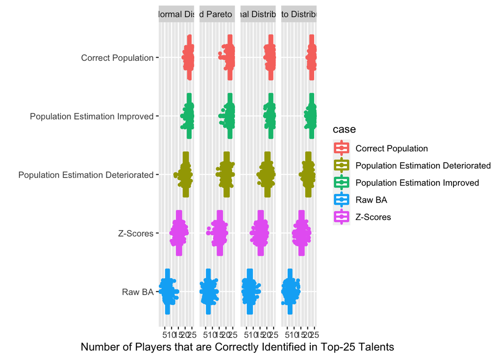

```r
ggplot() + geom_boxplot(data = m_out[1:1000,], mapping = aes(y=V1, x = reorder(case, -rank), color = case), lwd = 1) +
  geom_point(data = m_out[1:1000,], mapping = aes(y=V1, x = case, color = case))  +
  geom_jitter(data = m_out[1:1000,], mapping = aes(y=V1, x = case, color = case), shape=16, position=position_jitter(0.2))  +
  geom_boxplot(data = m_out[1001:2000,], mapping = aes(y=V1, x = case, color = case), lwd = 1) +
  geom_point(data = m_out[1001:2000,], mapping = aes(y=V1, x = case, color = case))  +
  geom_jitter(data = m_out[1001:2000,], mapping = aes(y=V1, x = case, color = case), shape=16, position=position_jitter(0.2)) +
  geom_boxplot(data = m_out[2001:3000,], mapping = aes(y=V1, x = case, color = case), lwd = 1) +
  geom_point(data = m_out[2001:3000,], mapping = aes(y=V1, x = case, color = case))  +
  geom_jitter(data = m_out[2001:3000,], mapping = aes(y=V1, x = case, color = case), shape=16, position=position_jitter(0.2)) +
  geom_boxplot(data = m_out[3001:4000,], mapping = aes(y=V1, x = case, color = case), lwd = 1) +
  geom_point(data = m_out[3001:4000,], mapping = aes(y=V1, x = case, color = case))  +
  geom_jitter(data = m_out[3001:4000,], mapping = aes(y=V1, x = case, color = case), shape=16, position=position_jitter(0.2))  +
  facet_grid(cols = vars(index))+ coord_flip()  +  xlab("") + ylab('Number of Players that are Correctly Identified in Top-25 Talents')
```

## Table 5: Comparsion between deteriorated estimation regime and Z-scores in the paper.

```r
# The probability that incorrect Full House Model beats or ties Schell’s method and strictly beats Schell’s method

m <- rowMeans(apply(out, 1, function(xx){
    c(as.numeric(xx[3] >= xx[4]), as.numeric(xx[8] >= xx[9]), as.numeric(xx[13] >= xx[14]), as.numeric(xx[18] >= xx[19]),
        as.numeric(xx[3] > xx[4]), as.numeric(xx[8] > xx[9]), as.numeric(xx[13] > xx[14]), as.numeric(xx[18] > xx[19]))
}))

n <- as.data.frame(t(matrix(m, nrow = 4)))
colnames(n) <- c('correct Pareto dist', 'incorrect Pareto dist', 'normal dist', 'folded normal dist')
rownames(n) <- c('beat or ties', 'strictly beat')
n
```

```
##               correct Pareto dist incorrect Pareto dist normal dist
## beat or ties                    1                     1       1.000
## strictly beat                   1                     1       0.995
##               folded normal dist
## beat or ties                   1
## strictly beat                  1
```

# Ranking Stability Analysis

By changing the starting year from 1946 to 1995, we obtain 50 bWAR ranking lists for batters and pitchers. These ranking lists are stored in the combined_bp_46_95.RData.

```r
load('combined_bp_46_95.RData')

ranks <- combined_bp[, ((1:50)*2-1)]

## find the starting year that all the top 25 players lie in the
## 10-90 percentile intervals.
for (k in 1:50) {
  n <- rep(0,25)
  for (j in 1:25) {
    m <- rep(0,50)
    for (i in 1:50) {
      m[i] <- which(ranks[,i] == ranks[j,k])
    }
    left <- round(as.numeric(quantile(m, probs = c(0.1, 0.9))[1]))
    right <- round(as.numeric(quantile(m, probs = c(0.1, 0.9))[2]))
    n[j] <- j >= left & j <= right
  }
  if (sum(n) == 25) {
    print(c(k,(1946:1995)[k]))
  }
}
```

```
## [1]   25 1970
## [1]   32 1977
## [1]   34 1979
```

```r
tt <- 32
m <- rep(0,50)
for (i in 1:50) {
  m[i] <- which(ranks[,i] == ranks[1,tt])
}
overlay <- data.frame(name = ranks[1,tt], ct = m,
                      left = as.numeric(quantile(m, probs = c(0.1, 0.9))[1]),
                      right = as.numeric(quantile(m, probs = c(0.1, 0.9))[2]),
                      rank = 1)
for (j in 2:25) {
  m <- rep(0,50)
  for (i in 1:50) {
    m[i] <- which(ranks[,i] == ranks[j,tt])
  }
  overlay <- rbind(overlay, data.frame(name = ranks[j,tt], ct = m,
                                       left = as.numeric(quantile(m, probs = c(0.1, 0.9))[1]),
                                       right = as.numeric(quantile(m, probs = c(0.1, 0.9))[2]),
                                       rank = j))
}

t <- c(1,1)
for (j in 2:25) {
  m <- rep(0,50)
  for (i in 1:50) {
    m[i] <- which(ranks[,i] == ranks[j,tt])
  }
  left <- as.numeric(quantile(m, probs = c(0.1, 0.9))[1])
  right <- as.numeric(quantile(m, probs = c(0.1, 0.9))[2])
  t <- c(t, c(left, right))
}

comb = rep(0,50)
comb[(1:25)*2-1] <- ranks[1:25,tt]
comb[(1:25)*2] <- ranks[1:25,tt]
mm <- data.frame(name = comb,
                 ct = t)
```

## Figure 4: Ranking stability analysis in the paper.

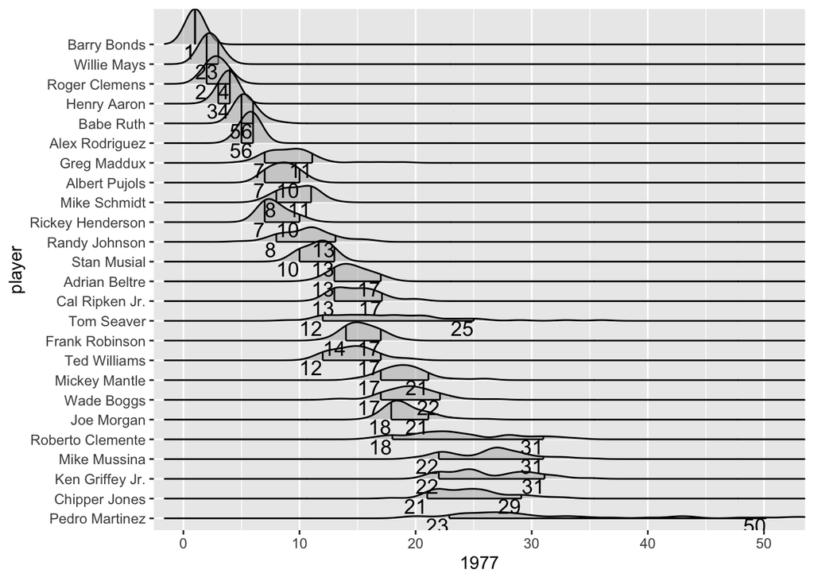

```r
library(ggridges)
ggplot() + stat_density_ridges(data = overlay, aes(y = reorder(name, -rank), x = ct),
                               alpha = 0.5, quantile_lines = TRUE,
                               quantiles = c(0.10, 0.90)) +
  coord_cartesian(xlim = c(0,51)) + geom_line(data = mm, aes(x = ct, y = name)) +
  geom_text(data = mm, aes(x = ct, y = name, label = round(ct)),
            vjust = 1, hjust = 1,
            show.legend = FALSE, size=4.5) + xlab((1946:1995)[tt]) + ylab("player")
```

# Ranking lists using different talent generating process

## Talent distribution follows folded normal distributon

### batters

```r
library(VGAM)
Ftilde <- function(y, t, ystar, component_name){
  y <- sort(y)
  n <- length(y)
  ytilde <- rep(0, n + 1)

  if (component_name == 'bWAR' | component_name == 'fWAR' | component_name == 'ERA') {
    ytilde[1] <- y[1] - (y[2] - y[1])
  }
  if (component_name == 'HR'| component_name == 'BB') {
    # since the minimal HR is greater or equal to 0.
    ytilde[1] <- 0
  }
  if (component_name == 'bWAR_p' | component_name == 'fWAR_p') {
    # since the minimal HR is greater or equal to 0.
    ytilde[1] <- y[1] - (y[2] - y[1])/10
  }
  if (component_name == 'SO') {
    # since the minimal HR is greater or equal to 0.
    ytilde[1] <- ifelse(y[1] - (y[2] - y[1]) < 0, 0, y[1] - (y[2] - y[1]) )
  }

  ytilde[n+1] <- y[n] + ystar
  ytilde[2:n] <- unlist(lapply(2:n, function(j){
    (y[j]+y[j-1])/2
  }))

  if (t >= ytilde[n+1]) {
    1 - 0.1^7
  } else if (t <= ytilde[1]) {
    0
  } else {
    j <- length(which(ytilde < t))
    (j - 1) / n + (t - ytilde[j]) / (n*(ytilde[j+1] - ytilde[j]))
  }

}
talent_computing_nonpara <- function(dataset, component_name, year, ystar, alpha = 1.16){
  # dataset should include the component name and corresponding npop
  Ftilde <- function(y, t, ystar, component_name){
    y <- sort(y)
    n <- length(y)
    ytilde <- rep(0, n + 1)

    if (component_name == 'bWAR' | component_name == 'fWAR') {
      ytilde[1] <- y[1] - (y[2] - y[1])
    }
    if (component_name == 'HR' | component_name == 'BB') {
      # since the minimal HR is greater or equal to 0.
      ytilde[1] <- 0
    }

    ytilde[n+1] <- y[n] + ystar
    ytilde[2:n] <- unlist(lapply(2:n, function(j){
      (y[j]+y[j-1])/2
    }))

    if (t >= ytilde[n+1]) {
      1 - 0.1^7
    } else if (t <= ytilde[1]) {
      0
    } else {
      j <- length(which(ytilde < t))
      (j - 1) / n + (t - ytilde[j]) / (n*(ytilde[j+1] - ytilde[j]))
    }

  }

  Aptitude_nonpara <- function(p, alpha = 1.16, npop){

    # converts order stats to their percentiles
    order_pbino <- function(p = 0, k = 1, n = 1e4){
      pbinom(k - 1, prob = p, size = n, lower.tail = FALSE)
    }

    # converts a vector of order stats
    # to their percentiles. This vector should be the entire
    # sample sorted in increasing order
    p <- sort(p) # just in case
    n <- length(p)
    u = unlist(lapply(1:n, function(j){
      order_pbino(p[j], k = j, n = n)
    }))

    # transforms percentiles from order stats (in increasing order)
    # to Pareto values corresponding to the general population
    # of a greater than or equal to size
    # default alpha is that of the Pareto principle 80-20
    n <- length(u)
    if(length(npop) == 1) npop <- rep(npop, n)
    unlist(lapply(1:n, function(j){
      qfoldnorm(qbeta(u[j], j + npop[j] -n , n + 1 - j), mean = 0, sd = 1)
    }))
  }

  foo <- dataset %>% filter(yearID == year) %>%
    arrange(comp)
  bar <- foo %>% filter(PA >= thres)
  full_comp <- bar$comp
  ## batter WAR talent
  bar <- bar %>%
    mutate(WAR_talent =
             Aptitude_nonpara(p = unlist(lapply(comp, function(xx)
               Ftilde(y = comp, t = xx, ystar = ystar, component_name = component_name))), npop = pops))

  max_WAR_talent <- max(bar$WAR_talent) - 1
  range <- which(!(foo$playerID %in% bar$playerID))

  ## using the distribution from full time players
  bar <- rbind(bar, do.call(rbind, lapply(range, function(j){
    rbind(bar %>% dplyr::select(-WAR_talent), foo[j, ]) %>% arrange(comp) %>%
      mutate(WAR_talent = Aptitude_nonpara(p = unlist(lapply(comp, function(xx)
        Ftilde(y = full_comp, t = xx, ystar = ystar, component_name = component_name))), npop = pops)) %>%
      filter(PA < thres) %>%
      mutate(WAR_talent = ifelse(WAR_talent > max_WAR_talent+1, max_WAR_talent, WAR_talent))
  })))
  bar %>% mutate(ystar = ystar)
}

batters <- read_csv("batters_all.csv") %>% select(yearID, bbID, name, age, PA, G, bWAR,pops)
```

```
## ──────────────────────────────────────────────────────── Delimiter: "," chr
## (3): chadID, bbID, name dbl (21): ...1, fID, yearID, age, G, AB, PA, obs_hits,
## hits, obs_AVG, AVG, o...
```

```r
colnames(batters)[2] <- 'playerID'

cutoff <- do.call(rbind, mclapply(years, mc.cores = ncores, FUN = function(xx){
  m <- batters %>% filter(yearID == xx) %>% filter(PA >= 75)
  data.frame(thres = median(m$PA), yearID = xx)
}))

batters <- merge(batters, cutoff, by = 'yearID')

batters <- batters %>% mutate(comp =  bWAR / G)

## batters bWAR

bat_thres <- function(component, component_name){
  ## stab means we add a small number to the largest value to avoid numerical stability problems.
  ## stab depends on the scale of input values. In most cases, the default is 0.01.
  ## cutoff means we select a certain percentage of systems that include maximal possible components in the tail
  ## rather than include k possible components in the tail based on the adjusted R adjusted square.
  ## If the distance between the largest value and second largest value in the right tail is relatively large,
  ## adjusted R square may not be a good quantity to represent how well the fit is.
  ## Then we usually choose the one sixth of all systems that their distances between the largest value and
  ## second largest value are in the top one sixth.

  if (component_name == 'bWAR') {
    cutoff <- 1.6e-2
    stab <- 0.01
  }
  if (component_name == 'fWAR') {
    cutoff <- 1.75e-2
    stab <- 0.01
  }
  if (component_name == 'HR') {
    cutoff <- 2.06e-2
    stab <- 0.01
  }
  if (component_name == 'BB') {
    cutoff <- 4.05e-2
    stab <- 0.01
  }
  # obtain initial quantities for linear approximation
  Y <- sort(as.matrix(component))
  n <- length(Y)
  Y[n] <- Y[n] + stab # for stability
  pi <- 1 - (n:1 - 1/3)/(n + 1/3)
  W <- log(pi/(1-pi))
  K1 = max(6, floor(1.3*sqrt(n))); K2 = 2*floor(log10(n)*sqrt(n))
  k <- 6

  # use arguments from Scholz section 3 for estimating k
  #
  # this argument is based on model fit and not longest stretch of
  # contiguous I0
  ind <- NULL
  try({
    k_selector <- do.call(rbind, lapply(6:K2, function(k){

      Ytil <- Y - median(Y)
      Ztil <- tail(Ytil, k)
      M1k <- 1/(k-1) * sum( log(Ztil[2:k]/Ztil[1]) )
      M2k <- 1/(k-1) * sum( log(Ztil[2:k]/Ztil[1])^2 )
      ck <- M1k + 1 - 0.5*(1 - M1k^2/M2k)^{-1}
      fck <- ((-n*log(pi))^{-ck} - 1)/ck

      Sigma <- matrix(0, k, k)
      for(i in 1:k){
        for(j in 1:i){
          Sigma[i,j] <- i^{-ck-1} * j^{-ck}
        }
      }
      for(j in 1:k){
        for(i in 1:(j-1)){
          Sigma[i,j] <- j^{-ck-1} * i^{-ck}
        }
      }

      rotate <- function(x) t(apply(x, 2, rev))
      Sigma <- rotate(rotate(Sigma))
      Sigma.inv <-  solve(Sigma)
      eig <- eigen(Sigma.inv)
      C <- eig$vec %*% diag(sqrt(eig$val)) %*% t(eig$vec)
      Zk <- C %*% tail(Y, k)
      Xk <- cbind(1, tail(fck, k))
      Wk <-  C %*% Xk
      # try linear and quadratic model
      m1 <- lm(tail(Y, k) ~ tail(fck, k))
      m2 <- lm(tail(Y, k) ~ tail(fck, k) + I(tail(fck, k)^2))
      m3 <- lm(Zk ~ -1 + Wk)
      delta.sq <- summary(m3)$sigma^2
      Tk <- coef(m3)[2] / summary(m3)$sigma

      kappa.sq <- solve(crossprod(Wk))[2,2]
      kappa <- sqrt(kappa.sq)
      I0 <- c(kappa * qt(0.25, df = k - 2, ncp = 1/kappa),
              kappa * qt(0.75, df = k - 2, ncp = 1/kappa))
      I1 <- c(kappa * qt(0.05, df = k - 2, ncp = 1/kappa),
              kappa * qt(0.95, df = k - 2, ncp = 1/kappa))
      I0int <- ifelse(I0[1] <= Tk && Tk <= I0[2], 1, 0)
      I1int <- ifelse(I1[1] <= Tk && Tk <= I1[2], 1, 0)
      c(k, Tk, I0int, I1int, summary(m1)$adj.r.squared,
        summary(m2)$adj.r.squared)

    }))

    #k <- k_selector[max(which(k_selector[, 3] == 1)), 1]
    #k <- k_selector[which.max(k_selector[, 5]), 1]
    k_selector <- as.data.frame(k_selector)
    colnames(k_selector) <- c("k", "Tk", "I0", "I1", "R.sq", "Rquad.sq")
    k_selector_I0 <- k_selector %>% filter(I0 == 1)
    a <- which.max(k_selector_I0$R.sq)
    b <- which.max(k_selector_I0$Rquad.sq)
    ind <- which.max(c(k_selector_I0[a, ]$R.sq,
                       k_selector_I0[b, ]$Rquad.sq))
    k <- k_selector_I0[c(a,b)[ind] , 1]
    if(diff(Y)[n-1] > cutoff){
      k <- max(k_selector_I0$k)
      if(k < 0) k <- K2
    }

  }, silent = TRUE)

  if(length(k) == 0) k <- round(mean(K1,K2))
  if(is.na(k)) k <- round(mean(K1,K2))
  if(k == 0) k <- round(mean(K1,K2))
  if(k >= n) k <- K2


  # find probability value using linear tail behavior
  Z <- tail(Y, k)
  m1 <- lm(tail(Y, k) ~ tail(pi, k))
  beta <- m1$coefficients
  ystar <- ub <- 0
  f <- function(x) beta[1] + beta[2] * x - max(Y)
  #delta <- beta[2]
  try({
    foo <- uniroot(f, c(0.0001, 5), tol = 1e-10)
    ub <- foo$root
  })

  # find probability value using logistic tail behavior
  if(ub >= 1){
    m1 <- lm(tail(Y,k) ~ tail(W, k))
    beta <- m1$coefficients
    f <- function(x) beta[1] + beta[2] * log(x/(1-x)) - max(Y)
    try({
      foo <- uniroot(f, c(0.000001, 0.999999), tol = 1e-10)
      ub <- foo$root
    })
  }

  # if possible, find ystar by tying logistic behavior argument to
  # our Ftilde function
  if(ub >= Ftilde(y = Y, t = max(Y), ystar = 10, component_name = component_name)){
    try({
      g <- function(ystar) ub - Ftilde(y = Y, t = max(Y), ystar = ystar, component_name = component_name)
      bar <- uniroot(g, c(0, 10), tol = 1e-10)
      ystar <- bar$root
    })
  }

  # if the above is not possible, try a similar approach for different
  # suitable values of k.
  #
  # The above fails because ub < Ftilde(y = Y, t = max(Y), ystar = 10, component_name = component_name)
  # suggesting that the largest achiever is performaing much worse than
  # expected. Thus ystar should be "large". A default large value will
  # be ystar = 6 (altered to be log(1 + 6) for stability). This will
  # be used when all else fails.
  flag <- NULL
  if(ub < Ftilde(y = Y, t = max(Y), ystar = 10, component_name = component_name)){

    # first try for largest suitable k as dictated by Scholz Section 3
    k <- max(k_selector_I0$k)
    m1 <- lm(tail(Y,k) ~ tail(W, k) + I(tail(W, k)^2))
    beta <- m1$coefficients
    f <- function(x) beta[1] + beta[2] * log(x/(1-x)) +
      beta[3] * log(x/(1-x))^2 - max(Y)
    flag <- try({
      foo <- uniroot(f, c(0.0001, 0.9999), tol = 1e-10)
      ub <- foo$root
    }, silent = TRUE)
    while(class(flag) == "try-error"){
      k <- k - 1
      # method fails; use ystar = 4
      if(k < 6){
        ystar <- 6
        break
      }
      m1 <- lm(tail(Y,k) ~ tail(W, k) + I(tail(W, k)^2))
      beta <- m1$coefficients
      f <- function(x) beta[1] + beta[2] * log(x/(1-x)) +
        beta[3] * log(x/(1-x))^2 - max(Y)
      flag <- try({
        foo <- uniroot(f, c(0.0001, 0.9999), tol = 1e-10)
        ub <- foo$root
      }, silent = TRUE)
    }
```

```r
    ystar_1 <- NULL
    try({
      g <- function(ystar) ub - Ftilde(y = Y, t = max(Y), ystar = ystar, component_name = component_name)
      bar <- uniroot(g, c(0, 10), tol = 1e-10)
      ystar_1 <- bar$root
    }, silent = TRUE)
    if(length(ystar_1) == 0) ystar_1 <- 6


    # now try for smallest suitable k as dictated by Scholz Section 3
    k <- min(k_selector_I0$k)
    if(length(k) == 0) k <- 6
    m1 <- lm(tail(Y,k) ~ tail(W, k) + I(tail(W, k)^2))
    beta <- m1$coefficients
    f <- function(x) beta[1] + beta[2] * log(x/(1-x)) +
      beta[3] * log(x/(1-x))^2 - max(Y)
    flag <- try({
      foo <- uniroot(f, c(0.0001, 0.9999), tol = 1e-10)
      ub <- foo$root
    }, silent = TRUE)
    while(class(flag) == "try-error"){
      k <- k + 1
      # method fails; use ystar = 4
      if(k > max(k_selector_I0$k)){
        ystar <- 6
        break
      }
      m1 <- lm(tail(Y,k) ~ tail(W, k) + I(tail(W, k)^2))
      beta <- m1$coefficients
      f <- function(x) beta[1] + beta[2] * log(x/(1-x)) +
        beta[3] * log(x/(1-x))^2 - max(Y)
      flag <- try({
        foo <- uniroot(f, c(0.0001, 0.9999), tol = 1e-10)
        ub <- foo$root
      }, silent = TRUE)
    }

    ystar_2 <- NULL
    try({
      g <- function(ystar) ub - Ftilde(y = Y, t = max(Y), ystar = ystar, component_name = component_name)
      bar <- uniroot(g, c(0, 10), tol = 1e-10)
      ystar_2 <- bar$root
    }, silent = TRUE)
    if(length(ystar_2) == 0) ystar_2 <- 6

    # take ystar as the average of the lowest working k and
    # largest working k
    ystar <- mean(c(ystar_1, ystar_2))

  }

  # if changing k does not work, then try throwing out extreme
  # observations and computing ystar for the reduced sample (Ytil)
  #
  # then compute ystar = max(Y) - max(Ytil) + ystar*
  #
  # where ystar* is computed with respect to Ytil
  if(ystar == 6){
    k <- k_selector_I0[c(a,b)[ind] , 1]
    if(diff(Y)[n-1] > 2){
      k <- max(k_selector_I0$k)
      if(k < 0) k <- K2
    }
    if(length(k) == 0) k <- round(mean(K1,K2))
    if(is.na(k)) k <- round(mean(K1,K2))
    if(k == 0) k <- round(mean(K1,K2))
    if(k >= n) k <- K2

    m1 <- lm(tail(Y, k) ~ tail(W, k) + I(tail(W, k)^2))
    beta <- m1$coefficients
    f <- function(x) beta[1] + beta[2] * log(x/(1-x)) +
      beta[3] * log(x/(1-x))^2 - max(Y)
    flag <- flag2 <- try({
      foo <- uniroot(f, c(0.0001, 0.9999), tol = 1e-10)
      ub <- foo$root
    }, silent = TRUE)

    n_lwr <- n
    Ytil <- Y
    Xtil <- 1 - (n_lwr:1 - 1/3)/(n_lwr + 1/3)
    Wtil <- log(Xtil/(1-Xtil))
    while(class(flag) == "try-error" | class(flag2) == "try-error"){
      Ytil <- Ytil[-n_lwr]
      if(any(tail(Ytil, k) < 0)){
        ystar <- 6
        break
      }
      n_lwr <- n_lwr - 1
      Xtil <- 1 - (n_lwr:1 - 1/3)/(n_lwr + 1/3)
      Wtil <- log(Xtil/(1-Xtil))
      m2 <- lm(tail(Ytil, k) ~ tail(Wtil, k) + I(tail(Wtil, k)^2))
      beta <- m2$coefficients
      f <- function(x) beta[1] + beta[2] * log(x/(1-x)) +
        beta[3] * log(x/(1-x))^2 - max(Ytil)
      flag <- try({
        foo <- uniroot(f, c(0.0001, 0.9999), tol = 1e-10)
        ub <- foo$root
      }, silent = TRUE)
      flag2 <- try({
        g <- function(ystar) ub - Ftilde(y = Ytil, t = max(Ytil), ystar = ystar, component_name = component_name)
        bar <- uniroot(g, c(0, 10), tol = 1e-10)
        ystar <- bar$root
      }, silent = TRUE)
    }
    ystar <- max(Y) - Y[n_lwr] + ystar

  }

  # for stability
  ystar <- log(1 + ystar)
  ystar

}

batters_talent_bWAR <- do.call(rbind, mclapply(years, mc.cores = ncores, function(yy){
  talent_computing_nonpara(dataset = batters, component_name = "bWAR", year = yy,
                           ystar = bat_thres(component = batters %>% filter(PA >= thres, yearID == yy) %>%
                                               select(comp), component_name = 'bWAR'))
})) %>% arrange(-WAR_talent)

career_talent <- function(dataset, component_name, snippet, start_year){
  Rev_Aptitude_nonpara <- function(x, ytilde, alpha = 1.16, npop){

    # transforms ordered Pareto values corresponding to
    # the general population to percentiles from order stats
    # (in increasing order)
    n <- length(x)
    if(length(npop) == 1) npop <- rep(npop, n)
    u = unlist(lapply(1:n, function(j){
      pbeta(pfoldnorm(x[j], mean = 0, sd = 1), j + npop[j]-n, n + 1 - j)
    }))


    ## map the quantile to the a predicated sample value
    map_Y <- function(u, ytilde){
      n <- length(ytilde)-1
      seqence <- seq(0, 1, 1/n)
      pos <- findInterval(u, seqence)
      out <- (n*u -pos + 1) * (ytilde[(pos+1)] - ytilde[pos]) + ytilde[pos]
      return(out)
    }

    ## map the vector of quantiles to the predicated sample values
    n <- length(u)
    a <- qbeta(u, shape1 = 1:n, shape2 = n:1)
    out <- sapply(1:n, function(x) map_Y(a[x], ytilde = ytilde))
    out

  }

  min_year <- min(snippet$yearID)
  max_year <- max(snippet$yearID)
  end_year <- max_year - min_year + start_year
  end_year <- ifelse(end_year <= 2021, end_year, 2021)

  snippet <- snippet %>% mutate(playerID = paste(playerID, "_proj", sep = ""))
  do.call(rbind, lapply(start_year : end_year, function(xx){
    batters_int <- dataset %>% filter(yearID == xx, PA >= thres)

    target_snippet <- snippet %>% filter(yearID == (xx - start_year + min_year))
    yy <- sort(batters_int$comp)
    n <- length(yy)
    ytilde <- rep(0, n + 1)
    if (component_name == 'bWAR' | component_name == 'fWAR') {
      ytilde[1] <- yy[1] - (yy[2] - yy[1])
    }
    if (component_name == 'HR' | component_name == 'BB') {
      # since the minimal HR is greater or equal to 0.
      ytilde[1] <- 0
    }
    ytilde[n+1] <- yy[n] + unique(batters_int$ystar)
    ytilde[2:n] <- unlist(lapply(2:n, function(j){
      (yy[j]+yy[j-1])/2
    }))

    batters_int <- rbind(batters_int, target_snippet)
    batters_int$pops[nrow(batters_int)] <- batters_int$pops[1]
    batters_int <- batters_int %>% arrange(WAR_talent) %>%
      mutate(adj_comp = Rev_Aptitude_nonpara(WAR_talent, ytilde = ytilde, npop = pops)) %>%
      filter(playerID == unique(snippet$playerID))
    batters_int %>% mutate(ref_year = xx)
  }))
```

```r
}
foo <- batters_talent_bWAR
foo$playerID <- droplevels(as.factor(foo$playerID))

mapped_quan_b <- read.csv('mapped_quan_b.csv')[,-1]

mapped_cutoff <- cutoff
colnames(mapped_cutoff) <- c('PA_thres', 'ref_year')

ss = 1977

career_kAB <- do.call(rbind, mclapply(unique(foo$playerID), function(zz){
    int <- career_talent(dataset = foo, component_name = 'bWAR', snippet = foo %>% filter(playerID == zz),
                         start_year = ss)
    int
  }, mc.cores = ncores))

  career_kAB <- career_kAB %>% mutate(playerID = gsub('.{5}$', '', playerID))

  mapped_batters_1 <- merge(career_kAB, mapped_quan_b,
                            by = c('playerID', 'yearID', 'ref_year'))

  mapped_batters_2 <- merge(mapped_batters_1, mapped_cutoff,
                            by = c('ref_year'))

  mapped_batters_3 <- mapped_batters_2 %>% mutate(adj_bWAR = adj_comp * mapped_G)

  min_refbWAR <- do.call(rbind, mclapply(years, function(zz){
    m <- mapped_batters_3 %>% filter(yearID == zz, PA >= thres)
    data.frame(ref_year = zz, min_bWAR = min(m$bWAR))
  }, mc.cores = ncores))

  mapped_batters <- merge(mapped_batters_3, min_refbWAR,
                          by = c('ref_year'))

  career_kAB_trim <- do.call(rbind, mclapply(
    split(mapped_batters, f = droplevels(as.factor(mapped_batters$playerID))),
    mc.cores = ncores, FUN = function(xx){
      zz <- xx %>% filter(PA < thres) %>%
        mutate(adj_bWAR = (1 - mapped_PA/PA_thres) * bWAR + mapped_PA/PA_thres * (adj_bWAR))
      tt <- xx %>% filter(PA >= thres)
      xx <- rbind(zz, tt) %>% arrange(yearID)

      m1 <- xx %>% filter(adj_bWAR < min_bWAR) %>%
        mutate(adj_bWAR = min_bWAR) %>%
        mutate(mapped_G = adj_bWAR / adj_comp)
      m2 <- xx %>% filter(adj_bWAR >= min_bWAR)
      rbind(m1, m2) %>% arrange(yearID)

    }))

  career_kAB_trim_select <- career_kAB_trim %>%
    select(name, playerID, yearID, adj_bWAR, bWAR, ref_year)

  library(splines)
  smoothed_bWAR <- do.call(rbind, mclapply(
    split(career_kAB_trim_select,
          f = droplevels(as.factor(career_kAB_trim_select$playerID))),
    mc.cores = ncores, FUN = function(xx){
      ## natural cubic spline
      ns_bWAR = lm(adj_bWAR ~ ns(yearID, df=6), data=xx)
      nn_bWAR <- predict(ns_bWAR, data.frame("yearID"= xx$yearID))
      xx %>% mutate(ss_adj_bWAR = nn_bWAR) %>%
        mutate(avg_bWAR = (ss_adj_bWAR + adj_bWAR)/2)
    }))

  career_fold_b <- do.call(rbind, mclapply(split(smoothed_bWAR,f = droplevels(as.factor(smoothed_bWAR$playerID))), mc.cores = ncores, FUN = function(xx){
    data.frame(name = unique(xx$name),
               playerID = unique(xx$playerID),
               rookie_year = min(xx$yearID),
               avg_bWAR = sum(xx$avg_bWAR),
               bWAR = sum(xx$bWAR), ref_year = nrow(xx))
    })) %>% arrange(desc(avg_bWAR))
  rownames(career_fold_b) <- c()
```

### pitchers

```r
pitchers <- read_csv("pitchers_all.csv") %>% select(yearID, bbID, name, teamID, IP, bWAR, pops)
```

```
## ──────────────────────────────────────────────────────── Delimiter: "," chr
## (5): chadID, bbID, name, lgID, teamID dbl (19): ...1, fID, age, yearID, IP, SO,
## BB, HBP, obs_ER, ER_PF, obs_HR, HR...
```

```r
pitchers <- pitchers %>% mutate(comp = bWAR / IP)
pitchers$comp[is.na(pitchers$comp)] = 0
colnames(pitchers)[2] <- 'playerID'

library(retrosheet)
rotation_bound <- as.data.frame(cbind(years, unlist(mclapply(years, mc.cores = ncores, function(yr){
  foo <- getRetrosheet(type = "game", year = yr)
  Tms <- unique(foo$HmTm)

  starter <- lapply(Tms, function(tm){
    bar <- foo %>% filter(VisTm == tm | HmTm == tm) %>%
      select(VisTm, HmTm, VisStPchID, HmStPchID, VisTmGNum, HmTmGNum)
    t(apply(bar, 1, function(xx){
      y <- NULL
      if(xx[2] == tm){
        y <- xx[4]
      }
      else{
        y <- xx[3]
      }
    }))
  })

  y <- unlist(lapply(starter, function(xx){
    unlist(lapply(1:length(xx), function(j){
      flag <- TRUE
      k <- 1
      if(j > 1){
        while(flag){
          flag <- length(xx[(j-k):j]) == length(unique(xx[(j-k):j]))
          if(!flag){
            break
          }
          else{
            k <- k + 1
          }
          if(k == j){
            break
          }
        }
      }
      k
    }))
  }))
  mean(y)

}))))

unique_team <- do.call(rbind, mclapply(years, mc.cores = ncores, FUN = function(xx){
  c(xx, nrow(unique(pitchers %>% filter(yearID == xx) %>% select(teamID))))
}))

rotation_player <- data.frame(yearID = years, rotation = ceiling(rotation_bound[,2] * unique_team[,2]))

cutoff <- do.call(rbind, mclapply(years, mc.cores = ncores, FUN = function(xx){
  m <- pitchers %>% filter(yearID == xx) %>% arrange(-IP)
  index <- rotation_player$rotation[rotation_player$yearID == xx]
  data.frame(thres = (m$IP[index]), yearID = xx)
}))

pitchers <- merge(pitchers, cutoff, by = 'yearID')
pitchers <- pitchers %>% mutate(full_time = ifelse(IP >= thres, 'Y', 'N'))
Ftilde <- function(y, t, ystar, component_name){
  y <- sort(y)
  n <- length(y)
  ytilde <- rep(0, n + 1)

  if (component_name == 'bWAR' | component_name == 'fWAR' | component_name == 'ERA') {
    ytilde[1] <- y[1] - (y[2] - y[1])
  }
  if (component_name == 'HR'| component_name == 'BB') {
    # since the minimal HR is greater or equal to 0.
    ytilde[1] <- 0
  }
  if (component_name == 'bWAR_p' | component_name == 'fWAR_p') {
    # since the minimal HR is greater or equal to 0.
    ytilde[1] <- y[1] - (y[2] - y[1])/10
  }
  if (component_name == 'SO') {
    # since the minimal HR is greater or equal to 0.
    ytilde[1] <- ifelse(y[1] - (y[2] - y[1]) < 0, 0, y[1] - (y[2] - y[1]) )
  }

  ytilde[n+1] <- y[n] + ystar
  ytilde[2:n] <- unlist(lapply(2:n, function(j){
    (y[j]+y[j-1])/2
  }))

  if (t >= ytilde[n+1]) {
    1 - 0.1^7
  } else if (t <= ytilde[1]) {
    0
  } else {
    j <- length(which(ytilde < t))
    (j - 1) / n + (t - ytilde[j]) / (n*(ytilde[j+1] - ytilde[j]))
  }

}

talent_computing_nonpara <- function(dataset, component_name, year, ystar, alpha = 1.16){
  # dataset should include the component name and corresponding npop
  Ftilde <- function(y, t, ystar, component_name){
    y <- sort(y)
    n <- length(y)
    ytilde <- rep(0, n + 1)

    if (component_name == 'ERA') {
      ytilde[1] <- y[1] - (y[2] - y[1])
    }
    if (component_name == 'bWAR_p' | component_name == 'fWAR_p') {
      # since the minimal HR is greater or equal to 0.
      ytilde[1] <- y[1] - (y[2] - y[1])/10
    }
    if (component_name == 'SO') {
      ytilde[1] <- ifelse(y[1] - (y[2] - y[1]) < 0, 0, y[1] - (y[2] - y[1]) )
    }

    ytilde[n+1] <- y[n] + ystar
    ytilde[2:n] <- unlist(lapply(2:n, function(j){
      (y[j]+y[j-1])/2
    }))

    if (t >= ytilde[n+1]) {
      1 - 0.1^7
    } else if (t <= ytilde[1]) {
      0
    } else {
      j <- length(which(ytilde < t))
      (j - 1) / n + (t - ytilde[j]) / (n*(ytilde[j+1] - ytilde[j]))
    }

  }

  Aptitude_nonpara <- function(p, alpha = 1.16, npop){

    # converts order stats to their percentiles
    order_pbino <- function(p = 0, k = 1, n = 1e4){
      pbinom(k - 1, prob = p, size = n, lower.tail = FALSE)
    }

    # converts a vector of order stats
    # to their percentiles. This vector should be the entire
    # sample sorted in increasing order
    p <- sort(p) # just in case
    n <- length(p)
    u = unlist(lapply(1:n, function(j){
      order_pbino(p[j], k = j, n = n)
    }))

    # transforms percentiles from order stats (in increasing order)
    # to Pareto values corresponding to the general population
    # of a greater than or equal to size
    # default alpha is that of the Pareto principle 80-20
    n <- length(u)
    if(length(npop) == 1) npop <- rep(npop, n)
    unlist(lapply(1:n, function(j){
      qfoldnorm(qbeta(u[j], j + npop[j] -n , n + 1 - j), mean = 1, sd = 1)
    }))
  }

  foo <- dataset %>% filter(yearID == year) %>%
    arrange(comp)
  bar <- foo %>% filter(full_time == 'Y')
  full_comp <- bar$comp
  ## batter WAR talent
  bar <- bar %>%
    mutate(WAR_talent =
             Aptitude_nonpara(p = unlist(lapply(comp, function(xx)
               Ftilde(y = comp, t = xx, ystar = ystar, component_name = component_name))), npop = pops))

  max_WAR_talent <- max(bar$WAR_talent) - 1
  range <- which(!(foo$playerID %in% bar$playerID))

  ## using the distribution from full time players
  bar <- rbind(bar, do.call(rbind, lapply(range, function(j){
    rbind(bar %>% dplyr::select(-WAR_talent), foo[j, ]) %>% arrange(comp) %>%
      mutate(WAR_talent = Aptitude_nonpara(p = unlist(lapply(comp, function(xx)
        Ftilde(y = full_comp, t = xx, ystar = ystar, component_name = component_name))), npop = pops)) %>%
      filter(full_time == 'N') %>%
      mutate(WAR_talent = ifelse(WAR_talent > max_WAR_talent+1, max_WAR_talent, WAR_talent))
  })))
  bar %>% mutate(ystar = ystar)
}

pit_thres <- function(component, component_name){
  if (component_name == 'ERA') {
    cutoff <- 0.47
    stab <- 0.2
  }
  if (component_name == 'bWAR_p') {
    cutoff <- 8e-3
    stab <- 0.01
  }
  if (component_name == 'fWAR_p') {
    cutoff <- 5.7e-3
    stab <- 0.01
  }
  if (component_name == 'SO') {
    cutoff <- 1.56
    stab <- 0.2
  }
  # obtain initial quantities for linear approximation
  Y <- sort(as.matrix(component))
  n <- length(Y)
  Y[n] <- Y[n] + stab # for stability
  pi <- 1 - (n:1 - 1/3)/(n + 1/3)
  W <- log(pi/(1-pi))
  K1 = max(6, floor(1.3*sqrt(n))); K2 = 2*floor(log10(n)*sqrt(n))
  k <- 6
```

```r
  # use arguments from Scholz section 3 for estimating k
  #
  # this argument is based on model fit and not longest stretch of
  # contiguous I0
  ind <- NULL
  try({
    k_selector <- do.call(rbind, lapply(6:K2, function(k){

      Ytil <- Y - median(Y)
      Ztil <- tail(Ytil, k)
      M1k <- 1/(k-1) * sum( log(Ztil[2:k]/Ztil[1]) )
      M2k <- 1/(k-1) * sum( log(Ztil[2:k]/Ztil[1])^2 )
      ck <- M1k + 1 - 0.5*(1 - M1k^2/M2k)^{-1}
      fck <- ((-n*log(pi))^{-ck} - 1)/ck

      Sigma <- matrix(0, k, k)
      for(i in 1:k){
        for(j in 1:i){
          Sigma[i,j] <- i^{-ck-1} * j^{-ck}
        }
      }
      for(j in 1:k){
        for(i in 1:(j-1)){
          Sigma[i,j] <- j^{-ck-1} * i^{-ck}
        }
      }

      rotate <- function(x) t(apply(x, 2, rev))
      Sigma <- rotate(rotate(Sigma))
      Sigma.inv <-  solve(Sigma)
      eig <- eigen(Sigma.inv)
      C <- eig$vec %*% diag(sqrt(eig$val)) %*% t(eig$vec)
      Zk <- C %*% tail(Y, k)
      Xk <- cbind(1, tail(fck, k))
      Wk <-  C %*% Xk
      # try linear and quadratic model
      m1 <- lm(tail(Y, k) ~ tail(fck, k))
      m2 <- lm(tail(Y, k) ~ tail(fck, k) + I(tail(fck, k)^2))
      m3 <- lm(Zk ~ -1 + Wk)
      delta.sq <- summary(m3)$sigma^2
      Tk <- coef(m3)[2] / summary(m3)$sigma

      kappa.sq <- solve(crossprod(Wk))[2,2]
      kappa <- sqrt(kappa.sq)
      I0 <- c(kappa * qt(0.25, df = k - 2, ncp = 1/kappa),
              kappa * qt(0.75, df = k - 2, ncp = 1/kappa))
      I1 <- c(kappa * qt(0.05, df = k - 2, ncp = 1/kappa),
              kappa * qt(0.95, df = k - 2, ncp = 1/kappa))
      I0int <- ifelse(I0[1] <= Tk && Tk <= I0[2], 1, 0)
      I1int <- ifelse(I1[1] <= Tk && Tk <= I1[2], 1, 0)
      c(k, Tk, I0int, I1int, summary(m1)$adj.r.squared,
        summary(m2)$adj.r.squared)

    }))

    #k <- k_selector[max(which(k_selector[, 3] == 1)), 1]
    #k <- k_selector[which.max(k_selector[, 5]), 1]
    k_selector <- as.data.frame(k_selector)
    colnames(k_selector) <- c("k", "Tk", "I0", "I1", "R.sq", "Rquad.sq")
    k_selector_I0 <- k_selector %>% filter(I0 == 1)
    a <- which.max(k_selector_I0$R.sq)
    b <- which.max(k_selector_I0$Rquad.sq)
    ind <- which.max(c(k_selector_I0[a, ]$R.sq,
                       k_selector_I0[b, ]$Rquad.sq))
    k <- k_selector_I0[c(a,b)[ind] , 1]
    if(diff(Y)[n-1] > cutoff){
      k <- max(k_selector_I0$k)
      if(k < 0) k <- K2
    }

  }, silent = TRUE)

  if(length(k) == 0) k <- round(mean(K1,K2))
  if(is.na(k)) k <- round(mean(K1,K2))
  if(k == 0) k <- round(mean(K1,K2))
  if(k >= n) k <- K2


  # find probability value using linear tail behavior
  Z <- tail(Y, k)
  m1 <- lm(tail(Y, k) ~ tail(pi, k))
  beta <- m1$coefficients
  ystar <- ub <- 0
  f <- function(x) beta[1] + beta[2] * x - max(Y)
  #delta <- beta[2]
  try({
    foo <- uniroot(f, c(0.0001, 5), tol = 1e-10)
    ub <- foo$root
  })

  # find probability value using logistic tail behavior
  if(ub >= 1){
    m1 <- lm(tail(Y,k) ~ tail(W, k))
    beta <- m1$coefficients
    f <- function(x) beta[1] + beta[2] * log(x/(1-x)) - max(Y)
    try({
      foo <- uniroot(f, c(0.000001, 0.999999), tol = 1e-10)
      ub <- foo$root
    })
  }

  # if possible, find ystar by tying logistic behavior argument to
  # our Ftilde function
  if(ub >= Ftilde(y = Y, t = max(Y), ystar = 10, component_name = component_name)){
    try({
      g <- function(ystar) ub - Ftilde(y = Y, t = max(Y), ystar = ystar, component_name = component_name)
      bar <- uniroot(g, c(0, 10), tol = 1e-10)
      ystar <- bar$root
    })
  }

  # if the above is not possible, try a similar approach for different
  # suitable values of k.
  #
  # The above fails because ub < Ftilde(y = Y, t = max(Y), ystar = 10, component_name = component_name)
  # suggesting that the largest achiever is performaing much worse than
  # expected. Thus ystar should be "large". A default large value will
  # be ystar = 6 (altered to be log(1 + 6) for stability). This will
  # be used when all else fails.
  flag <- NULL
  if(ub < Ftilde(y = Y, t = max(Y), ystar = 10, component_name = component_name)){

    # first try for largest suitable k as dictated by Scholz Section 3
    k <- max(k_selector_I0$k)
    m1 <- lm(tail(Y,k) ~ tail(W, k) + I(tail(W, k)^2))
    beta <- m1$coefficients
    f <- function(x) beta[1] + beta[2] * log(x/(1-x)) +
      beta[3] * log(x/(1-x))^2 - max(Y)
    flag <- try({
      foo <- uniroot(f, c(0.0001, 0.9999), tol = 1e-10)
      ub <- foo$root
    }, silent = TRUE)
    while(class(flag) == "try-error"){
      k <- k - 1
      # method fails; use ystar = 4
      if(k < 6){
        ystar <- 6
        break
      }
      m1 <- lm(tail(Y,k) ~ tail(W, k) + I(tail(W, k)^2))
      beta <- m1$coefficients
      f <- function(x) beta[1] + beta[2] * log(x/(1-x)) +
        beta[3] * log(x/(1-x))^2 - max(Y)
      flag <- try({
        foo <- uniroot(f, c(0.0001, 0.9999), tol = 1e-10)
        ub <- foo$root
      }, silent = TRUE)
    }

    ystar_1 <- NULL
    try({
      g <- function(ystar) ub - Ftilde(y = Y, t = max(Y), ystar = ystar, component_name = component_name)
      bar <- uniroot(g, c(0, 10), tol = 1e-10)
      ystar_1 <- bar$root
    }, silent = TRUE)
    if(length(ystar_1) == 0) ystar_1 <- 6


    # now try for smallest suitable k as dictated by Scholz Section 3
    k <- min(k_selector_I0$k)
    if(length(k) == 0) k <- 6
    m1 <- lm(tail(Y,k) ~ tail(W, k) + I(tail(W, k)^2))
    beta <- m1$coefficients
    f <- function(x) beta[1] + beta[2] * log(x/(1-x)) +
      beta[3] * log(x/(1-x))^2 - max(Y)
    flag <- try({
      foo <- uniroot(f, c(0.0001, 0.9999), tol = 1e-10)
      ub <- foo$root
    }, silent = TRUE)
    while(class(flag) == "try-error"){
      k <- k + 1
      # method fails; use ystar = 4
      if(k > max(k_selector_I0$k)){
        ystar <- 6
        break
      }
      m1 <- lm(tail(Y,k) ~ tail(W, k) + I(tail(W, k)^2))
      beta <- m1$coefficients
      f <- function(x) beta[1] + beta[2] * log(x/(1-x)) +
        beta[3] * log(x/(1-x))^2 - max(Y)
      flag <- try({
        foo <- uniroot(f, c(0.0001, 0.9999), tol = 1e-10)
        ub <- foo$root
      }, silent = TRUE)
    }
```

```r
    ystar_2 <- NULL
    try({
      g <- function(ystar) ub - Ftilde(y = Y, t = max(Y), ystar = ystar, component_name = component_name)
      bar <- uniroot(g, c(0, 10), tol = 1e-10)
      ystar_2 <- bar$root
    }, silent = TRUE)
    if(length(ystar_2) == 0) ystar_2 <- 6

    # take ystar as the average of the lowest working k and
    # largest working k
    ystar <- mean(c(ystar_1, ystar_2))

  }

  # if changing k does not work, then try throwing out extreme
  # observations and computing ystar for the reduced sample (Ytil)
  #
  # then compute ystar = max(Y) - max(Ytil) + ystar*
  #
  # where ystar* is computed with respect to Ytil
  if(ystar == 6){
    k <- k_selector_I0[c(a,b)[ind] , 1]
    if(diff(Y)[n-1] > 2){
      k <- max(k_selector_I0$k)
      if(k < 0) k <- K2
    }
    if(length(k) == 0) k <- round(mean(K1,K2))
    if(is.na(k)) k <- round(mean(K1,K2))
    if(k == 0) k <- round(mean(K1,K2))
    if(k >= n) k <- K2

    m1 <- lm(tail(Y, k) ~ tail(W, k) + I(tail(W, k)^2))
    beta <- m1$coefficients
    f <- function(x) beta[1] + beta[2] * log(x/(1-x)) +
      beta[3] * log(x/(1-x))^2 - max(Y)
    flag <- flag2 <- try({
      foo <- uniroot(f, c(0.0001, 0.9999), tol = 1e-10)
      ub <- foo$root
    }, silent = TRUE)

    n_lwr <- n
    Ytil <- Y
    Xtil <- 1 - (n_lwr:1 - 1/3)/(n_lwr + 1/3)
    Wtil <- log(Xtil/(1-Xtil))
    while(class(flag) == "try-error" | class(flag2) == "try-error"){
      Ytil <- Ytil[-n_lwr]
      if(any(tail(Ytil, k) < 0)){
        ystar <- 6
        break
      }
      n_lwr <- n_lwr - 1
      Xtil <- 1 - (n_lwr:1 - 1/3)/(n_lwr + 1/3)
      Wtil <- log(Xtil/(1-Xtil))
      m2 <- lm(tail(Ytil, k) ~ tail(Wtil, k) + I(tail(Wtil, k)^2))
      beta <- m2$coefficients
      f <- function(x) beta[1] + beta[2] * log(x/(1-x)) +
        beta[3] * log(x/(1-x))^2 - max(Ytil)
      flag <- try({
        foo <- uniroot(f, c(0.0001, 0.9999), tol = 1e-10)
        ub <- foo$root
      }, silent = TRUE)
      flag2 <- try({
        g <- function(ystar) ub - Ftilde(y = Ytil, t = max(Ytil), ystar = ystar, component_name = component_name)
        bar <- uniroot(g, c(0, 10), tol = 1e-10)
        ystar <- bar$root
      }, silent = TRUE)
    }
    ystar <- max(Y) - Y[n_lwr] + ystar

  }

  # for stability
  ystar <- log(1 + ystar)
  ystar

}

pitchers_talent_bWAR <- do.call(rbind, mclapply(years, mc.cores = ncores, function(yy){
  talent_computing_nonpara(dataset = pitchers, component_name = "bWAR_p", year = yy,
                           ystar = pit_thres(component = pitchers %>%
                                               filter(full_time =='Y', yearID == yy) %>%
                                               select(comp), component_name = 'bWAR_p'))
})) %>% arrange(-WAR_talent)

mapped_quan_p <- read.csv('mapped_quan_p.csv')[,-1]
rotation_talent <- read.csv('rotation_talent_folded.csv')[,-1]

career_talent <- function(dataset, component_name, snippet, start_year){
  Rev_Aptitude_nonpara <- function(x, ytilde, alpha = 1.16, npop){

    # transforms ordered Pareto values corresponding to
    # the general population to percentiles from order stats
    # (in increasing order)
    n <- length(x)
    if(length(npop) == 1) npop <- rep(npop, n)
    u = unlist(lapply(1:n, function(j){
      pbeta(pfoldnorm(x[j], mean = 1, sd = 1), j + npop[j]-n, n + 1 - j)
    }))


    ## map the quantile to the a predicated sample value
    map_Y <- function(u, ytilde){
      n <- length(ytilde)-1
      seqence <- seq(0, 1, 1/n)
      pos <- findInterval(u, seqence)
      out <- (n*u -pos + 1) * (ytilde[(pos+1)] - ytilde[pos]) + ytilde[pos]
      return(out)
    }

    ## map the vector of quantiles to the predicated sample values
    n <- length(u)
    a <- qbeta(u, shape1 = 1:n, shape2 = n:1)
    out <- sapply(1:n, function(x) map_Y(a[x], ytilde = ytilde))
    out

  }

  snippet <- snippet %>% mutate(playerID = paste(playerID, "_proj", sep = ""))

  do.call(rbind, lapply(snippet$ref_year, function(xx){
    pitchers_int <- dataset %>% filter(yearID == xx, full_time == 'Y')

    target_snippet <- snippet %>% filter(ref_year == xx)
    yy <- sort(pitchers_int$comp)
    n <- length(yy)
    ytilde <- rep(0, n + 1)
    if (component_name == 'ERA') {
      ytilde[1] <- yy[1] - (yy[2] - yy[1])
    }
    if (component_name == 'bWAR_p'| component_name == 'fWAR_p') {
      ytilde[1] <- yy[1] - (yy[2] - yy[1])/10
    }
    if (component_name == 'SO') {
      ytilde[1] <- ifelse(yy[1] - (yy[2] - yy[1]) < 0, 0, yy[1] - (yy[2] - yy[1]) )
    }
    ytilde[n+1] <- yy[n] + unique(pitchers_int$ystar)
    ytilde[2:n] <- unlist(lapply(2:n, function(j){
      (yy[j]+yy[j-1])/2
    }))

    pitchers_int <- rbind(pitchers_int, target_snippet)
    pitchers_int$pops[nrow(pitchers_int)] <- pitchers_int$pops[1]
    pitchers_int <- pitchers_int %>% arrange(WAR_talent) %>%
      mutate(adj_comp = Rev_Aptitude_nonpara(WAR_talent, ytilde = ytilde, npop = pops)) %>%
      filter(playerID == unique(snippet$playerID))

    pitchers_int
  }))
}

yy = 1977

foo_1 <- do.call(rbind, mclapply(unique(pitchers_talent_bWAR$playerID), function(xx){
    m <- pitchers_talent_bWAR %>% filter(playerID == xx) %>%
      select(-WAR_talent) %>% mutate(ref_year = yearID + yy - min(yearID))
    m
  }, mc.cores = ncores))

  foo <- merge(foo_1, rotation_talent, by = c('yearID', 'playerID', 'ref_year'))

  # get career adjustment on season by season basis
  career_kAB <- do.call(rbind, mclapply(unique(foo$playerID), function(xx){
    int <- career_talent(dataset = foo, component_name = 'bWAR_p',
                         snippet = foo %>% filter(playerID == xx), start_year = yy)
    int
  }, mc.cores = ncores))

  career_kAB <- career_kAB %>%
    mutate(playerID = gsub('.{5}$', '', playerID))

  mapped_pitchers_1 <- merge(career_kAB, mapped_quan_p,
                             by = c('playerID', 'yearID', 'ref_year'))

  mapped_cutoff <- cutoff
  colnames(mapped_cutoff) <- c('IP_thres', 'ref_year')

  mapped_pitchers_2 <- merge(mapped_pitchers_1, mapped_cutoff, by = c('ref_year'))
```

```r
  mapped_pitchers_3 <- mapped_pitchers_2 %>% mutate(adj_bWAR = adj_comp * mapped_IP)

  min_refbWAR <- do.call(rbind, mclapply(years, function(zz){
    m <- mapped_pitchers_2 %>% filter(yearID == zz, full_time == 'Y')
    data.frame(ref_year = zz, min_bWAR = min(m$bWAR))
  }, mc.cores = ncores))

  mapped_pitchers <- merge(mapped_pitchers_3, min_refbWAR,
                           by = c('ref_year'))

  career_kAB_trim <- do.call(rbind, mclapply(
    split(mapped_pitchers, f = droplevels(as.factor(mapped_pitchers$playerID))),
    mc.cores = ncores, FUN = function(xx){
      zz <- xx %>% filter(full_time == 'N') %>%
        mutate(adj_bWAR = (1 - mapped_IP/IP_thres) * bWAR + mapped_IP/IP_thres * (adj_bWAR))
      tt <- xx %>% filter(full_time == 'Y')
      xx <- rbind(zz, tt) %>% arrange(yearID)

      m1 <- xx %>% filter(adj_bWAR < min_bWAR) %>%
        mutate(adj_bWAR = min_bWAR) %>%
        mutate(mapped_IP = adj_bWAR / adj_comp)
      m2 <- xx %>% filter(adj_bWAR >= min_bWAR)
      rbind(m1, m2) %>% arrange(yearID)
    }))

  career_kAB_trim_select <- career_kAB_trim %>%
    select(name, playerID, yearID, adj_bWAR, bWAR, ref_year)

  library(splines)
  smoothed_bWAR <- do.call(rbind, mclapply(
    split(career_kAB_trim_select,
          f = droplevels(as.factor(career_kAB_trim_select$playerID))),
    mc.cores = ncores, FUN = function(xx){
      ## natural cubic spline
      ns_bWAR = lm(adj_bWAR ~ ns(yearID, df=6), data=xx)
      nn_bWAR <- predict(ns_bWAR, data.frame("yearID"= xx$yearID))
      xx %>% mutate(ss_adj_bWAR = nn_bWAR)%>%
        mutate(avg_bWAR = (ss_adj_bWAR + adj_bWAR)/2)
    }))

  career_fold_p <- do.call(rbind, mclapply(split(smoothed_bWAR,f = droplevels(as.factor(smoothed_bWAR$playerID))),mc.cores = ncores, FUN = function(xx){
    data.frame(name = unique(xx$name),
               playerID = unique(xx$playerID),
               rookie_year = min(xx$yearID),
               avg_bWAR = sum(xx$avg_bWAR),
               bWAR = sum(xx$bWAR),
               span = nrow(xx))
    })) %>% arrange(desc(avg_bWAR))

  rownames(career_fold_p) <- c()
```

```r
m_b <- career_fold_b %>%
  select(name, playerID, avg_bWAR, rookie_year)

m_p <- career_fold_p %>%
  select(name, playerID, avg_bWAR, rookie_year)

m_fold <- rbind(m_b, m_p)

index <- which(m_fold$name == "Babe Ruth")
m_fold$avg_bWAR[index[1]] <- sum(m_fold$avg_bWAR[index])
index <- which(m_fold$name == "Shohei Ohtani")
m_fold$avg_bWAR[index[1]] <- sum(m_fold$avg_bWAR[index])

(m_fold %>% arrange(desc(avg_bWAR)))[1:25,]
```

```
##                name  playerID  avg_bWAR rookie_year
## 1       Barry Bonds bondsba01 154.78484        1986
## 2       Willie Mays  mayswi01 145.46411        1951
## 3     Roger Clemens clemero02 141.77554        1984
## 4       Henry Aaron aaronha01 128.60195        1954
## 5         Babe Ruth  ruthba01 124.99544        1914
## 6    Alex Rodriguez rodrial01 121.01371        1994
## 7       Greg Maddux maddugr01 111.66169        1986
## 8     Albert Pujols pujolal01 111.02999        2001
## 9      Mike Schmidt schmimi01 110.44458        1972
## 10 Rickey Henderson henderi01 107.79335        1979
## 11    Randy Johnson johnsra05 105.30819        1988
## 12      Stan Musial musiast01 103.05185        1941
## 13         Cy Young youngcy01 100.65766        1890
## 14       Tom Seaver seaveto01 100.04584        1967
## 15    Adrian Beltre beltrad01  98.70858        1998
## 16   Cal Ripken Jr. ripkeca01  98.54218        1981
## 17   Frank Robinson robinfr02  98.08539        1956
## 18     Ted Williams willite01  97.74463        1939
## 19   Walter Johnson johnswa01  96.70412        1907
## 20    Mickey Mantle mantlmi01  94.89893        1951
## 21       Wade Boggs boggswa01  93.21126        1982
## 22       Joe Morgan morgajo02  92.97453        1963
## 23 Roberto Clemente clemero01  92.00391        1955
## 24     Mike Mussina mussimi01  91.07243        1991
## 25  Ken Griffey Jr. griffke02  90.68949        1989
```

## Talent distribution follows normal distributon

### batters

```r
Ftilde <- function(y, t, ystar, component_name){
  y <- sort(y)
  n <- length(y)
  ytilde <- rep(0, n + 1)

  if (component_name == 'bWAR' | component_name == 'fWAR' | component_name == 'ERA') {
    ytilde[1] <- y[1] - (y[2] - y[1])
  }
  if (component_name == 'HR'| component_name == 'BB') {
    # since the minimal HR is greater or equal to 0.
    ytilde[1] <- 0
  }
  if (component_name == 'bWAR_p' | component_name == 'fWAR_p') {
    # since the minimal HR is greater or equal to 0.
    ytilde[1] <- y[1] - (y[2] - y[1])/10
  }
  if (component_name == 'SO') {
    # since the minimal HR is greater or equal to 0.
    ytilde[1] <- ifelse(y[1] - (y[2] - y[1]) < 0, 0, y[1] - (y[2] - y[1]) )
  }

  ytilde[n+1] <- y[n] + ystar
  ytilde[2:n] <- unlist(lapply(2:n, function(j){
    (y[j]+y[j-1])/2
  }))

  if (t >= ytilde[n+1]) {
    1 - 0.1^7
  } else if (t <= ytilde[1]) {
    0
  } else {
    j <- length(which(ytilde < t))
    (j - 1) / n + (t - ytilde[j]) / (n*(ytilde[j+1] - ytilde[j]))
  }

}
talent_computing_nonpara <- function(dataset, component_name, year, ystar, alpha = 1.16){
  # dataset should include the component name and corresponding npop
  Ftilde <- function(y, t, ystar, component_name){
    y <- sort(y)
    n <- length(y)
    ytilde <- rep(0, n + 1)

    if (component_name == 'bWAR' | component_name == 'fWAR') {
      ytilde[1] <- y[1] - (y[2] - y[1])
    }
    if (component_name == 'HR' | component_name == 'BB') {
      # since the minimal HR is greater or equal to 0.
      ytilde[1] <- 0
    }

    ytilde[n+1] <- y[n] + ystar
    ytilde[2:n] <- unlist(lapply(2:n, function(j){
      (y[j]+y[j-1])/2
    }))

    if (t >= ytilde[n+1]) {
      1 - 0.1^7
    } else if (t <= ytilde[1]) {
      0
    } else {
      j <- length(which(ytilde < t))
      (j - 1) / n + (t - ytilde[j]) / (n*(ytilde[j+1] - ytilde[j]))
    }

  }

  Aptitude_nonpara <- function(p, alpha = 1.16, npop){

    # converts order stats to their percentiles
    order_pbino <- function(p = 0, k = 1, n = 1e4){
      pbinom(k - 1, prob = p, size = n, lower.tail = FALSE)
    }

    # converts a vector of order stats
    # to their percentiles. This vector should be the entire
    # sample sorted in increasing order
    p <- sort(p) # just in case
    n <- length(p)
    u = unlist(lapply(1:n, function(j){
      order_pbino(p[j], k = j, n = n)
    }))

    # transforms percentiles from order stats (in increasing order)
    # to Pareto values corresponding to the general population
    # of a greater than or equal to size
    # default alpha is that of the Pareto principle 80-20
    n <- length(u)
    if(length(npop) == 1) npop <- rep(npop, n)
    unlist(lapply(1:n, function(j){
      qnorm(qbeta(u[j], j + npop[j] -n , n + 1 - j), mean = 0, sd = 1)
    }))
  }

  foo <- dataset %>% filter(yearID == year) %>%
    arrange(comp)
  bar <- foo %>% filter(PA >= thres)
  full_comp <- bar$comp
  ## batter WAR talent
  bar <- bar %>%
    mutate(WAR_talent =
             Aptitude_nonpara(p = unlist(lapply(comp, function(xx)
               Ftilde(y = comp, t = xx, ystar = ystar, component_name = component_name))), npop = pops))

  max_WAR_talent <- max(bar$WAR_talent) - 1
  range <- which(!(foo$playerID %in% bar$playerID))

  ## using the distribution from full time players
  bar <- rbind(bar, do.call(rbind, lapply(range, function(j){
    rbind(bar %>% dplyr::select(-WAR_talent), foo[j, ]) %>% arrange(comp) %>%
      mutate(WAR_talent = Aptitude_nonpara(p = unlist(lapply(comp, function(xx)
        Ftilde(y = full_comp, t = xx, ystar = ystar, component_name = component_name))), npop = pops)) %>%
      filter(PA < thres) %>%
      mutate(WAR_talent = ifelse(WAR_talent > max_WAR_talent+1, max_WAR_talent, WAR_talent))
  })))
  bar %>% mutate(ystar = ystar)
}

batters <- read_csv("batters_all.csv") %>% select(yearID, bbID, name, age, PA, G, bWAR,pops)
```

```
## ──────────────────────────────────────────────────────── Delimiter: "," chr
## (3): chadID, bbID, name dbl (21): ...1, fID, yearID, age, G, AB, PA, obs_hits,
## hits, obs_AVG, AVG, o...
```

```r
colnames(batters)[2] <- 'playerID'

cutoff <- do.call(rbind, mclapply(years, mc.cores = ncores, FUN = function(xx){
  m <- batters %>% filter(yearID == xx) %>% filter(PA >= 75)
  data.frame(thres = median(m$PA), yearID = xx)
}))

batters <- merge(batters, cutoff, by = 'yearID')

batters <- batters %>% mutate(comp =  bWAR / G)

## batters bWAR

bat_thres <- function(component, component_name){
  ## stab means we add a small number to the largest value to avoid numerical stability problems.
  ## stab depends on the scale of input values. In most cases, the default is 0.01.
  ## cutoff means we select a certain percentage of systems that include maximal possible components in the tail
  ## rather than include k possible components in the tail based on the adjusted R adjusted square.
  ## If the distance between the largest value and second largest value in the right tail is relatively large,
  ## adjusted R square may not be a good quantity to represent how well the fit is.
  ## Then we usually choose the one sixth of all systems that their distances between the largest value and
  ## second largest value are in the top one sixth.

  if (component_name == 'bWAR') {
    cutoff <- 1.6e-2
    stab <- 0.01
  }
  if (component_name == 'fWAR') {
    cutoff <- 1.75e-2
    stab <- 0.01
  }
  if (component_name == 'HR') {
    cutoff <- 2.06e-2
    stab <- 0.01
  }
  if (component_name == 'BB') {
    cutoff <- 4.05e-2
    stab <- 0.01
  }
  # obtain initial quantities for linear approximation
  Y <- sort(as.matrix(component))
  n <- length(Y)
  Y[n] <- Y[n] + stab # for stability
  pi <- 1 - (n:1 - 1/3)/(n + 1/3)
  W <- log(pi/(1-pi))
  K1 = max(6, floor(1.3*sqrt(n))); K2 = 2*floor(log10(n)*sqrt(n))
  k <- 6

  # use arguments from Scholz section 3 for estimating k
  #
  # this argument is based on model fit and not longest stretch of
  # contiguous I0
  ind <- NULL
  try({
    k_selector <- do.call(rbind, lapply(6:K2, function(k){

      Ytil <- Y - median(Y)
      Ztil <- tail(Ytil, k)
      M1k <- 1/(k-1) * sum( log(Ztil[2:k]/Ztil[1]) )
      M2k <- 1/(k-1) * sum( log(Ztil[2:k]/Ztil[1])^2 )
      ck <- M1k + 1 - 0.5*(1 - M1k^2/M2k)^{-1}
      fck <- ((-n*log(pi))^{-ck} - 1)/ck

      Sigma <- matrix(0, k, k)
      for(i in 1:k){
        for(j in 1:i){
          Sigma[i,j] <- i^{-ck-1} * j^{-ck}
        }
      }
      for(j in 1:k){
        for(i in 1:(j-1)){
          Sigma[i,j] <- j^{-ck-1} * i^{-ck}
        }
      }

      rotate <- function(x) t(apply(x, 2, rev))
      Sigma <- rotate(rotate(Sigma))
      Sigma.inv <-  solve(Sigma)
      eig <- eigen(Sigma.inv)
      C <- eig$vec %*% diag(sqrt(eig$val)) %*% t(eig$vec)
      Zk <- C %*% tail(Y, k)
      Xk <- cbind(1, tail(fck, k))
      Wk <-  C %*% Xk
      # try linear and quadratic model
      m1 <- lm(tail(Y, k) ~ tail(fck, k))
      m2 <- lm(tail(Y, k) ~ tail(fck, k) + I(tail(fck, k)^2))
      m3 <- lm(Zk ~ -1 + Wk)
      delta.sq <- summary(m3)$sigma^2
      Tk <- coef(m3)[2] / summary(m3)$sigma

      kappa.sq <- solve(crossprod(Wk))[2,2]
      kappa <- sqrt(kappa.sq)
      I0 <- c(kappa * qt(0.25, df = k - 2, ncp = 1/kappa),
              kappa * qt(0.75, df = k - 2, ncp = 1/kappa))
      I1 <- c(kappa * qt(0.05, df = k - 2, ncp = 1/kappa),
              kappa * qt(0.95, df = k - 2, ncp = 1/kappa))
      I0int <- ifelse(I0[1] <= Tk && Tk <= I0[2], 1, 0)
      I1int <- ifelse(I1[1] <= Tk && Tk <= I1[2], 1, 0)
      c(k, Tk, I0int, I1int, summary(m1)$adj.r.squared,
        summary(m2)$adj.r.squared)

    }))

    #k <- k_selector[max(which(k_selector[, 3] == 1)), 1]
    #k <- k_selector[which.max(k_selector[, 5]), 1]
    k_selector <- as.data.frame(k_selector)
    colnames(k_selector) <- c("k", "Tk", "I0", "I1", "R.sq", "Rquad.sq")
    k_selector_I0 <- k_selector %>% filter(I0 == 1)
    a <- which.max(k_selector_I0$R.sq)
    b <- which.max(k_selector_I0$Rquad.sq)
    ind <- which.max(c(k_selector_I0[a, ]$R.sq,
                       k_selector_I0[b, ]$Rquad.sq))
    k <- k_selector_I0[c(a,b)[ind] , 1]
    if(diff(Y)[n-1] > cutoff){
      k <- max(k_selector_I0$k)
      if(k < 0) k <- K2
    }

  }, silent = TRUE)

  if(length(k) == 0) k <- round(mean(K1,K2))
  if(is.na(k)) k <- round(mean(K1,K2))
  if(k == 0) k <- round(mean(K1,K2))
  if(k >= n) k <- K2


  # find probability value using linear tail behavior
  Z <- tail(Y, k)
  m1 <- lm(tail(Y, k) ~ tail(pi, k))
  beta <- m1$coefficients
  ystar <- ub <- 0
  f <- function(x) beta[1] + beta[2] * x - max(Y)
  #delta <- beta[2]
  try({
    foo <- uniroot(f, c(0.0001, 5), tol = 1e-10)
    ub <- foo$root
  })

  # find probability value using logistic tail behavior
  if(ub >= 1){
    m1 <- lm(tail(Y,k) ~ tail(W, k))
    beta <- m1$coefficients
    f <- function(x) beta[1] + beta[2] * log(x/(1-x)) - max(Y)
    try({
      foo <- uniroot(f, c(0.000001, 0.999999), tol = 1e-10)
      ub <- foo$root
    })
  }

  # if possible, find ystar by tying logistic behavior argument to
  # our Ftilde function
  if(ub >= Ftilde(y = Y, t = max(Y), ystar = 10, component_name = component_name)){
    try({
      g <- function(ystar) ub - Ftilde(y = Y, t = max(Y), ystar = ystar, component_name = component_name)
      bar <- uniroot(g, c(0, 10), tol = 1e-10)
      ystar <- bar$root
    })
  }

  # if the above is not possible, try a similar approach for different
  # suitable values of k.
  #
  # The above fails because ub < Ftilde(y = Y, t = max(Y), ystar = 10, component_name = component_name)
  # suggesting that the largest achiever is performaing much worse than
  # expected. Thus ystar should be "large". A default large value will
  # be ystar = 6 (altered to be log(1 + 6) for stability). This will
  # be used when all else fails.
  flag <- NULL
  if(ub < Ftilde(y = Y, t = max(Y), ystar = 10, component_name = component_name)){

    # first try for largest suitable k as dictated by Scholz Section 3
    k <- max(k_selector_I0$k)
    m1 <- lm(tail(Y,k) ~ tail(W, k) + I(tail(W, k)^2))
    beta <- m1$coefficients
    f <- function(x) beta[1] + beta[2] * log(x/(1-x)) +
      beta[3] * log(x/(1-x))^2 - max(Y)
    flag <- try({
      foo <- uniroot(f, c(0.0001, 0.9999), tol = 1e-10)
      ub <- foo$root
    }, silent = TRUE)
    while(class(flag) == "try-error"){
      k <- k - 1
      # method fails; use ystar = 4
      if(k < 6){
        ystar <- 6
        break
      }
      m1 <- lm(tail(Y,k) ~ tail(W, k) + I(tail(W, k)^2))
      beta <- m1$coefficients
      f <- function(x) beta[1] + beta[2] * log(x/(1-x)) +
        beta[3] * log(x/(1-x))^2 - max(Y)
      flag <- try({
        foo <- uniroot(f, c(0.0001, 0.9999), tol = 1e-10)
        ub <- foo$root
      }, silent = TRUE)
    }
```

```r
    ystar_1 <- NULL
    try({
      g <- function(ystar) ub - Ftilde(y = Y, t = max(Y), ystar = ystar, component_name = component_name)
      bar <- uniroot(g, c(0, 10), tol = 1e-10)
      ystar_1 <- bar$root
    }, silent = TRUE)
    if(length(ystar_1) == 0) ystar_1 <- 6


    # now try for smallest suitable k as dictated by Scholz Section 3
    k <- min(k_selector_I0$k)
    if(length(k) == 0) k <- 6
    m1 <- lm(tail(Y,k) ~ tail(W, k) + I(tail(W, k)^2))
    beta <- m1$coefficients
    f <- function(x) beta[1] + beta[2] * log(x/(1-x)) +
      beta[3] * log(x/(1-x))^2 - max(Y)
    flag <- try({
      foo <- uniroot(f, c(0.0001, 0.9999), tol = 1e-10)
      ub <- foo$root
    }, silent = TRUE)
    while(class(flag) == "try-error"){
      k <- k + 1
      # method fails; use ystar = 4
      if(k > max(k_selector_I0$k)){
        ystar <- 6
        break
      }
      m1 <- lm(tail(Y,k) ~ tail(W, k) + I(tail(W, k)^2))
      beta <- m1$coefficients
      f <- function(x) beta[1] + beta[2] * log(x/(1-x)) +
        beta[3] * log(x/(1-x))^2 - max(Y)
      flag <- try({
        foo <- uniroot(f, c(0.0001, 0.9999), tol = 1e-10)
        ub <- foo$root
      }, silent = TRUE)
    }

    ystar_2 <- NULL
    try({
      g <- function(ystar) ub - Ftilde(y = Y, t = max(Y), ystar = ystar, component_name = component_name)
      bar <- uniroot(g, c(0, 10), tol = 1e-10)
      ystar_2 <- bar$root
    }, silent = TRUE)
    if(length(ystar_2) == 0) ystar_2 <- 6

    # take ystar as the average of the lowest working k and
    # largest working k
    ystar <- mean(c(ystar_1, ystar_2))

  }

  # if changing k does not work, then try throwing out extreme
  # observations and computing ystar for the reduced sample (Ytil)
  #
  # then compute ystar = max(Y) - max(Ytil) + ystar*
  #
  # where ystar* is computed with respect to Ytil
  if(ystar == 6){
    k <- k_selector_I0[c(a,b)[ind] , 1]
    if(diff(Y)[n-1] > 2){
      k <- max(k_selector_I0$k)
      if(k < 0) k <- K2
    }
    if(length(k) == 0) k <- round(mean(K1,K2))
    if(is.na(k)) k <- round(mean(K1,K2))
    if(k == 0) k <- round(mean(K1,K2))
    if(k >= n) k <- K2

    m1 <- lm(tail(Y, k) ~ tail(W, k) + I(tail(W, k)^2))
    beta <- m1$coefficients
    f <- function(x) beta[1] + beta[2] * log(x/(1-x)) +
      beta[3] * log(x/(1-x))^2 - max(Y)
    flag <- flag2 <- try({
      foo <- uniroot(f, c(0.0001, 0.9999), tol = 1e-10)
      ub <- foo$root
    }, silent = TRUE)

    n_lwr <- n
    Ytil <- Y
    Xtil <- 1 - (n_lwr:1 - 1/3)/(n_lwr + 1/3)
    Wtil <- log(Xtil/(1-Xtil))
    while(class(flag) == "try-error" | class(flag2) == "try-error"){
      Ytil <- Ytil[-n_lwr]
      if(any(tail(Ytil, k) < 0)){
        ystar <- 6
        break
      }
      n_lwr <- n_lwr - 1
      Xtil <- 1 - (n_lwr:1 - 1/3)/(n_lwr + 1/3)
      Wtil <- log(Xtil/(1-Xtil))
      m2 <- lm(tail(Ytil, k) ~ tail(Wtil, k) + I(tail(Wtil, k)^2))
      beta <- m2$coefficients
      f <- function(x) beta[1] + beta[2] * log(x/(1-x)) +
        beta[3] * log(x/(1-x))^2 - max(Ytil)
      flag <- try({
        foo <- uniroot(f, c(0.0001, 0.9999), tol = 1e-10)
        ub <- foo$root
      }, silent = TRUE)
      flag2 <- try({
        g <- function(ystar) ub - Ftilde(y = Ytil, t = max(Ytil), ystar = ystar, component_name = component_name)
        bar <- uniroot(g, c(0, 10), tol = 1e-10)
        ystar <- bar$root
      }, silent = TRUE)
    }
    ystar <- max(Y) - Y[n_lwr] + ystar

  }

  # for stability
  ystar <- log(1 + ystar)
  ystar

}

batters_talent_bWAR <- do.call(rbind, mclapply(years, mc.cores = ncores, function(yy){
  talent_computing_nonpara(dataset = batters, component_name = "bWAR", year = yy,
                           ystar = bat_thres(component = batters %>% filter(PA >= thres, yearID == yy) %>%
                                               select(comp), component_name = 'bWAR'))
})) %>% arrange(-WAR_talent)

career_talent <- function(dataset, component_name, snippet, start_year){
  Rev_Aptitude_nonpara <- function(x, ytilde, alpha = 1.16, npop){

    # transforms ordered Pareto values corresponding to
    # the general population to percentiles from order stats
    # (in increasing order)
    n <- length(x)
    if(length(npop) == 1) npop <- rep(npop, n)
    u = unlist(lapply(1:n, function(j){
      pbeta(pnorm(x[j], mean = 0, sd = 1), j + npop[j]-n, n + 1 - j)
    }))


    ## map the quantile to the a predicated sample value
    map_Y <- function(u, ytilde){
      n <- length(ytilde)-1
      seqence <- seq(0, 1, 1/n)
      pos <- findInterval(u, seqence)
      out <- (n*u -pos + 1) * (ytilde[(pos+1)] - ytilde[pos]) + ytilde[pos]
      return(out)
    }

    ## map the vector of quantiles to the predicated sample values
    n <- length(u)
    a <- qbeta(u, shape1 = 1:n, shape2 = n:1)
    out <- sapply(1:n, function(x) map_Y(a[x], ytilde = ytilde))
    out

  }

  min_year <- min(snippet$yearID)
  max_year <- max(snippet$yearID)
  end_year <- max_year - min_year + start_year
  end_year <- ifelse(end_year <= 2021, end_year, 2021)

  snippet <- snippet %>% mutate(playerID = paste(playerID, "_proj", sep = ""))
  do.call(rbind, lapply(start_year : end_year, function(xx){
    batters_int <- dataset %>% filter(yearID == xx, PA >= thres)

    target_snippet <- snippet %>% filter(yearID == (xx - start_year + min_year))
    yy <- sort(batters_int$comp)
    n <- length(yy)
    ytilde <- rep(0, n + 1)
    if (component_name == 'bWAR' | component_name == 'fWAR') {
      ytilde[1] <- yy[1] - (yy[2] - yy[1])
    }
    if (component_name == 'HR' | component_name == 'BB') {
      # since the minimal HR is greater or equal to 0.
      ytilde[1] <- 0
    }
    ytilde[n+1] <- yy[n] + unique(batters_int$ystar)
    ytilde[2:n] <- unlist(lapply(2:n, function(j){
      (yy[j]+yy[j-1])/2
    }))

    batters_int <- rbind(batters_int, target_snippet)
    batters_int$pops[nrow(batters_int)] <- batters_int$pops[1]
    batters_int <- batters_int %>% arrange(WAR_talent) %>%
      mutate(adj_comp = Rev_Aptitude_nonpara(WAR_talent, ytilde = ytilde, npop = pops)) %>%
      filter(playerID == unique(snippet$playerID))
    batters_int %>% mutate(ref_year = xx)
  }))
```

```r
}
foo <- batters_talent_bWAR
foo$playerID <- droplevels(as.factor(foo$playerID))

mapped_quan_b <- read.csv('mapped_quan_b.csv')[,-1]

mapped_cutoff <- cutoff
colnames(mapped_cutoff) <- c('PA_thres', 'ref_year')

ss = 1977

career_kAB <- do.call(rbind, mclapply(unique(foo$playerID), function(zz){
    int <- career_talent(dataset = foo, component_name = 'bWAR',
                         snippet = foo %>% filter(playerID == zz),
                         start_year = ss)
    int
  }, mc.cores = ncores))

  career_kAB <- career_kAB %>% mutate(playerID = gsub('.{5}$', '', playerID))

  mapped_batters_1 <- merge(career_kAB, mapped_quan_b,
                            by = c('playerID', 'yearID', 'ref_year'))

  mapped_batters_2 <- merge(mapped_batters_1, mapped_cutoff,
                            by = c('ref_year'))

  mapped_batters_3 <- mapped_batters_2 %>% mutate(adj_bWAR = adj_comp * mapped_G)

  min_refbWAR <- do.call(rbind, mclapply(years, function(zz){
    m <- mapped_batters_3 %>% filter(yearID == zz, PA >= thres)
    data.frame(ref_year = zz, min_bWAR = min(m$bWAR))
  }, mc.cores = ncores))

  mapped_batters <- merge(mapped_batters_3, min_refbWAR,
                          by = c('ref_year'))

  career_kAB_trim <- do.call(rbind, mclapply(
    split(mapped_batters, f = droplevels(as.factor(mapped_batters$playerID))),
    mc.cores = ncores, FUN = function(xx){
      zz <- xx %>% filter(PA < thres) %>%
        mutate(adj_bWAR = (1 - mapped_PA/PA_thres) * bWAR + mapped_PA/PA_thres * (adj_bWAR))
      tt <- xx %>% filter(PA >= thres)
      xx <- rbind(zz, tt) %>% arrange(yearID)

      m1 <- xx %>% filter(adj_bWAR < min_bWAR) %>%
        mutate(adj_bWAR = min_bWAR) %>%
        mutate(mapped_G = adj_bWAR / adj_comp)
      m2 <- xx %>% filter(adj_bWAR >= min_bWAR)
      rbind(m1, m2) %>% arrange(yearID)

    }))

  career_kAB_trim_select <- career_kAB_trim %>%
    select(name, playerID, yearID, adj_bWAR, bWAR, ref_year)

  library(splines)
  smoothed_bWAR <- do.call(rbind, mclapply(
    split(career_kAB_trim_select,
          f = droplevels(as.factor(career_kAB_trim_select$playerID))),
    mc.cores = ncores, FUN = function(xx){
      ## natural cubic spline
      ns_bWAR = lm(adj_bWAR ~ ns(yearID, df=6), data=xx)
      nn_bWAR <- predict(ns_bWAR, data.frame("yearID"= xx$yearID))
      xx %>% mutate(ss_adj_bWAR = nn_bWAR) %>%
        mutate(avg_bWAR = (ss_adj_bWAR + adj_bWAR)/2)
    }))

  career_normal_b <- do.call(rbind, mclapply(split(smoothed_bWAR,f = droplevels(as.factor(smoothed_bWAR$playerID))),
                                         mc.cores = ncores, FUN = function(xx){
                                           data.frame(name = unique(xx$name),
                                                      playerID = unique(xx$playerID),
                                                      rookie_year = min(xx$yearID),
                                                      avg_bWAR = sum(xx$avg_bWAR),
                                                      bWAR = sum(xx$bWAR), ref_year = nrow(xx))
                                         })) %>% arrange(desc(avg_bWAR))
  rownames(career_normal_b) <- c()
```

### pitchers

```r
pitchers <- read_csv("pitchers_all.csv") %>% select(yearID, bbID, name, teamID, IP, bWAR, pops)
```

```
## ──────────────────────────────────────────────────────── Delimiter: "," chr
## (5): chadID, bbID, name, lgID, teamID dbl (19): ...1, fID, age, yearID, IP, SO,
## BB, HBP, obs_ER, ER_PF, obs_HR, HR...
```

```r
pitchers <- pitchers %>% mutate(comp = bWAR / IP)
pitchers$comp[is.na(pitchers$comp)] = 0
colnames(pitchers)[2] <- 'playerID'

library(retrosheet)
rotation_bound <- as.data.frame(cbind(years, unlist(mclapply(years, mc.cores = ncores, function(yr){
  foo <- getRetrosheet(type = "game", year = yr)
  Tms <- unique(foo$HmTm)

  starter <- lapply(Tms, function(tm){
    bar <- foo %>% filter(VisTm == tm | HmTm == tm) %>%
      select(VisTm, HmTm, VisStPchID, HmStPchID, VisTmGNum, HmTmGNum)
    t(apply(bar, 1, function(xx){
      y <- NULL
      if(xx[2] == tm){
        y <- xx[4]
      }
      else{
        y <- xx[3]
      }
    }))
  })

  y <- unlist(lapply(starter, function(xx){
    unlist(lapply(1:length(xx), function(j){
      flag <- TRUE
      k <- 1
      if(j > 1){
        while(flag){
          flag <- length(xx[(j-k):j]) == length(unique(xx[(j-k):j]))
          if(!flag){
            break
          }
          else{
            k <- k + 1
          }
          if(k == j){
            break
          }
        }
      }
      k
    }))
  }))
  mean(y)

}))))

unique_team <- do.call(rbind, mclapply(years, mc.cores = ncores, FUN = function(xx){
  c(xx, nrow(unique(pitchers %>% filter(yearID == xx) %>% select(teamID))))
}))

rotation_player <- data.frame(yearID = years, rotation = ceiling(rotation_bound[,2] * unique_team[,2]))

cutoff <- do.call(rbind, mclapply(years, mc.cores = ncores, FUN = function(xx){
  m <- pitchers %>% filter(yearID == xx) %>% arrange(-IP)
  index <- rotation_player$rotation[rotation_player$yearID == xx]
  data.frame(thres = (m$IP[index]), yearID = xx)
}))

pitchers <- merge(pitchers, cutoff, by = 'yearID')
pitchers <- pitchers %>% mutate(full_time = ifelse(IP >= thres, 'Y', 'N'))
Ftilde <- function(y, t, ystar, component_name){
  y <- sort(y)
  n <- length(y)
  ytilde <- rep(0, n + 1)

  if (component_name == 'bWAR' | component_name == 'fWAR' | component_name == 'ERA') {
    ytilde[1] <- y[1] - (y[2] - y[1])
  }
  if (component_name == 'HR'| component_name == 'BB') {
    # since the minimal HR is greater or equal to 0.
    ytilde[1] <- 0
  }
  if (component_name == 'bWAR_p' | component_name == 'fWAR_p') {
    # since the minimal HR is greater or equal to 0.
    ytilde[1] <- y[1] - (y[2] - y[1])/10
  }
  if (component_name == 'SO') {
    # since the minimal HR is greater or equal to 0.
    ytilde[1] <- ifelse(y[1] - (y[2] - y[1]) < 0, 0, y[1] - (y[2] - y[1]) )
  }

  ytilde[n+1] <- y[n] + ystar
  ytilde[2:n] <- unlist(lapply(2:n, function(j){
    (y[j]+y[j-1])/2
  }))

  if (t >= ytilde[n+1]) {
    1 - 0.1^7
  } else if (t <= ytilde[1]) {
    0
  } else {
    j <- length(which(ytilde < t))
    (j - 1) / n + (t - ytilde[j]) / (n*(ytilde[j+1] - ytilde[j]))
  }

}

talent_computing_nonpara <- function(dataset, component_name, year, ystar, alpha = 1.16){
  # dataset should include the component name and corresponding npop
  Ftilde <- function(y, t, ystar, component_name){
    y <- sort(y)
    n <- length(y)
    ytilde <- rep(0, n + 1)

    if (component_name == 'ERA') {
      ytilde[1] <- y[1] - (y[2] - y[1])
    }
    if (component_name == 'bWAR_p' | component_name == 'fWAR_p') {
      # since the minimal HR is greater or equal to 0.
      ytilde[1] <- y[1] - (y[2] - y[1])/10
    }
    if (component_name == 'SO') {
      ytilde[1] <- ifelse(y[1] - (y[2] - y[1]) < 0, 0, y[1] - (y[2] - y[1]) )
    }

    ytilde[n+1] <- y[n] + ystar
    ytilde[2:n] <- unlist(lapply(2:n, function(j){
      (y[j]+y[j-1])/2
    }))

    if (t >= ytilde[n+1]) {
      1 - 0.1^7
    } else if (t <= ytilde[1]) {
      0
    } else {
      j <- length(which(ytilde < t))
      (j - 1) / n + (t - ytilde[j]) / (n*(ytilde[j+1] - ytilde[j]))
    }

  }

  Aptitude_nonpara <- function(p, alpha = 1.16, npop){

    # converts order stats to their percentiles
    order_pbino <- function(p = 0, k = 1, n = 1e4){
      pbinom(k - 1, prob = p, size = n, lower.tail = FALSE)
    }

    # converts a vector of order stats
    # to their percentiles. This vector should be the entire
    # sample sorted in increasing order
    p <- sort(p) # just in case
    n <- length(p)
    u = unlist(lapply(1:n, function(j){
      order_pbino(p[j], k = j, n = n)
    }))

    # transforms percentiles from order stats (in increasing order)
    # to Pareto values corresponding to the general population
    # of a greater than or equal to size
    # default alpha is that of the Pareto principle 80-20
    n <- length(u)
    if(length(npop) == 1) npop <- rep(npop, n)
    unlist(lapply(1:n, function(j){
      qnorm(qbeta(u[j], j + npop[j] -n , n + 1 - j), mean = 0, sd = 1)
    }))
  }

  foo <- dataset %>% filter(yearID == year) %>%
    arrange(comp)
  bar <- foo %>% filter(full_time == 'Y')
  full_comp <- bar$comp
  ## batter WAR talent
  bar <- bar %>%
    mutate(WAR_talent =
             Aptitude_nonpara(p = unlist(lapply(comp, function(xx)
               Ftilde(y = comp, t = xx, ystar = ystar, component_name = component_name))), npop = pops))

  max_WAR_talent <- max(bar$WAR_talent) - 1
  range <- which(!(foo$playerID %in% bar$playerID))

  ## using the distribution from full time players
  bar <- rbind(bar, do.call(rbind, lapply(range, function(j){
    rbind(bar %>% dplyr::select(-WAR_talent), foo[j, ]) %>% arrange(comp) %>%
      mutate(WAR_talent = Aptitude_nonpara(p = unlist(lapply(comp, function(xx)
        Ftilde(y = full_comp, t = xx, ystar = ystar, component_name = component_name))), npop = pops)) %>%
      filter(full_time == 'N') %>%
      mutate(WAR_talent = ifelse(WAR_talent > max_WAR_talent+1, max_WAR_talent, WAR_talent))
  })))
  bar %>% mutate(ystar = ystar)
}

pit_thres <- function(component, component_name){
  if (component_name == 'ERA') {
    cutoff <- 0.47
    stab <- 0.2
  }
  if (component_name == 'bWAR_p') {
    cutoff <- 8e-3
    stab <- 0.01
  }
  if (component_name == 'fWAR_p') {
    cutoff <- 5.7e-3
    stab <- 0.01
  }
  if (component_name == 'SO') {
    cutoff <- 1.56
    stab <- 0.2
  }
  # obtain initial quantities for linear approximation
  Y <- sort(as.matrix(component))
  n <- length(Y)
  Y[n] <- Y[n] + stab # for stability
  pi <- 1 - (n:1 - 1/3)/(n + 1/3)
  W <- log(pi/(1-pi))
  K1 = max(6, floor(1.3*sqrt(n))); K2 = 2*floor(log10(n)*sqrt(n))
  k <- 6
```

```r
  # use arguments from Scholz section 3 for estimating k
  #
  # this argument is based on model fit and not longest stretch of
  # contiguous I0
  ind <- NULL
  try({
    k_selector <- do.call(rbind, lapply(6:K2, function(k){

      Ytil <- Y - median(Y)
      Ztil <- tail(Ytil, k)
      M1k <- 1/(k-1) * sum( log(Ztil[2:k]/Ztil[1]) )
      M2k <- 1/(k-1) * sum( log(Ztil[2:k]/Ztil[1])^2 )
      ck <- M1k + 1 - 0.5*(1 - M1k^2/M2k)^{-1}
      fck <- ((-n*log(pi))^{-ck} - 1)/ck

      Sigma <- matrix(0, k, k)
      for(i in 1:k){
        for(j in 1:i){
          Sigma[i,j] <- i^{-ck-1} * j^{-ck}
        }
      }
      for(j in 1:k){
        for(i in 1:(j-1)){
          Sigma[i,j] <- j^{-ck-1} * i^{-ck}
        }
      }

      rotate <- function(x) t(apply(x, 2, rev))
      Sigma <- rotate(rotate(Sigma))
      Sigma.inv <-  solve(Sigma)
      eig <- eigen(Sigma.inv)
      C <- eig$vec %*% diag(sqrt(eig$val)) %*% t(eig$vec)
      Zk <- C %*% tail(Y, k)
      Xk <- cbind(1, tail(fck, k))
      Wk <-  C %*% Xk
      # try linear and quadratic model
      m1 <- lm(tail(Y, k) ~ tail(fck, k))
      m2 <- lm(tail(Y, k) ~ tail(fck, k) + I(tail(fck, k)^2))
      m3 <- lm(Zk ~ -1 + Wk)
      delta.sq <- summary(m3)$sigma^2
      Tk <- coef(m3)[2] / summary(m3)$sigma

      kappa.sq <- solve(crossprod(Wk))[2,2]
      kappa <- sqrt(kappa.sq)
      I0 <- c(kappa * qt(0.25, df = k - 2, ncp = 1/kappa),
              kappa * qt(0.75, df = k - 2, ncp = 1/kappa))
      I1 <- c(kappa * qt(0.05, df = k - 2, ncp = 1/kappa),
              kappa * qt(0.95, df = k - 2, ncp = 1/kappa))
      I0int <- ifelse(I0[1] <= Tk && Tk <= I0[2], 1, 0)
      I1int <- ifelse(I1[1] <= Tk && Tk <= I1[2], 1, 0)
      c(k, Tk, I0int, I1int, summary(m1)$adj.r.squared,
        summary(m2)$adj.r.squared)

    }))

    #k <- k_selector[max(which(k_selector[, 3] == 1)), 1]
    #k <- k_selector[which.max(k_selector[, 5]), 1]
    k_selector <- as.data.frame(k_selector)
    colnames(k_selector) <- c("k", "Tk", "I0", "I1", "R.sq", "Rquad.sq")
    k_selector_I0 <- k_selector %>% filter(I0 == 1)
    a <- which.max(k_selector_I0$R.sq)
    b <- which.max(k_selector_I0$Rquad.sq)
    ind <- which.max(c(k_selector_I0[a, ]$R.sq,
                       k_selector_I0[b, ]$Rquad.sq))
    k <- k_selector_I0[c(a,b)[ind] , 1]
    if(diff(Y)[n-1] > cutoff){
      k <- max(k_selector_I0$k)
      if(k < 0) k <- K2
    }

  }, silent = TRUE)

  if(length(k) == 0) k <- round(mean(K1,K2))
  if(is.na(k)) k <- round(mean(K1,K2))
  if(k == 0) k <- round(mean(K1,K2))
  if(k >= n) k <- K2


  # find probability value using linear tail behavior
  Z <- tail(Y, k)
  m1 <- lm(tail(Y, k) ~ tail(pi, k))
  beta <- m1$coefficients
  ystar <- ub <- 0
  f <- function(x) beta[1] + beta[2] * x - max(Y)
  #delta <- beta[2]
  try({
    foo <- uniroot(f, c(0.0001, 5), tol = 1e-10)
    ub <- foo$root
  })

  # find probability value using logistic tail behavior
  if(ub >= 1){
    m1 <- lm(tail(Y,k) ~ tail(W, k))
    beta <- m1$coefficients
    f <- function(x) beta[1] + beta[2] * log(x/(1-x)) - max(Y)
    try({
      foo <- uniroot(f, c(0.000001, 0.999999), tol = 1e-10)
      ub <- foo$root
    })
  }

  # if possible, find ystar by tying logistic behavior argument to
  # our Ftilde function
  if(ub >= Ftilde(y = Y, t = max(Y), ystar = 10, component_name = component_name)){
    try({
      g <- function(ystar) ub - Ftilde(y = Y, t = max(Y), ystar = ystar, component_name = component_name)
      bar <- uniroot(g, c(0, 10), tol = 1e-10)
      ystar <- bar$root
    })
  }

  # if the above is not possible, try a similar approach for different
  # suitable values of k.
  #
  # The above fails because ub < Ftilde(y = Y, t = max(Y), ystar = 10, component_name = component_name)
  # suggesting that the largest achiever is performaing much worse than
  # expected. Thus ystar should be "large". A default large value will
  # be ystar = 6 (altered to be log(1 + 6) for stability). This will
  # be used when all else fails.
  flag <- NULL
  if(ub < Ftilde(y = Y, t = max(Y), ystar = 10, component_name = component_name)){

    # first try for largest suitable k as dictated by Scholz Section 3
    k <- max(k_selector_I0$k)
    m1 <- lm(tail(Y,k) ~ tail(W, k) + I(tail(W, k)^2))
    beta <- m1$coefficients
    f <- function(x) beta[1] + beta[2] * log(x/(1-x)) +
      beta[3] * log(x/(1-x))^2 - max(Y)
    flag <- try({
      foo <- uniroot(f, c(0.0001, 0.9999), tol = 1e-10)
      ub <- foo$root
    }, silent = TRUE)
    while(class(flag) == "try-error"){
      k <- k - 1
      # method fails; use ystar = 4
      if(k < 6){
        ystar <- 6
        break
      }
      m1 <- lm(tail(Y,k) ~ tail(W, k) + I(tail(W, k)^2))
      beta <- m1$coefficients
      f <- function(x) beta[1] + beta[2] * log(x/(1-x)) +
        beta[3] * log(x/(1-x))^2 - max(Y)
      flag <- try({
        foo <- uniroot(f, c(0.0001, 0.9999), tol = 1e-10)
        ub <- foo$root
      }, silent = TRUE)
    }

    ystar_1 <- NULL
    try({
      g <- function(ystar) ub - Ftilde(y = Y, t = max(Y), ystar = ystar, component_name = component_name)
      bar <- uniroot(g, c(0, 10), tol = 1e-10)
      ystar_1 <- bar$root
    }, silent = TRUE)
    if(length(ystar_1) == 0) ystar_1 <- 6


    # now try for smallest suitable k as dictated by Scholz Section 3
    k <- min(k_selector_I0$k)
    if(length(k) == 0) k <- 6
    m1 <- lm(tail(Y,k) ~ tail(W, k) + I(tail(W, k)^2))
    beta <- m1$coefficients
    f <- function(x) beta[1] + beta[2] * log(x/(1-x)) +
      beta[3] * log(x/(1-x))^2 - max(Y)
    flag <- try({
      foo <- uniroot(f, c(0.0001, 0.9999), tol = 1e-10)
      ub <- foo$root
    }, silent = TRUE)
    while(class(flag) == "try-error"){
      k <- k + 1
      # method fails; use ystar = 4
      if(k > max(k_selector_I0$k)){
        ystar <- 6
        break
      }
      m1 <- lm(tail(Y,k) ~ tail(W, k) + I(tail(W, k)^2))
      beta <- m1$coefficients
      f <- function(x) beta[1] + beta[2] * log(x/(1-x)) +
        beta[3] * log(x/(1-x))^2 - max(Y)
      flag <- try({
        foo <- uniroot(f, c(0.0001, 0.9999), tol = 1e-10)
        ub <- foo$root
      }, silent = TRUE)
    }
```

```r
    ystar_2 <- NULL
    try({
      g <- function(ystar) ub - Ftilde(y = Y, t = max(Y), ystar = ystar, component_name = component_name)
      bar <- uniroot(g, c(0, 10), tol = 1e-10)
      ystar_2 <- bar$root
    }, silent = TRUE)
    if(length(ystar_2) == 0) ystar_2 <- 6

    # take ystar as the average of the lowest working k and
    # largest working k
    ystar <- mean(c(ystar_1, ystar_2))

  }

  # if changing k does not work, then try throwing out extreme
  # observations and computing ystar for the reduced sample (Ytil)
  #
  # then compute ystar = max(Y) - max(Ytil) + ystar*
  #
  # where ystar* is computed with respect to Ytil
  if(ystar == 6){
    k <- k_selector_I0[c(a,b)[ind] , 1]
    if(diff(Y)[n-1] > 2){
      k <- max(k_selector_I0$k)
      if(k < 0) k <- K2
    }
    if(length(k) == 0) k <- round(mean(K1,K2))
    if(is.na(k)) k <- round(mean(K1,K2))
    if(k == 0) k <- round(mean(K1,K2))
    if(k >= n) k <- K2

    m1 <- lm(tail(Y, k) ~ tail(W, k) + I(tail(W, k)^2))
    beta <- m1$coefficients
    f <- function(x) beta[1] + beta[2] * log(x/(1-x)) +
      beta[3] * log(x/(1-x))^2 - max(Y)
    flag <- flag2 <- try({
      foo <- uniroot(f, c(0.0001, 0.9999), tol = 1e-10)
      ub <- foo$root
    }, silent = TRUE)

    n_lwr <- n
    Ytil <- Y
    Xtil <- 1 - (n_lwr:1 - 1/3)/(n_lwr + 1/3)
    Wtil <- log(Xtil/(1-Xtil))
    while(class(flag) == "try-error" | class(flag2) == "try-error"){
      Ytil <- Ytil[-n_lwr]
      if(any(tail(Ytil, k) < 0)){
        ystar <- 6
        break
      }
      n_lwr <- n_lwr - 1
      Xtil <- 1 - (n_lwr:1 - 1/3)/(n_lwr + 1/3)
      Wtil <- log(Xtil/(1-Xtil))
      m2 <- lm(tail(Ytil, k) ~ tail(Wtil, k) + I(tail(Wtil, k)^2))
      beta <- m2$coefficients
      f <- function(x) beta[1] + beta[2] * log(x/(1-x)) +
        beta[3] * log(x/(1-x))^2 - max(Ytil)
      flag <- try({
        foo <- uniroot(f, c(0.0001, 0.9999), tol = 1e-10)
        ub <- foo$root
      }, silent = TRUE)
      flag2 <- try({
        g <- function(ystar) ub - Ftilde(y = Ytil, t = max(Ytil), ystar = ystar, component_name = component_name)
        bar <- uniroot(g, c(0, 10), tol = 1e-10)
        ystar <- bar$root
      }, silent = TRUE)
    }
    ystar <- max(Y) - Y[n_lwr] + ystar

  }

  # for stability
  ystar <- log(1 + ystar)
  ystar

}

pitchers_talent_bWAR <- do.call(rbind, mclapply(years, mc.cores = ncores, function(yy){
  talent_computing_nonpara(dataset = pitchers, component_name = "bWAR_p", year = yy, ystar = pit_thres(component = pitchers %>% filter(full_time =='Y', yearID == yy) %>% select(comp), component_name = 'bWAR_p'))
})) %>% arrange(-WAR_talent)

mapped_quan_p <- read.csv('mapped_quan_p.csv')[,-1]
rotation_talent <- read.csv('rotation_talent_normal.csv')[,-1]
career_talent <- function(dataset, component_name, snippet, start_year){
  Rev_Aptitude_nonpara <- function(x, ytilde, alpha = 1.16, npop){

    # transforms ordered Pareto values corresponding to
    # the general population to percentiles from order stats
    # (in increasing order)
    n <- length(x)
    if(length(npop) == 1) npop <- rep(npop, n)
    u = unlist(lapply(1:n, function(j){
      pbeta(pnorm(x[j], mean = 0, sd = 1), j + npop[j]-n, n + 1 - j)
    }))


    ## map the quantile to the a predicated sample value
    map_Y <- function(u, ytilde){
      n <- length(ytilde)-1
      seqence <- seq(0, 1, 1/n)
      pos <- findInterval(u, seqence)
      out <- (n*u -pos + 1) * (ytilde[(pos+1)] - ytilde[pos]) + ytilde[pos]
      return(out)
    }

    ## map the vector of quantiles to the predicated sample values
    n <- length(u)
    a <- qbeta(u, shape1 = 1:n, shape2 = n:1)
    out <- sapply(1:n, function(x) map_Y(a[x], ytilde = ytilde))
    out

  }

  snippet <- snippet %>% mutate(playerID = paste(playerID, "_proj", sep = ""))

  do.call(rbind, lapply(snippet$ref_year, function(xx){
    pitchers_int <- dataset %>% filter(yearID == xx, full_time == 'Y')

    target_snippet <- snippet %>% filter(ref_year == xx)
    yy <- sort(pitchers_int$comp)
    n <- length(yy)
    ytilde <- rep(0, n + 1)
    if (component_name == 'ERA') {
      ytilde[1] <- yy[1] - (yy[2] - yy[1])
    }
    if (component_name == 'bWAR_p'| component_name == 'fWAR_p') {
      ytilde[1] <- yy[1] - (yy[2] - yy[1])/10
    }
    if (component_name == 'SO') {
      ytilde[1] <- ifelse(yy[1] - (yy[2] - yy[1]) < 0, 0, yy[1] - (yy[2] - yy[1]) )
    }
    ytilde[n+1] <- yy[n] + unique(pitchers_int$ystar)
    ytilde[2:n] <- unlist(lapply(2:n, function(j){
      (yy[j]+yy[j-1])/2
    }))

    pitchers_int <- rbind(pitchers_int, target_snippet)
    pitchers_int$pops[nrow(pitchers_int)] <- pitchers_int$pops[1]
    pitchers_int <- pitchers_int %>% arrange(WAR_talent) %>%
      mutate(adj_comp = Rev_Aptitude_nonpara(WAR_talent, ytilde = ytilde, npop = pops)) %>%
      filter(playerID == unique(snippet$playerID))

    pitchers_int
  }))
}

yy = 1977

foo_1 <- do.call(rbind, mclapply(unique(pitchers_talent_bWAR$playerID), function(xx){
    m <- pitchers_talent_bWAR %>% filter(playerID == xx) %>%
      select(-WAR_talent) %>% mutate(ref_year = yearID + yy - min(yearID))
    m
  }, mc.cores = ncores))

  foo <- merge(foo_1, rotation_talent, by = c('yearID', 'playerID', 'ref_year'))

  # get career adjustment on season by season basis
  career_kAB <- do.call(rbind, mclapply(unique(foo$playerID), function(xx){
    int <- career_talent(dataset = foo, component_name = 'bWAR_p',
                         snippet = foo %>% filter(playerID == xx), start_year = yy)
    int
  }, mc.cores = ncores))

  career_kAB <- career_kAB %>%
    mutate(playerID = gsub('.{5}$', '', playerID))

  mapped_pitchers_1 <- merge(career_kAB, mapped_quan_p,
                             by = c('playerID', 'yearID', 'ref_year'))

  mapped_cutoff <- cutoff
  colnames(mapped_cutoff) <- c('IP_thres', 'ref_year')

  mapped_pitchers_2 <- merge(mapped_pitchers_1, mapped_cutoff, by = c('ref_year'))

  mapped_pitchers_3 <- mapped_pitchers_2 %>% mutate(adj_bWAR = adj_comp * mapped_IP)
```

```r
  min_refbWAR <- do.call(rbind, mclapply(years, function(zz){
    m <- mapped_pitchers_2 %>% filter(yearID == zz, full_time == 'Y')
    data.frame(ref_year = zz, min_bWAR = min(m$bWAR))
  }, mc.cores = ncores))

  mapped_pitchers <- merge(mapped_pitchers_3, min_refbWAR,
                           by = c('ref_year'))

  career_kAB_trim <- do.call(rbind, mclapply(
    split(mapped_pitchers, f = droplevels(as.factor(mapped_pitchers$playerID))),
    mc.cores = ncores, FUN = function(xx){
      zz <- xx %>% filter(full_time == 'N') %>%
        mutate(adj_bWAR = (1 - mapped_IP/IP_thres) * bWAR + mapped_IP/IP_thres * (adj_bWAR))
      tt <- xx %>% filter(full_time == 'Y')
      xx <- rbind(zz, tt) %>% arrange(yearID)

      m1 <- xx %>% filter(adj_bWAR < min_bWAR) %>%
        mutate(adj_bWAR = min_bWAR) %>%
        mutate(mapped_IP = adj_bWAR / adj_comp)
      m2 <- xx %>% filter(adj_bWAR >= min_bWAR)
      rbind(m1, m2) %>% arrange(yearID)
    }))

  career_kAB_trim_select <- career_kAB_trim %>%
    select(name, playerID, yearID, adj_bWAR, bWAR, ref_year)

  library(splines)
  smoothed_bWAR <- do.call(rbind, mclapply(
    split(career_kAB_trim_select,
          f = droplevels(as.factor(career_kAB_trim_select$playerID))),
    mc.cores = ncores, FUN = function(xx){
      ## natural cubic spline
      ns_bWAR = lm(adj_bWAR ~ ns(yearID, df=6), data=xx)
      nn_bWAR <- predict(ns_bWAR, data.frame("yearID"= xx$yearID))
      xx %>% mutate(ss_adj_bWAR = nn_bWAR)%>%
        mutate(avg_bWAR = (ss_adj_bWAR + adj_bWAR)/2)
    }))

career_normal_p <- do.call(rbind, mclapply(split(smoothed_bWAR, f = droplevels(as.factor(smoothed_bWAR$playerID))), mc.cores = ncores, FUN = function(xx){
    data.frame(name = unique(xx$name),
               playerID = unique(xx$playerID),
               rookie_year = min(xx$yearID),
               avg_bWAR = sum(xx$avg_bWAR),
               bWAR = sum(xx$bWAR),
               span = nrow(xx))
    })) %>% arrange(desc(avg_bWAR))

  rownames(career_normal_p) <- c()
```

```r
m_b <- career_normal_b %>%
  select(name, playerID, avg_bWAR, rookie_year)

m_p <- career_normal_p %>%
  select(name, playerID, avg_bWAR, rookie_year)

m_normal <- rbind(m_b, m_p)

index <- which(m_normal$name == "Babe Ruth")
m_normal$avg_bWAR[index[1]] <- sum(m_normal$avg_bWAR[index])
index <- which(m_normal$name == "Shohei Ohtani")
m_normal$avg_bWAR[index[1]] <- sum(m_normal$avg_bWAR[index])

(m_normal %>% arrange(desc(avg_bWAR)))[1:25,]
```

```
##                name  playerID  avg_bWAR rookie_year
## 1       Barry Bonds bondsba01 154.78484        1986
## 2       Willie Mays  mayswi01 145.46411        1951
## 3     Roger Clemens clemero02 141.77557        1984
## 4       Henry Aaron aaronha01 128.60195        1954
## 5         Babe Ruth  ruthba01 123.49746        1914
## 6    Alex Rodriguez rodrial01 121.01371        1994
## 7       Greg Maddux maddugr01 111.66166        1986
## 8     Albert Pujols pujolal01 111.02999        2001
## 9      Mike Schmidt schmimi01 110.44458        1972
## 10 Rickey Henderson henderi01 107.79335        1979
## 11    Randy Johnson johnsra05 105.30818        1988
## 12      Stan Musial musiast01 103.05185        1941
## 13       Tom Seaver seaveto01  99.03677        1967
## 14    Adrian Beltre beltrad01  98.70858        1998
## 15   Cal Ripken Jr. ripkeca01  98.54218        1981
## 16   Frank Robinson robinfr02  98.08539        1956
## 17     Ted Williams willite01  97.74463        1939
## 18    Mickey Mantle mantlmi01  94.89893        1951
## 19         Cy Young youngcy01  94.74387        1890
## 20       Wade Boggs boggswa01  93.21126        1982
## 21       Joe Morgan morgajo02  92.97453        1963
## 22   Walter Johnson johnswa01  92.54998        1907
## 23 Roberto Clemente clemero01  92.00391        1955
## 24     Mike Mussina mussimi01  91.07244        1991
## 25  Ken Griffey Jr. griffke02  90.68949        1989
```